# 이촌동 초입구역 통합개발 예비검토

2026-08-16

# 1 서론

이촌동 초입구역은 노후 공동주택, 업무시설, 근린생활시설과 일부 비교적 신축된 건축물이 짧은 구간에 혼재한 곳이다. 개별 필지와 단지의 규모가 작고 토지이용이 분절되어 있어, 개별 재건축만으로는 주거환경 개선과 업무·상업 기능의 정비를 함께 달성하기 어렵다는 문제가 제기된다.

본 문서는 기존 건축물대장·실거래가·공간자료 분석을 보존하면서, 후반부를 **통합 특별계획구역 개발 제안에 관한 연구용 예비검토**로 재구성한다. 이는 확정된 정비계획, 사업계획, 정비구역 지정안 또는 인허가 신청안이 아니다.

이 글에서 **가정**은 계산을 위해 임시로 둔 입력값, **시나리오**는 가정을 조합한 민감도 분석, **예비검토**는 현재 자료로 확인한 분석 결과, **검토 가능성**은 관계기관 협의와 법적·기술적 검토가 더 필요한 제안 범위를 뜻한다. 용적률, 공공기여, 세대수와 건축 규모는 모두 이 구분에 따라 해석해야 한다.

# 2 이촌동 초입구역 현황[^1]

## 2.1 총괄현황

다음은 `mn_usg_cd_nm`(건축물 주요 용도)를 기준으로 구역 내 건축물의 대지면적(`siar`) 및 건물 연면적(`gfa`)을 합산한 결과이다.

```r
##쓸데없는 소수점 지우기
land_bulid_size_by_bldg <-
  land_bulid_size_by_bldg %>%
  mutate_at(vars(c('siar','gfa','fart_cmpttn_gfa')), function(x)trunc(x))


df_summary <- land_bulid_size_by_bldg %>%
  select(mn_usg_cd_nm, siar, gfa, hh_cht, ho_cnt) %>%
  mutate(
    siar = as.numeric(siar),
    gfa = as.numeric(gfa),
    hh_cht = as.numeric(hh_cht),
    ho_cnt = as.numeric(ho_cnt)
  ) %>%
  group_by(mn_usg_cd_nm) %>%
  summarise(
    대지면적합계 = sum(siar, na.rm = TRUE),
    건물연면적합계 = sum(gfa, na.rm = TRUE),
    세대수합계 = sum(hh_cht, na.rm = TRUE),
    상가호수합계 = sum(ho_cnt, na.rm = TRUE),
    건물수 = n(),
  ) %>%
  arrange(desc(대지면적합계)) %>%
  adorn_totals('row',name='Total') %>%
  mutate(대지비중=round(대지면적합계/대지면적합계[mn_usg_cd_nm=='Total']*100,1))

# 총계 행 추출
total_row <- df_summary[df_summary$mn_usg_cd_nm == "Total", ]

# 변수 추출
total_siar <- format(round(total_row$대지면적합계), big.mark = ",")
total_gfa <- format(round(total_row$건물연면적합계), big.mark = ",")
total_hh <- format(total_row$세대수합계, big.mark = ",")
total_ho <- format(total_row$상가호수합계, big.mark = ",")
total_cnt <- format(total_row$건물수-2, big.mark = ",")
road_size <-  format(df_summary$대지면적합계[df_summary$mn_usg_cd_nm=='도로'], big.mark = ",")
road_pct <- round(df_summary$대지면적합계[df_summary$mn_usg_cd_nm=='도로']/df_summary$대지면적합계[df_summary$mn_usg_cd_nm=='Total']*100,1)
park_size <-  format(df_summary$대지면적합계[df_summary$mn_usg_cd_nm=='공원'], big.mark = ",")

# 자동 생성 텍스트 출력
cat(glue("
본 구역에는 다양한 용도의 건축물이 혼재되어 있으며, 주요 용도별로 대지면적, 건물 연면적, 세대수, 호수 등을 집계하였다.

- 전체 구역의 **총 대지면적은 약 {total_siar}㎡**, **연면적은 약 {total_gfa}㎡**, 대지 중 주거구역은 2/3에 해당하며, 상업구역(업무, 근린)은 15% 수준이다.
- **총 세대수는 {total_hh}세대**, **상가 호수는 {total_ho}호**이다.
- **총 건물 수는 {total_cnt}동**(도로, 공원 제외)이다.
- **기타 기반시설인 도로는 {road_size}㎡, 공원은 {park_size}㎡**이다.

이러한 통계를 기반으로 해당 구역의 **주거·상업 혼재 특성**을 파악할 수 있으며, 재개발 및 복합개발 가능성 판단을 위한 기초자료로 활용할 수 있다.
"))
```

본 구역에는 다양한 용도의 건축물이 혼재되어 있으며, 주요 용도별로 대지면적, 건물 연면적, 세대수, 호수 등을 집계하였다.

- 전체 구역의 **총 대지면적은 약 65,031㎡**, **연면적은 약 192,017㎡**, 대지 중 주거구역은 2/3에 해당하며, 상업구역(업무, 근린)은 15% 수준이다.
- **총 세대수는 810세대**, **상가 호수는 164호**이다.
- **총 건물 수는 30동**(도로, 공원 제외)이다.
- **기타 기반시설인 도로는 8,191㎡, 공원은 377㎡**이다.

이러한 통계를 기반으로 해당 구역의 **주거·상업 혼재 특성**을 파악할 수 있으며, 재개발 및 복합개발 가능성 판단을 위한 기초자료로 활용할 수 있다.

```r
# 표 출력
kable(
  df_summary %>%
    mutate_if(is.numeric, ~format(., big.mark = ",")),
  format = "html",
  caption = "표 1. 이촌동 초입구역 건축물 용도별 대지면적, 연면적 및 세대/호수 요약",
  position = "top",
  align = c("l", rep("r", ncol(df_summary) - 1))  # 왼쪽 1개 + 오른쪽 나머지
) %>%
  kable_styling(bootstrap_options = c("striped", "hover", "condensed"))
```

표 1. 이촌동 초입구역 건축물 용도별 대지면적, 연면적 및 세대/호수 요약

| mn_usg_cd_nm | 대지면적합계 | 건물연면적합계 | 세대수합계 | 상가호수합계 | 건물수 | 대지비중 |
| --- | --- | --- | --- | --- | --- | --- |
| 공동주택 | 43,747 | 157,904 | 810 | 58 | 15 | 67.3 |
| 도로 | 8,191 | 0 | 0 | 0 | 1 | 12.6 |
| 업무시설 | 4,016 | 7,959 | 0 | 0 | 2 | 6.2 |
| 제1종근린생활시설 | 3,201 | 9,297 | 0 | 99 | 4 | 4.9 |
| 제2종근린생활시설 | 2,416 | 5,016 | 0 | 7 | 6 | 3.7 |
| 교육연구시설 | 1,788 | 9,250 | 0 | 0 | 1 | 2.7 |
| 종교시설 | 1,003 | 1,551 | 0 | 0 | 1 | 1.5 |
| 공원 | 377 | 0 | 0 | 0 | 1 | 0.6 |
| 노유자시설 | 292 | 1,040 | 0 | 0 | 1 | 0.4 |
| Total | 65,031 | 192,017 | 810 | 164 | 32 | 100.0 |

```r
leaflet(land_bulid_size_by_bldg) %>%
  addTiles() %>%
  addCircleMarkers(
    lng = ~long_num,
    lat = ~lat_num,
    radius = 6,
    popup = ~paste0(
      "<b>", bldg_nm, "</b><br>",
      "용도: ", mn_usg_cd_nm, "<br>",
      "대지면적: ", siar, "㎡<br>",
      "세대수: ", hh_cht, ", 호수: ", ho_cnt
    ),
    color = ~case_when(
      mn_usg_cd_nm == "공동주택" ~ "red",
      grepl('근린생활',mn_usg_cd_nm) ~ "blue",
      mn_usg_cd_nm == "업무시설" ~ "green",
      TRUE ~ "gray"
    ),
    fillOpacity = 0.7
  ) %>%
  addLegend(
    position = "bottomright",
    colors = c("red", "blue", "green", "gray"),
    labels = c("공동주택", "근린생활시설", "업무시설", "기타"),
    title = "건축물 주요 용도",
    opacity = 0.8
  )
```

[interactive chart not shown]

그림 1. 이촌동 초입구역 건축물별 위치 및 용도 시각화 지도

### 2.1.1 주거건물 개요

```r
current_year <- year(Sys.Date())

# 1. 요약 테이블 생성
apt_summary <- land_bulid_size_by_bldg %>%
  filter(mn_usg_cd_nm == "공동주택") %>%
  mutate(
    siar = as.numeric(siar),
    fart_cmpttn_gfa = as.numeric(fart_cmpttn_gfa),
    hh_cht = as.numeric(hh_cht),
    use_aprv_ymd = as.character(use_aprv_ymd),
    const_year = as.numeric(substr(use_aprv_ymd, 1, 4)),
    age = current_year - const_year
  ) %>%
  group_by(bldg_nm) %>%
  summarise(
    hh = sum(hh_cht, na.rm = TRUE),
    land_area = sum(siar, na.rm = TRUE),
    floor_area = sum(fart_cmpttn_gfa, na.rm = TRUE),
    far = round(floor_area / land_area * 100, 1),
    year_built = min(const_year, na.rm = TRUE),
    avg_age = round(mean(age, na.rm = TRUE), 1),
    ###상가가 붙어있는 한강제일맨션 및 장미맨션 용적률을 공부상 가구수 비율(제일 24/29)로 줄인다
    avg_land_area=ifelse(bldg_nm=='한강제일맨션',round(land_area/hh,2)*0.8,round(land_area/hh,2))

  ) %>%
  mutate(age_group = if_else(avg_age >= 30, "30년 이상", "30년 미만"))

# 2. 합계 행
summary_rows <- apt_summary %>%
  group_by(age_group) %>%
  summarise(
    bldg_nm = paste0("합계 (", first(age_group), ")"),
    hh = sum(hh, na.rm = TRUE),
    land_area = sum(land_area, na.rm = TRUE),
    floor_area = sum(floor_area, na.rm = TRUE),
    far = round(mean(far, na.rm = TRUE), 1),
    year_built = NA,
    avg_age = round(mean(avg_age, na.rm = TRUE), 1),
    ###상가가 붙어있는 한강제일맨션 및 장미맨션 용적률을 공부상 가구수 비율(제일 24/29)로 줄인다
    avg_land_area=ifelse(bldg_nm=='한강제일맨션',round(land_area/hh,2)*0.8,round(land_area/hh,2))
  ) %>%
  select(-age_group)

# 3. 결합
apt_summary_final_eng <- apt_summary %>%
  ungroup() %>%
  select(-age_group) %>%
  bind_rows(summary_rows) %>%
  mutate(
    hh = format(hh, big.mark = ","),
    land_area = format(land_area, big.mark = ","),
    floor_area = format(floor_area, big.mark = ","),
    far = format(far, big.mark = ","),
    avg_age = format(avg_age, big.mark = ","),
    year_built = ifelse(is.na(year_built), "–", as.character(year_built)),
    avg_land_area=ifelse(is.na(avg_land_area), "–", as.character(avg_land_area))
  ) %>%
  relocate(bldg_nm, .before = everything()) %>%
  arrange(desc(grepl("^합계", bldg_nm)))
apt_summary_final <- apt_summary_final_eng

# 4. 컬럼명 한글 매핑
colnames(apt_summary_final) <- c("건물명", "세대수", "대지면적", "연면적", "용적률", "건축연도", "평균연령","가구당대지면적")

# 5. 강조 조건: 30년 미만만 빨간색 (합계 제외)
highlight_row <- grepl("^[^합계].*", apt_summary_final$건물명) &
                 suppressWarnings(as.numeric(apt_summary_final$평균연령) < 30)


# 6. 통계량 텍스트
# 총 단지 수
num_buildings <- nrow(apt_summary)

# 평균 연령
avg_building_age <- round(mean(apt_summary$avg_age, na.rm = TRUE), 1)

# 총 대지면적 , 연면적 , 가구수
total_land_area <- sum(apt_summary$land_area, na.rm = TRUE)
total_floor_area <- sum(apt_summary$floor_area, na.rm = TRUE)
total_households <- sum(apt_summary$hh, na.rm = TRUE)


# 산술적 용적률
total_far <- round(total_floor_area / total_land_area * 100, 1)

# 산술적 가구당대지지분
total_land_own <- round(total_land_area / total_households, 1)


# 용적률 상위 3개 단지
top3_far <- apt_summary %>%
  arrange(desc(far)) %>%
  slice_head(n = 3) %>%
  pull(bldg_nm) %>%
  paste(collapse = ", ")

# 연령이 짧은 3개 단지
top3_newest <- apt_summary %>%
  arrange(avg_age) %>%
  slice_head(n = 3) %>%
  pull(bldg_nm) %>%
  paste(collapse = ", ")


# 대지지분이 가장 작은단지 3개
top3_smallest_land <- apt_summary %>%
  arrange(avg_land_area) %>%
  slice_head(n = 3) %>%
  pull(bldg_nm) %>%
  paste(collapse = ", ")


# 자동 생성 텍스트 출력
cat(glue("
공동주택단지는 총 {num_buildings}개 단지가 있으며 평균 연령은 {avg_building_age}년이다.
대지면적은 총 {format(total_land_area, big.mark = ',')}㎡, 건물면적은 총 {format(total_floor_area, big.mark = ',')}㎡이고,
산술적 용적률은 약 {total_far}%이며, 가구당 단순 대지지분은 {total_land_own}㎡이다.

- 용적률이 높은 3개 단지는 **{top3_far}**이며, 가구당 대지지분이 작은 단지는 **{top3_smallest_land}**이다.
- 건축연령이 짧은 3개 단지는 **{top3_newest}**이다. 월드메르디앙(구 골든맨션)은 리모델링으로 건축물대장상 구 건물의 정보가 승계되고 있다.
"))
```

공동주택단지는 총 15개 단지가 있으며 평균 연령은 43.8년이다. 대지면적은 총 43,747㎡, 건물면적은 총 129,249㎡이고, 산술적 용적률은 약 295.4%이며, 가구당 단순 대지지분은 54㎡이다.

- 용적률이 높은 3개 단지는 **정우맨션, 타워맨션, 빌라맨션**이며, 가구당 대지지분이 작은 단지는 **월드, 타워맨션, 센트레빌**이다.
- 건축연령이 짧은 3개 단지는 **보람, 한강동부, 센트레빌**이다. 월드메르디앙(구 골든맨션)은 리모델링으로 건축물대장상 구 건물의 정보가 승계되고 있다.

```r
# 6. 테이블 출력
kable(
  apt_summary_final,
  format = "html",
  caption = "표 2. 공동주택 단지별 세대수, 연면적, 용적률 및 평균 연령",
  align = c("l", rep("r", 7)),
  position = "top"
) %>%
  kable_styling(bootstrap_options = c("striped", "hover", "condensed")) %>%
  row_spec(which(highlight_row), bold = TRUE, color = "red")
```

표 2. 공동주택 단지별 세대수, 연면적, 용적률 및 평균 연령

| 건물명 | 세대수 | 대지면적 | 연면적 | 용적률 | 건축연도 | 평균연령 | 가구당대지면적 |
| --- | --- | --- | --- | --- | --- | --- | --- |
| 합계 (30년 미만) | 388 | 16,950 | 47,879 | 266.2 | – | 21.8 | 43.69 |
| 합계 (30년 이상) | 422 | 26,797 | 81,370 | 300.5 | – | 51.8 | 63.5 |
| 노들맨션 | 18 | 1,227 | 3,941 | 321.2 | 1974 | 52.0 | 68.17 |
| 미주A | 20 | 2,135 | 4,233 | 198.3 | 1975 | 51.0 | 106.75 |
| 미주B | 50 | 3,686 | 7,799 | 211.6 | 1976 | 50.0 | 73.72 |
| 보람 | 42 | 2,118 | 4,696 | 221.7 | 2009 | 17.0 | 50.43 |
| 부대찌개건물 | 5 | 661 | 839 | 126.9 | 1976 | 50.0 | 132.2 |
| 빌라맨션 | 70 | 4,105 | 13,940 | 339.6 | 1974 | 52.0 | 58.64 |
| 센트레빌 | 309 | 12,780 | 37,828 | 296.0 | 2001 | 25.0 | 41.36 |
| 월드 | 55 | 2,135 | 6,891 | 322.8 | 1971 | 55.0 | 38.82 |
| 장미맨션 | 66 | 5,053 | 14,099 | 279.0 | 1975 | 51.0 | 76.56 |
| 정우맨션 | 24 | 1,498 | 7,113 | 474.8 | 1972 | 54.0 | 62.42 |
| 코스모스맨션 | 30 | 2,446 | 8,187 | 334.7 | 1974 | 52.0 | 81.53 |
| 퀸스리버빌 | 11 | 778 | 2,532 | 325.4 | 1999 | 27.0 | 70.73 |
| 타워맨션 | 60 | 2,472 | 10,690 | 432.4 | 1973 | 53.0 | 41.2 |
| 한강동부 | 26 | 1,274 | 2,823 | 221.6 | 2008 | 18.0 | 49 |
| 한강제일맨션 | 24 | 1,379 | 3,638 | 263.8 | 1976 | 50.0 | 45.968 |

### 2.1.2 비주거 건물 개요

```r
current_year <- year(Sys.Date())

# 1. 요약 테이블 생성
comm_summary <- land_bulid_size_by_bldg %>%
  filter(!grepl("공동주택", mn_usg_cd_nm)) %>%
  mutate(
    siar = as.numeric(siar),
    fart_cmpttn_gfa = as.numeric(fart_cmpttn_gfa),
    use_aprv_ymd = as.character(use_aprv_ymd),
    const_year = as.numeric(substr(use_aprv_ymd, 1, 4)),
    age = current_year - const_year
  ) %>%
  group_by(bldg_nm) %>%
  summarise(
    land_area = sum(siar, na.rm = TRUE),
    floor_area = sum(fart_cmpttn_gfa, na.rm = TRUE),
    far = if (land_area > 0) {
      round(floor_area / land_area * 100, 1)
    } else {
      NA_real_
    },
    year_built = if (all(is.na(const_year))) {
      NA_real_
    } else {
      min(const_year, na.rm = TRUE)
    },
    avg_age = if (all(is.na(age))) {
      NA_real_
    } else {
      round(mean(age, na.rm = TRUE), 1)
    }
  ) %>%
  mutate(
    age_group = case_when(
      is.na(avg_age) ~ "연령 미상",
      avg_age >= 30 ~ "30년 이상",
      TRUE ~ "30년 미만"
    )
  )

# 2. 합계 행
comm_summary_rows <- comm_summary %>%
  group_by(age_group) %>%
  summarise(
    bldg_nm = paste0("합계 (", first(age_group), ")"),
    land_area = sum(land_area, na.rm = TRUE),
    floor_area = sum(floor_area, na.rm = TRUE),
    far = if (all(is.na(far))) {
      NA_real_
    } else {
      round(mean(far, na.rm = TRUE), 1)
    },
    year_built = NA,
    avg_age = if (all(is.na(avg_age))) {
      NA_real_
    } else {
      round(mean(avg_age, na.rm = TRUE), 1)
    }
  ) %>%
  select(-age_group)

# 3. 결합
comm_summary_final <- comm_summary %>%
  ungroup() %>%
  select(-age_group) %>%
  bind_rows(comm_summary_rows) %>%
  mutate(
    land_area = format(land_area, big.mark = ","),
    floor_area = format(floor_area, big.mark = ","),
    far = ifelse(
      is.finite(far), format(far, big.mark = ","), "–"
    ),
    avg_age = ifelse(
      is.finite(avg_age), format(avg_age, big.mark = ","), "–"
    ),
    year_built = ifelse(
      is.finite(year_built), as.character(year_built), "–"
    )
  ) %>%
  relocate(bldg_nm, .before = everything()) %>%
  arrange(desc(grepl("^합계", bldg_nm)))

# 4. 컬럼명 한글 매핑
colnames(comm_summary_final) <- c("건물명", "대지면적", "연면적", "용적률", "건축연도", "평균연령")

# 5. 강조 조건: 30년 미만 상업시설 붉은색 강조 (합계 제외)
highlight_row_comm <- grepl("^[^합계].*", comm_summary_final$건물명) &
  suppressWarnings(as.numeric(comm_summary_final$평균연령) < 30)

# 6. 통계량 텍스트
num_buildings_comm <- nrow(comm_summary)
avg_comm_age <- round(mean(comm_summary$avg_age, na.rm = TRUE), 1)
total_land_area_comm <- sum(comm_summary$land_area, na.rm = TRUE)
total_floor_area_comm <- sum(comm_summary$floor_area, na.rm = TRUE)
total_far_comm <- round(total_floor_area_comm / total_land_area_comm * 100, 1)
top3_far_comm <- comm_summary %>%
  filter(is.finite(far)) %>%
  arrange(desc(far)) %>%
  slice_head(n = 3) %>%
  pull(bldg_nm) %>%
  paste(collapse = ", ")
top3_newest_comm <- comm_summary %>%
  filter(is.finite(avg_age)) %>%
  arrange(avg_age) %>%
  slice_head(n = 3) %>%
  pull(bldg_nm) %>%
  paste(collapse = ", ")

# 자동 생성 텍스트 출력 (비주거건물용)
cat(glue("
비주거건물은 총 {num_buildings_comm}개 동이 있으며 평균 연령은 {avg_comm_age}년이다. 대지면적은 총 {format(total_land_area_comm, big.mark = ',')}㎡, 건물면적은 총 {format(total_floor_area_comm, big.mark = ',')}㎡이고, 산술적 용적률은 약 {total_far_comm}%이다.

- 용적률이 높은 3개 건물은 **{top3_far_comm}**이며, 건축연령이 짧은 3개 건물은 **{top3_newest_comm}**이다.
"))
```

비주거건물은 총 17개 동이 있으며 평균 연령은 38.9년이다. 대지면적은 총 21,284㎡, 건물면적은 총 21,817㎡이고, 산술적 용적률은 약 102.5%이다.

- 용적률이 높은 3개 건물은 **의사협회, 풍원상가, 충신교회유치원**이며, 건축연령이 짧은 3개 건물은 **의사협회, 스타벅스, 쉐이드트리**이다.

```r
# 7. 출력
table_caption <- "표 3. 상업용 건물별 대지면적, 연면적, 용적률 및 평균 연령"
kable(
  comm_summary_final,
  format = "html",
  caption = table_caption,
  align = c("l", rep("r", 5)),
  position = "top"
) %>%
  kable_styling(bootstrap_options = c("striped", "hover", "condensed")) %>%
  row_spec(which(highlight_row_comm), bold = TRUE, color = "red")
```

표 3. 상업용 건물별 대지면적, 연면적, 용적률 및 평균 연령

| 건물명 | 대지면적 | 연면적 | 용적률 | 건축연도 | 평균연령 |
| --- | --- | --- | --- | --- | --- |
| 합계 (30년 미만) | 4,382 | 8,876 | 183.0 | – | 17.4 |
| 합계 (30년 이상) | 8,334 | 12,941 | 145.7 | – | 49.6 |
| 합계 (연령 미상) | 8,568 | 0 | 0.0 | – | – |
| LG프라자 | 1,422 | 2,735 | 192.3 | 1998 | 28.0 |
| kp빌딩 | 2,739 | 3,270 | 119.4 | 1970 | 56.0 |
| 가온면옥 | 304 | 254 | 83.6 | 1970 | 56.0 |
| 강변복지소공원 | 377 | 0 | 0.0 | – | – |
| 곤트란쉐리에 | 281 | 561 | 199.6 | 1973 | 53.0 |
| 국민은행 | 1,277 | 2,498 | 195.6 | 1993 | 33.0 |
| 도로 | 8,191 | 0 | 0.0 | – | – |
| 마산아구찜 | 0 | 78 | – | 1974 | 52.0 |
| 백림 | 608 | 784 | 128.9 | 1981 | 45.0 |
| 세븐일레븐 | 258 | 128 | 49.6 | 1971 | 55.0 |
| 쉐이드트리 | 635 | 1,270 | 200.0 | 2009 | 17.0 |
| 스타벅스 | 245 | 231 | 94.3 | 2012 | 14.0 |
| 의사협회 | 1,788 | 4,051 | 226.6 | 2022 | 4.0 |
| 이촌동면옥 | 330 | 573 | 173.6 | 1978 | 48.0 |
| 충신교회본당 | 1,003 | 1,393 | 138.9 | 1978 | 48.0 |
| 충신교회유치원 | 292 | 589 | 201.7 | 2002 | 24.0 |
| 풍원상가 | 1,534 | 3,402 | 221.8 | 1976 | 50.0 |

# 3 개별 재건축의 구조적 한계

```r
unit_size_list <- unit_size_list %>%
  mutate(size = as.numeric(size), units = as.numeric(units))

unit_summary <- unit_size_list %>%
  group_by(bldg_nm) %>%
  summarise(
    total_units = sum(units),
    total_area = sum(size * units),  # 공급면적 합계 (m2 기준)
    avg_unit_area = round(total_area / total_units, 1)
  )

# 2. apt_summary_final의 일부 정보 불러오기 (가구당 토지지분 등)
apt_info <- apt_summary_final_eng %>%
  filter(!grepl("합계", bldg_nm)) %>%
  select(bldg_nm, far, avg_land_area) %>%
  rename(
    current_far = far,
    land_per_unit = avg_land_area
  ) %>%
  mutate(
    current_far = as.numeric(gsub(",", "", current_far)),
    land_per_unit = as.numeric(gsub(",", "", land_per_unit))
  )

# 3. 통합 및 재건축 조건 반영
reconst_sim <- unit_summary %>%
  left_join(apt_info, by = "bldg_nm") %>%
  mutate(
    max_far = 300,
    inc_far = pmax(0, max_far - current_far),
    inc_far_net = inc_far * 0.8,  # 민감도 비교용 공공기여 20% 시나리오
    new_far = pmin(current_far + inc_far_net, max_far),
    # 재건축 후 배정가능 연면적 (㎡)
    new_floor_area = trunc(land_per_unit * new_far / 100),
    # 평당 건축비: 600만 원, 연면적 기준 (3.3㎡) 공용면적을 위해 연면적 *1.5
    construction_cost = new_floor_area * 1.5*8000000/3.3,
    supervision_cost = construction_cost * 0.1,
        # 기존 코드 입력값: 평당 철거비 1,000만 원(별도 재검증 필요)
    demolition_cost=avg_unit_area*10000000/3.3,
    total_cost = round((construction_cost + supervision_cost+demolition_cost)/100000000,1),  # 가구당 비용 추정치 (억원)
    supply_area_change = round(new_floor_area - avg_unit_area, 1),
    supply_area_change_pct=round(supply_area_change/avg_unit_area*100,1)
  ) %>%
  select(
    bldg_nm, total_units, avg_unit_area, new_floor_area,
    supply_area_change_pct, total_cost
  ) %>%
  arrange(desc(supply_area_change_pct))


cat("
아래 시뮬레이션은 기존 계산 자산을 보존한 **개별단지 비교 시나리오**이며, 인허가 가능 규모나 실제 분담금을 뜻하지 않는다.

- 용적률 300%는 단순 비교를 위한 시나리오 상한이다. 적용 가능한 용적률은 용도지역, 정비계획, 각종 심의와 공공기여 협의를 거쳐 별도로 판단해야 한다.
- 가구수 변동이 없는 1:1 재건축을 가정한다.
- 증가 가능 용적률의 20% 차감은 법정 의무비율이 아니라 계산용 가정이다.
- 공급면적과 공용면적 환산, 공사비·감리비·철거비는 기존 분석의 입력값을 유지했다.
- 특히 철거비 입력값은 본문 설명과 기존 코드 사이에 불일치가 있었으므로 실제 사업성 판단 전에 별도 검증이 필요하다.
")
```

아래 시뮬레이션은 기존 계산 자산을 보존한 **개별단지 비교 시나리오**이며, 인허가 가능 규모나 실제 분담금을 뜻하지 않는다.

- 용적률 300%는 단순 비교를 위한 시나리오 상한이다. 적용 가능한 용적률은 용도지역, 정비계획, 각종 심의와 공공기여 협의를 거쳐 별도로 판단해야 한다.
- 가구수 변동이 없는 1:1 재건축을 가정한다.
- 증가 가능 용적률의 20% 차감은 법정 의무비율이 아니라 계산용 가정이다.
- 공급면적과 공용면적 환산, 공사비·감리비·철거비는 기존 분석의 입력값을 유지했다.
- 특히 철거비 입력값은 본문 설명과 기존 코드 사이에 불일치가 있었으므로 실제 사업성 판단 전에 별도 검증이 필요하다.

```r
# 최대/최소 강조 단지 계산
worst_cost <- reconst_sim %>% arrange(desc(total_cost)) %>% slice(1)
worst_area <- reconst_sim %>% arrange(supply_area_change_pct) %>% slice(1)

# 요약 텍스트
cat(glue::glue("
이 시나리오에서 가구당 공급면적 변화율은 평균 {round(mean(reconst_sim$supply_area_change_pct, na.rm = TRUE), 1)}%, 가구당 비용 추정치는 평균 약 {round(mean(reconst_sim$total_cost, na.rm = TRUE), 1)}억 원으로 계산된다.

**{worst_area$bldg_nm}**의 공급면적 변화율은 약 {round(worst_area$supply_area_change_pct, 1)}%로 나타난다. 이는 기존 용적률과 대지지분이 서로 다른 소규모 단지를 동일한 조건으로 개별 재건축할 때 결과 편차가 커질 수 있음을 보여주는 예비 비교다. 비용 입력값이 검증되지 않았으므로 표의 금액을 실제 분담금 또는 사업비로 사용해서는 안 된다.
"))
```

이 시나리오에서 가구당 공급면적 변화율은 평균 1.8%, 가구당 비용 추정치는 평균 약 12.8억 원으로 계산된다.

**정우맨션**의 공급면적 변화율은 약 -37.7%로 나타난다. 이는 기존 용적률과 대지지분이 서로 다른 소규모 단지를 동일한 조건으로 개별 재건축할 때 결과 편차가 커질 수 있음을 보여주는 예비 비교다. 비용 입력값이 검증되지 않았으므로 표의 금액을 실제 분담금 또는 사업비로 사용해서는 안 된다.

```r
kable(
  reconst_sim %>%
    mutate(
      total_cost = paste0(round(total_cost, 1), "억"),
      supply_area_change_pct = paste0(supply_area_change_pct, "%")
    ),
  caption = "표 4. 개별 재건축 비교 시나리오: 공급면적 변화 및 가구당 비용 추정치",
  col.names = c(
    "단지", "기존 세대수", "기존 평균 공급면적(㎡)",
    "시나리오 공급면적(㎡)", "공급면적 변화율", "가구당 비용 추정치"
  ),
  align = c("l", "r", "r", "r", "r", "r"),
  format = "html",
  position = "top"
) %>%
  kable_styling(bootstrap_options = c("striped", "hover", "condensed")) %>%
  row_spec(which(reconst_sim$bldg_nm %in% c(worst_cost$bldg_nm, worst_area$bldg_nm)),
           bold = TRUE, color = "red")
```

표 4. 개별 재건축 비교 시나리오: 공급면적 변화 및 가구당 비용 추정치

| 단지 | 기존 세대수 | 기존 평균 공급면적(㎡) | 시나리오 공급면적(㎡) | 공급면적 변화율 | 가구당 비용 추정치 |
| --- | --- | --- | --- | --- | --- |
| 미주A | 20 | 210.0 | 298 | 41.9% | 18.3억 |
| 미주B | 50 | 160.0 | 208 | 30% | 13.2억 |
| 한강동부 | 26 | 107.6 | 139 | 29.2% | 8.8억 |
| 보람 | 42 | 111.3 | 143 | 28.5% | 9.1억 |
| 장미맨션 | 66 | 201.1 | 226 | 12.4% | 15.1억 |
| 한강제일맨션 | 24 | 132.0 | 134 | 1.5% | 9.4억 |
| 센트레빌 | 309 | 130.5 | 123 | -5.7% | 8.9억 |
| 노들맨션 | 18 | 216.7 | 204 | -5.9% | 14.7억 |
| 월드 | 55 | 124.7 | 116 | -7% | 8.4억 |
| 퀸스리버빌 | 11 | 230.0 | 212 | -7.8% | 15.4억 |
| 코스모스맨션 | 30 | 270.0 | 244 | -9.6% | 17.9억 |
| 빌라맨션 | 70 | 194.9 | 175 | -10.2% | 12.9억 |
| 타워맨션 | 60 | 186.5 | 123 | -34% | 10.6억 |
| 정우맨션 | 24 | 300.0 | 187 | -37.7% | 16.6억 |

```r
# 칼럼명 한글로 교체
```

# 4 인근 대표단지 대비 상대가치 변화

기존 국토교통부 실거래가 저장자료를 이용해 한가람아파트 전용 59.5~60.2㎡의 **계약월별 거래금액 중간값**을 기준값으로 두고, 같은 달 장미맨션·정우맨션 거래금액 중간값의 비율을 계산했다. 100%는 대상 단지의 월 중간 거래금액이 한가람 59㎡대와 같다는 뜻이다.

```r
source(
  "real_price_ratio_plot.R",
  local = knitr::knit_global(),
  encoding = "UTF-8"
)

relative_value_summary <- focus_ratio_ts %>%
  group_by(bldg_nm) %>%
  arrange(deal_month, .by_group = TRUE) %>%
  summarise(
    최초_관측월 = first(deal_month),
    최근_관측월 = last(deal_month),
    최초_상대가치 = first(focus_ratio),
    최근_상대가치 = last(focus_ratio),
    최초_대상거래수 = first(target_n),
    최근_대상거래수 = last(target_n),
    최초_한가람거래수 = first(ref_n),
    최근_한가람거래수 = last(ref_n),
    .groups = "drop"
  )

relative_value_table <- relative_value_summary %>%
  transmute(
    단지 = bldg_nm,
    최초관측월 = format(최초_관측월, "%Y-%m"),
    최근관측월 = format(최근_관측월, "%Y-%m"),
    최초상대가치 = paste0(round(최초_상대가치 * 100, 1), "%"),
    최근상대가치 = paste0(round(최근_상대가치 * 100, 1), "%"),
    최초거래수 = paste0(최초_대상거래수, " / ", 최초_한가람거래수),
    최근거래수 = paste0(최근_대상거래수, " / ", 최근_한가람거래수)
  )

kable(
  relative_value_table,
  format = "html",
  caption = "표 5. 한가람 59㎡대 월 중간값 대비 주요 단지 상대가치",
  align = c("l", rep("r", 6))
) %>%
  kable_styling(bootstrap_options = c("striped", "hover", "condensed"))
```

표 5. 한가람 59㎡대 월 중간값 대비 주요 단지 상대가치

| 단지 | 최초관측월 | 최근관측월 | 최초상대가치 | 최근상대가치 | 최초거래수 | 최근거래수 |
| --- | --- | --- | --- | --- | --- | --- |
| 장미맨션 | 2010-07 | 2025-11 | 282.7% | 135.7% | 1 / 1 | 1 / 2 |
| 정우맨션 | 2012-01 | 2025-08 | 229.4% | 88.1% | 1 / 3 | 1 / 1 |

```r
weakened_names <- relative_value_summary %>%
  filter(최근_상대가치 < 최초_상대가치) %>%
  pull(bldg_nm)

if (length(weakened_names) > 0) {
  cat(glue::glue("
관측 가능한 최초·최근 동월 비교를 기준으로 **{paste(weakened_names, collapse = ', ')}**의 한가람 대비 비율이 낮아졌다. 이는 해당 표본에서 상대가치 약화 또는 할인폭 확대 가능성을 시사하지만, 절대가격 하락이나 연속적인 가치 하락을 의미하지 않는다.
"))
}
```

관측 가능한 최초·최근 동월 비교를 기준으로 **장미맨션, 정우맨션**의 한가람 대비 비율이 낮아졌다. 이는 해당 표본에서 상대가치 약화 또는 할인폭 확대 가능성을 시사하지만, 절대가격 하락이나 연속적인 가치 하락을 의미하지 않는다.

```r
focus_ratio_plot
```

[interactive chart not shown]

```r
htmltools::tags$p(
  class = "widget-caption",
  "그림 2. 한가람 59㎡대 월별 중간 거래가격 대비 장미맨션·정우맨션 상대가치(100% 기준선)"
)
```

그림 2. 한가람 59㎡대 월별 중간 거래가격 대비 장미맨션·정우맨션 상대가치(100% 기준선)

거래가 없는 달은 비교에서 제외되며, 대상 단지와 한가람의 거래가 모두 존재하는 달만 연결된다. 특히 거래건수가 적은 달에는 개별 거래의 면적·층·상태 차이가 중간값과 비율에 크게 반영될 수 있다. 따라서 그래프는 감정평가액이나 품질 조정 가격지수가 아니라 **거래가 관측된 달의 상대가격 지표**로 해석해야 한다.

# 5 기존 도시계획의 한계와 특별계획구역 검토 필요성

현행 용도지역과 필지 단위 관리만으로는 노후 공동주택, 업무·상업시설, 도로·공공부지, 존치 검토 건축물을 하나의 공간구조로 조정하기 어렵다. 개별 사업은 기반시설과 보행체계를 연결하기 어렵고, 필지별 이해관계와 사업시기가 달라 종합적인 토지이용 재편에 한계가 있다.

> 특별계획구역은 복수 필지의 공동개발이나 대규모 개발 등 일반적인 지구단위계획만으로 관리하기 어려운 지역에 대해 별도의 세부개발계획을 수립할 수 있는 수단으로, 이촌동 초입구역의 통합적인 토지이용 재편 가능성을 검토할 수 있는 제도적 틀 중 하나이다.

특별계획구역 지정만으로 특정 용적률, 용도변경 또는 고밀개발이 자동 적용되는 것은 아니다. 지정 필요성, 경계, 기반시설, 공공기여, 세부개발계획과 개별 인허가는 관계기관 검토와 별도 절차를 거쳐야 한다.

```r
special_zone_comparison <- tibble::tribble(
  ~비교자료, ~구역면적_m2, ~계획상_용적률_표기, ~한정된_시사점,
  "서빙고아파트지구 특별계획 가능구역 1", 9488, "400~600%", "인근 계획자료에서 복수 필지 통합관리 가능성을 검토한 사례",
  "서빙고아파트지구 특별계획 가능구역 2", 4945, "400~600%", "구역별 세부조건이 달라 수치의 단순 전용은 불가"
)

kable(
  special_zone_comparison %>%
    mutate(구역면적_m2 = format(구역면적_m2, big.mark = ",")),
  format = "html",
  caption = "표 6. 서빙고아파트지구 특별계획 가능구역 비교자료",
  col.names = c("비교자료", "구역면적(㎡)", "계획자료상 용적률", "한정된 시사점"),
  align = c("l", "r", "c", "l")
) %>%
  kable_styling(bootstrap_options = c("striped", "hover", "condensed"))
```

표 6. 서빙고아파트지구 특별계획 가능구역 비교자료

| 비교자료 | 구역면적(㎡) | 계획자료상 용적률 | 한정된 시사점 |
| --- | --- | --- | --- |
| 서빙고아파트지구 특별계획 가능구역 1 | 9,488 | 400~600% | 인근 계획자료에서 복수 필지 통합관리 가능성을 검토한 사례 |
| 서빙고아파트지구 특별계획 가능구역 2 | 4,945 | 400~600% | 구역별 세부조건이 달라 수치의 단순 전용은 불가 |

위 용적률 범위는 해당 비교자료에 표시된 값일 뿐 이촌동 초입구역에 적용할 수 있는 인허가 수치가 아니다. 이 사례는 제도의 존재와 통합관리 방식만을 비교하기 위한 자료로 유지한다.

# 6 2026년 8월 13일 주택 신속공급 방안과 정책환경 변화

국토교통부의 2026년 8월 13일 「전월세 및 매매시장 안정을 위한 주택 신속공급 방안」은 전국적 제도개선 방향과 추진 일정을 제시한 정책문서다. 시행 중인 조치, 법령 개정 추진, 법안 발의 예정, 연구용역 단계가 함께 포함되어 있으므로 과제별 성숙도를 구분해야 한다.

```r
policy_items <- tibble::tribble(
  ~정책항목, ~문서내용, ~현재단계, ~문서근거,
  "비주거·저밀 주거용지 전환", "적정 수준의 이익환수와 연계해 중·고밀 주거용지 전환 촉진방안 검토", "2026년 9월 연구용역 착수 예정", "PDF 43쪽(인쇄 39쪽), 60쪽(인쇄 56쪽)",
  "주상복합 주거비율", "조례로 조정 가능한 주거비율 상한 등을 100% 미만까지 확대하는 방침 제시", "관련 시행령 개정 추진 예정(2026년 12월 일정)", "PDF 42쪽(인쇄 38쪽), 60쪽(인쇄 56쪽)",
  "복합용도건축구역", "장래 용도변경이 쉬운 건축을 유도하는 구역과 지원체계 도입 추진", "특별법 발의 예정(2026년 9월 일정)", "PDF 45쪽(인쇄 41쪽), 60쪽(인쇄 56쪽)",
  "업무시설·주거수요 균형", "신규 업무시설 개발계획 수립 시 일자리와 주택수요의 균형적 배치방안 검토", "연구용역을 통한 대안·범위·효과 검토 단계", "PDF 45~46쪽(인쇄 41~42쪽)",
  "용도지역 체계 유연화", "지가상승·난개발 보완책을 포함한 용도지역 체계 개편방향 검토", "연구와 의견청취 후 2027년 공론화 예정", "PDF 46쪽(인쇄 42쪽), 60쪽(인쇄 56쪽)",
  "정비사업 기간·지원", "절차 병행, 금융·초기사업비·분쟁조정 등 기간 단축과 지원 확대방향 제시", "핵심 법률안의 국회 절차와 후속 법령·지침 개정이 병존", "PDF 24~26쪽(인쇄 20~22쪽), 57~58쪽"
)

kable(
  policy_items,
  format = "html",
  caption = "표 7. 2026.8.13 주택 신속공급 방안 중 이촌동 초입구역 관련 검토항목",
  align = c("l", "l", "l", "l")
) %>%
  kable_styling(bootstrap_options = c("striped", "hover", "condensed"))
```

표 7. 2026.8.13 주택 신속공급 방안 중 이촌동 초입구역 관련 검토항목

| 정책항목 | 문서내용 | 현재단계 | 문서근거 |
| --- | --- | --- | --- |
| 비주거·저밀 주거용지 전환 | 적정 수준의 이익환수와 연계해 중·고밀 주거용지 전환 촉진방안 검토 | 2026년 9월 연구용역 착수 예정 | PDF 43쪽(인쇄 39쪽), 60쪽(인쇄 56쪽) |
| 주상복합 주거비율 | 조례로 조정 가능한 주거비율 상한 등을 100% 미만까지 확대하는 방침 제시 | 관련 시행령 개정 추진 예정(2026년 12월 일정) | PDF 42쪽(인쇄 38쪽), 60쪽(인쇄 56쪽) |
| 복합용도건축구역 | 장래 용도변경이 쉬운 건축을 유도하는 구역과 지원체계 도입 추진 | 특별법 발의 예정(2026년 9월 일정) | PDF 45쪽(인쇄 41쪽), 60쪽(인쇄 56쪽) |
| 업무시설·주거수요 균형 | 신규 업무시설 개발계획 수립 시 일자리와 주택수요의 균형적 배치방안 검토 | 연구용역을 통한 대안·범위·효과 검토 단계 | PDF 45~46쪽(인쇄 41~42쪽) |
| 용도지역 체계 유연화 | 지가상승·난개발 보완책을 포함한 용도지역 체계 개편방향 검토 | 연구와 의견청취 후 2027년 공론화 예정 | PDF 46쪽(인쇄 42쪽), 60쪽(인쇄 56쪽) |
| 정비사업 기간·지원 | 절차 병행, 금융·초기사업비·분쟁조정 등 기간 단축과 지원 확대방향 제시 | 핵심 법률안의 국회 절차와 후속 법령·지침 개정이 병존 | PDF 24~26쪽(인쇄 20~22쪽), 57~58쪽 |

**적용상 유의:** 위 대책은 이촌동 초입구역을 직접 지정하거나 이 구역의 용도지역·용적률·공공기여·사업기간을 확정한 문서가 아니다. 각 과제의 법 개정, 시행령 개정, 연구용역과 관계기관 판단이 남아 있으므로 현 단계에서는 정책환경의 변화 가능성을 보여주는 자료로만 사용한다.

정책 원문: [국토교통부 보도자료](https://www.molit.go.kr/USR/NEWS/m_71/dtl.jsp?id=95092303), 주택 신속공급 방안 PDF

# 7 이촌동 초입구역 통합개발 기본구상

별도로 작성된 polygon zoning 좌표를 편입하되, 기존 좌표의 기하 오류와 면적 불일치를 보정했다. 보정 후에도 이 도형은 지적경계나 측량성과가 아닌 **개념계획용 예비 도형**이다. 핵심 세 블록은 요청된 계획면적에 맞추어 EPSG:5179 평면좌표계에서 면적을 조정하고, 모든 본문 수치는 조정된 geometry의 `sf::st_area()` 결과에서 생성한다.

```r
zoning_script <- list.files(path = ".", pattern = "zone.*[.]R$", full.names = TRUE)[1]
if (is.na(zoning_script) || !file.exists(zoning_script)) {
  stop("Polygon zoning source script was not found.")
}
source(zoning_script, local = knitr::knit_global(), encoding = "UTF-8")

planning_crs <- 5179
target_zone_area_m2 <- c(
  "Residential" = 43795,
  "Commercial / Office" = 10298,
  "Public Contribution" = 11457
)

scale_about_centroid <- function(g, factor) {
  source_crs <- st_crs(g)
  center_xy <- st_coordinates(st_centroid(st_union(g)))[1, ]
  scaled <- (g - center_xy) * factor + center_xy
  st_set_crs(scaled, source_crs)
}

fit_geometry_to_area <- function(g, target_area, exclusions = NULL) {
  g <- st_make_valid(g)
  candidate_geometry <- function(factor) {
    candidate <- scale_about_centroid(g, factor)
    if (!is.null(exclusions)) {
      candidate <- suppressWarnings(st_difference(candidate, exclusions))
    }
    st_make_valid(candidate)
  }
  objective <- function(factor) {
    as.numeric(sum(st_area(candidate_geometry(factor)))) - target_area
  }
  fitted_factor <- uniroot(objective, interval = c(0.60, 1.40))$root
  candidate_geometry(fitted_factor)
}

residential_outer_5179 <- st_geometry(
  st_transform(make_poly(poly_mix, "Residential outer", "주거"), planning_crs)
)
keep_1_5179 <- st_transform(sf_keep1, planning_crs)
keep_2_5179 <- st_transform(sf_keep2, planning_crs)
keep_union_5179 <- st_union(
  st_geometry(bind_rows(keep_1_5179, keep_2_5179))
)
commercial_base_5179 <- st_geometry(st_transform(sf_com, planning_crs))
public_base_5179 <- st_union(
  st_geometry(st_transform(bind_rows(sf_pub, sf_city), planning_crs))
)

residential_geometry <- fit_geometry_to_area(
  residential_outer_5179,
  target_zone_area_m2[["Residential"]],
  exclusions = keep_union_5179
)
commercial_geometry <- fit_geometry_to_area(
  commercial_base_5179,
  target_zone_area_m2[["Commercial / Office"]]
)
public_geometry <- fit_geometry_to_area(
  public_base_5179,
  target_zone_area_m2[["Public Contribution"]]
)

to_be_zones_5179 <- bind_rows(
  st_sf(block = "Residential", geometry = residential_geometry),
  st_sf(block = "Commercial / Office", geometry = commercial_geometry),
  st_sf(block = "Public Contribution", geometry = public_geometry),
  keep_1_5179 %>% transmute(block = "KEEP_1"),
  keep_2_5179 %>% transmute(block = "KEEP_2")
) %>%
  mutate(
    zone_type = case_when(
      block == "Residential" ~ "주거",
      block == "Commercial / Office" ~ "업무·상업",
      block == "Public Contribution" ~ "공공기여",
      TRUE ~ "존치 검토"
    ),
    area_m2 = as.numeric(st_area(geometry)),
    area_py = area_m2 / 3.3058,
    zone_color = case_when(
      block == "Residential" ~ "#6C5CE7",
      block == "Commercial / Office" ~ "#E17055",
      block == "Public Contribution" ~ "#00A878",
      TRUE ~ "#F2C94C"
    )
  )

if (!all(st_is_valid(to_be_zones_5179))) {
  stop("TO-BE zoning geometry validation failed.")
}
zoning_area_values <- setNames(to_be_zones_5179$area_m2, to_be_zones_5179$block)
to_be_zones_4326 <- st_transform(to_be_zones_5179, 4326)
```

```r
as_is_points <- land_bulid_size_by_bldg %>%
  filter(!is.na(long_num), !is.na(lat_num)) %>%
  mutate(
    as_is_use = case_when(
      mn_usg_cd_nm == "공동주택" ~ "공동주택",
      mn_usg_cd_nm == "업무시설" ~ "업무시설",
      grepl("근린생활", mn_usg_cd_nm) ~ "근린생활시설",
      TRUE ~ "기타"
    )
  ) %>%
  st_as_sf(coords = c("long_num", "lat_num"), crs = 4326, remove = FALSE)

commercial_candidate_points <- as_is_points %>%
  mutate(
    commercial_ho_count = dplyr::coalesce(as.numeric(ho_cnt), 0),
    commercial_candidate =
      (as_is_use %in% c("업무시설", "근린생활시설") |
         commercial_ho_count > 0) &
      !grepl("의사협회|충신교회|도로|공원", bldg_nm)
  ) %>%
  filter(commercial_candidate)

as_is_colors <- c(
  "공동주택" = "#D63031",
  "업무시설" = "#0984E3",
  "근린생활시설" = "#E67E22",
  "기타" = "#636E72"
)
zone_bbox <- st_bbox(to_be_zones_4326)
public_zone_bbox <- st_bbox(
  to_be_zones_4326 %>% filter(block == "Public Contribution")
)
public_width <- public_zone_bbox[["xmax"]] - public_zone_bbox[["xmin"]]
public_height <- public_zone_bbox[["ymax"]] - public_zone_bbox[["ymin"]]

public_program_nodes <- tibble(
  node = c(
    "생활권 진입·커뮤니티 접점",
    "열린 녹지·다목적 공간",
    "한강 방향 휴게·전망 검토점"
  ),
  lon = c(
    public_zone_bbox[["xmax"]] - public_width * 0.18,
    (public_zone_bbox[["xmin"]] + public_zone_bbox[["xmax"]]) / 2,
    public_zone_bbox[["xmin"]] + public_width * 0.28
  ),
  lat = c(
    public_zone_bbox[["ymax"]] - public_height * 0.22,
    (public_zone_bbox[["ymin"]] + public_zone_bbox[["ymax"]]) / 2,
    public_zone_bbox[["ymin"]] + public_height * 0.18
  )
)

public_internal_axis <- public_program_nodes %>%
  select(lon, lat)

river_direction_target <- tibble(
  lon = public_program_nodes$lon[3],
  lat = public_program_nodes$lat[3] - 0.0015
)

public_external_axis <- bind_rows(
  public_program_nodes %>% slice(3) %>% select(lon, lat),
  river_direction_target
)

integrated_zoning_map <- leaflet() %>%
  addProviderTiles(providers$CartoDB.Positron) %>%
  addPolygons(
    data = to_be_zones_4326,
    group = "TO-BE 예비구상",
    color = "#333333",
    weight = 2,
    fillColor = ~zone_color,
    fillOpacity = 0.38,
    label = ~paste0(block, ": ", format(round(area_m2), big.mark = ","), "㎡"),
    popup = ~paste0(
      "<b>", block, "</b><br>",
      "구분: ", zone_type, "<br>",
      "EPSG:5179 산정면적: ", format(round(area_m2, 1), big.mark = ","), "㎡",
      ifelse(
        block == "Public Contribution",
        "<br><i>공공기여 공간 후보·목표면적 보정 경계(미확정)</i>",
        ""
      )
    )
  ) %>%
  addCircleMarkers(
    data = as_is_points,
    group = "AS-IS 건물용도",
    radius = 5,
    stroke = TRUE,
    weight = 1,
    color = "#ffffff",
    fillColor = ~unname(as_is_colors[as_is_use]),
    fillOpacity = 0.9,
    popup = ~paste0(
      "<b>", bldg_nm, "</b><br>",
      "현재 용도: ", mn_usg_cd_nm, "<br>",
      "대지면적: ", format(round(siar, 1), big.mark = ","), "㎡"
    )
  ) %>%
  addCircleMarkers(
    data = commercial_candidate_points,
    group = "AS-IS 비주거·상가 권리 검토대상",
    radius = 8,
    stroke = TRUE,
    weight = 2.5,
    color = "#D35400",
    fillColor = "#F39C12",
    fillOpacity = 0.12,
    label = ~paste0(bldg_nm, " — 업무·상업 기능 재배치 검토"),
    popup = ~paste0(
      "<b>", bldg_nm, "</b><br>",
      "현재 대표용도: ", mn_usg_cd_nm, "<br>",
      "공부상 상가호수: ",
      ifelse(commercial_ho_count > 0, commercial_ho_count, "미확인"), "<br>",
      "<i>권리자 범위·배정·영업대책 미확정</i>"
    )
  ) %>%
  addPolylines(
    data = public_internal_axis,
    lng = ~lon,
    lat = ~lat,
    group = "공공보행 연계축(개념)",
    color = "#007F5F",
    weight = 4,
    opacity = 0.9,
    dashArray = "8,6",
    label = "구역 내부 공공보행 연계축(개념)"
  ) %>%
  addPolylines(
    data = public_external_axis,
    lng = ~lon,
    lat = ~lat,
    group = "한강 방향 외부연결 검토축",
    color = "#8E44AD",
    weight = 4,
    opacity = 0.9,
    dashArray = "3,7",
    label = "한강공원·노들섬 방향 연결 검토축 — 외부기관 협의 필요"
  ) %>%
  addCircleMarkers(
    data = public_program_nodes,
    lng = ~lon,
    lat = ~lat,
    group = "공공공간 프로그램(개념)",
    radius = 6,
    color = "#ffffff",
    weight = 2,
    fillColor = "#007F5F",
    fillOpacity = 1,
    label = ~node,
    popup = ~paste0(
      "<b>", node, "</b><br>",
      "정확한 위치·시설·경계는 미확정"
    )
  ) %>%
  addLegend(
    position = "bottomleft",
    colors = unname(as_is_colors),
    labels = names(as_is_colors),
    title = "AS-IS 건물용도",
    opacity = 0.9
  ) %>%
  addLegend(
    position = "bottomright",
    colors = c("#6C5CE7", "#E17055", "#00A878", "#F2C94C"),
    labels = c("Residential", "Commercial / Office", "Public Contribution", "KEEP"),
    title = "TO-BE 예비구상",
    opacity = 0.8
  ) %>%
  addLayersControl(
    overlayGroups = c(
      "TO-BE 예비구상", "AS-IS 건물용도",
      "AS-IS 비주거·상가 권리 검토대상",
      "공공공간 프로그램(개념)", "공공보행 연계축(개념)",
      "한강 방향 외부연결 검토축"
    ),
    options = layersControlOptions(collapsed = FALSE)
  ) %>%
  addScaleBar(position = "topleft") %>%
  fitBounds(
    lng1 = zone_bbox[["xmin"]],
    lat1 = min(zone_bbox[["ymin"]], river_direction_target$lat),
    lng2 = zone_bbox[["xmax"]], lat2 = zone_bbox[["ymax"]]
  )

integrated_zoning_map
```

[interactive chart not shown]

```r
htmltools::tags$p(
  class = "widget-caption",
  "그림 3. AS-IS 건물용도, 비주거·상가 권리 검토대상(주황색 테두리), TO-BE 예비구상과 수변 공공보행 연결 개념"
)
```

그림 3. AS-IS 건물용도, 비주거·상가 권리 검토대상(주황색 테두리), TO-BE 예비구상과 수변 공공보행 연결 개념

```r
zoning_area_table <- to_be_zones_5179 %>%
  st_drop_geometry() %>%
  transmute(
    구역 = block,
    기능 = zone_type,
    면적_m2 = round(area_m2),
    면적_평 = round(area_py)
  )

kable(
  zoning_area_table %>%
    mutate(
      면적_m2 = format(면적_m2, big.mark = ","),
      면적_평 = format(면적_평, big.mark = ",")
    ),
  format = "html",
  caption = "표 8. TO-BE 통합개발 예비구상 구역별 면적",
  col.names = c("구역", "기능", "면적(㎡)", "면적(평)"),
  align = c("l", "l", "r", "r")
) %>%
  kable_styling(bootstrap_options = c("striped", "hover", "condensed"))
```

표 8. TO-BE 통합개발 예비구상 구역별 면적

| 구역 | 기능 | 면적(㎡) | 면적(평) |
| --- | --- | --- | --- |
| Residential | 주거 | 43,795 | 13,248 |
| Commercial / Office | 업무·상업 | 10,298 | 3,115 |
| Public Contribution | 공공기여 | 11,457 | 3,466 |
| KEEP_1 | 존치 검토 | 1,002 | 303 |
| KEEP_2 | 존치 검토 | 1,785 | 540 |

- **Residential**: 기존 공동주택이 집중된 지역을 통합하여 주거블록으로 재구성하는 예비안이다. EPSG:5179 산정면적은 약 43,795㎡이다.
- **Commercial / Office**: 구역 전반에 분산된 업무시설·근린생활시설과 공동주택 부속상가의 존치·재배치·집적 대안을 비교하기 위한 업무·상업 기능 후보블록이다. 산정면적은 약 10,298㎡이며, 이는 법정 상업지역이나 확정 용도경계가 아니다. 적정 업무·상업 연면적과 주거 혼합 여부는 기존 영업·소유 현황, 시장수요, 고용, 교통·기반시설과 용산권 업무수요의 보완·중복 여부를 검토한 뒤 판단한다.
- **Public Contribution**: 서측의 Public Contribution 블록은 확정된 기부채납 부지가 아니라 약 11,457㎡로 설정한 개념계획상 공공기여 후보공간이다. 부지 내부의 공개보행·녹지·공공·문화 프로그램과 한강·노들섬 방향 외부 보행망의 접속 가능성을 검토하는 거점으로 본다. 이 블록이 한강 수변에 직접 접하거나 사업경계 밖 연결사업까지 포함한다는 의미는 아니다.
- **KEEP**: 대한의사협회, 충신교회 및 비교적 신축된 건축물 등 사업 추진 과정에서 존치를 검토할 수 있는 영역이다. 존치 여부와 경계는 소유자 협의와 건축·도시계획 검토를 거쳐야 한다.

여기서 **Public Contribution 공간블록**은 위치를 표현한 개념도이고, 다음 절의 10%·15%·20% **공공기여율 시나리오**는 민감도 계산을 위한 별도 변수다. 어느 값도 법정 의무비율을 뜻하지 않는다.

# 8 개발규모 예비 시뮬레이션

다음 계산은 확정안을 제시하는 것이 아니라, 공공기여와 용적률 가정의 변화에 따라 결과가 얼마나 달라지는지 확인하는 sensitivity analysis다. 용적률 산정 연면적은 지상 연면적의 단순 계산값이며, 주차장·기계실·용적률 제외면적, 건축한계, 일조·높이·교통·경관·기반시설 조건은 반영하지 않았다.

## 8.1 주거블록 민감도 분석

```r
residential_site_area_m2 <- unname(zoning_area_values[["Residential"]])

household_assumptions <- tibble::tribble(
  ~구분, ~보수적_가정, ~확장_가정,
  "용적률 산정 연면적 중 주거 공급면적 비중", "80%", "90%",
  "세대당 평균 공급면적", "125㎡", "95㎡",
  "세대수 산식", "연면적 × 80% ÷ 125㎡", "연면적 × 90% ÷ 95㎡"
)

kable(
  household_assumptions,
  format = "html",
  caption = "표 9. 세대수 범위 산정을 위한 가정",
  col.names = c("구분", "보수적 가정", "확장 가정"),
  align = c("l", "c", "c")
) %>%
  kable_styling(bootstrap_options = c("striped", "hover", "condensed"))
```

표 9. 세대수 범위 산정을 위한 가정

| 구분 | 보수적 가정 | 확장 가정 |
| --- | --- | --- |
| 용적률 산정 연면적 중 주거 공급면적 비중 | 80% | 90% |
| 세대당 평균 공급면적 | 125㎡ | 95㎡ |
| 세대수 산식 | 연면적 × 80% ÷ 125㎡ | 연면적 × 90% ÷ 95㎡ |

```r
residential_scenarios <- tidyr::expand_grid(
  public_contribution_rate = c(0.10, 0.15, 0.20),
  far_scenario = c(300, 360, 400)
) %>%
  mutate(
    gross_residential_site_m2 = residential_site_area_m2,
    net_developable_site_m2 = gross_residential_site_m2 * (1 - public_contribution_rate),
    far_floor_area_m2 = net_developable_site_m2 * far_scenario / 100,
    household_low = floor(far_floor_area_m2 * 0.80 / 125),
    household_high = ceiling(far_floor_area_m2 * 0.90 / 95),
    existing_households = as.numeric(total_households),
    low_headroom = household_low - existing_households,
    high_headroom = household_high - existing_households,
    capacity_readout = case_when(
      household_high < existing_households ~ "확장 가정에서도 기존 세대 미달",
      household_low >= existing_households ~ "보수적 가정에서도 기존 세대 이상",
      TRUE ~ "공급면적 가정에 따라 기존 세대 수용 여부 변동"
    )
  ) %>%
  arrange(public_contribution_rate, far_scenario)

residential_sensitivity_display <- residential_scenarios %>%
  transmute(
    공공기여율_시나리오 = paste0(public_contribution_rate * 100, "%"),
    용적률_시나리오 = paste0(far_scenario, "%"),
    총주거구역_m2 = format(round(gross_residential_site_m2), big.mark = ","),
    순개발대지_m2 = format(round(net_developable_site_m2), big.mark = ","),
    용적률산정연면적_m2 = format(round(far_floor_area_m2), big.mark = ","),
    세대수_가정범위 = paste0(
      format(household_low, big.mark = ","), " ~ ",
      format(household_high, big.mark = ",")
    ),
    기존세대_대비여유 = paste0(
      if_else(low_headroom >= 0, "+", ""),
      format(low_headroom, big.mark = ","), " ~ ",
      if_else(high_headroom >= 0, "+", ""),
      format(high_headroom, big.mark = ",")
    ),
    기존세대_수용판독 = capacity_readout
  )

kable(
  residential_sensitivity_display,
  format = "html",
  caption = "표 10. 주거블록 개발규모 민감도 시나리오",
  col.names = c(
    "공공기여율 시나리오", "용적률 시나리오", "총 주거구역(㎡)",
    "순개발대지(㎡)", "용적률 산정 연면적(㎡)", "세대수 가정범위",
    "기존 810세대 대비 여유", "기존 세대 수용 판독"
  ),
  align = c("c", "c", "r", "r", "r", "r", "r", "l")
) %>%
  kable_styling(
    bootstrap_options = c("striped", "hover", "condensed"),
    font_size = 12
  )
```

표 10. 주거블록 개발규모 민감도 시나리오

공공기여율 시나리오

용적률 시나리오

총 주거구역(㎡)

순개발대지(㎡)

용적률 산정 연면적(㎡)

세대수 가정범위

기존 810세대 대비 여유

기존 세대 수용 판독

10%

300%

43,795

39,415

118,246

756 ~ 1,121

-54 ~ +311

공급면적 가정에 따라 기존 세대 수용 여부 변동

10%

360%

43,795

39,415

141,895

908 ~ 1,345

- 98 ~ +535

보수적 가정에서도 기존 세대 이상

10%

400%

43,795

39,415

157,661

1,009 ~ 1,494

- 199 ~ +684

보수적 가정에서도 기존 세대 이상

15%

300%

43,795

37,225

111,676

714 ~ 1,058

-96 ~ +248

공급면적 가정에 따라 기존 세대 수용 여부 변동

15%

360%

43,795

37,225

134,012

857 ~ 1,270

- 47 ~ +460

보수적 가정에서도 기존 세대 이상

15%

400%

43,795

37,225

148,902

952 ~ 1,411

- 142 ~ +601

보수적 가정에서도 기존 세대 이상

20%

300%

43,795

35,036

105,107

672 ~ 996

-138 ~ +186

공급면적 가정에 따라 기존 세대 수용 여부 변동

20%

360%

43,795

35,036

126,129

807 ~ 1,195

-3 ~ +385

공급면적 가정에 따라 기존 세대 수용 여부 변동

20%

400%

43,795

35,036

140,143

896 ~ 1,328

- 86 ~ +518

보수적 가정에서도 기존 세대 이상

**해석상 유의:** 10%·15%·20%는 공공기여율의 비교 시나리오이며 의무비율이 아니다. 300%·360%·400%도 민감도 분석용 용적률 가정으로, 특히 360%를 포함한 어느 값도 확정 인허가 수치가 아니다. 세대수는 공급면적 배분과 평형 mix 가정에 따라 달라지는 범위일 뿐 공급계획이 아니다.

## 8.2 소유주 관점: 1,220세대 예시안과 단지·현 주택형별 가구당 배정표

민감도 표만으로는 “현재 우리 단지의 한 세대가 어느 정도 주택으로 바뀌는가”를 알기 어렵다. 이에 변경 전 문서의 **용적률 380%·총 1,220세대 구상**을 소유주 설명용 **O-1 예시 시나리오**로 다시 편입한다. 현실성이나 인허가 가능성을 주장하기 위한 표가 아니라, 평형 구성과 권리자 배정이 어떤 방식으로 논의될 수 있는지를 보여주는 출발점이다.

```r
owner_scenario_far <- 380
owner_scenario_exclusive_ratio <- 0.75

owner_scenario_unit_plan <- tibble::tribble(
  ~공급구분, ~전용면적_m2, ~세대수,
  "일반", 59, 165,
  "일반", 84, 445,
  "일반", 94, 245,
  "일반", 105, 85,
  "일반", 118, 75,
  "일반", 136, 75,
  "임대/공공", 49, 130
) %>%
  mutate(
    전용면적합계_m2 = 전용면적_m2 * 세대수,
    공급면적환산_m2 = 전용면적합계_m2 / owner_scenario_exclusive_ratio
  )

owner_scenario_total_units <- sum(owner_scenario_unit_plan$세대수)
owner_scenario_general_units <- owner_scenario_unit_plan %>%
  filter(공급구분 == "일반") %>%
  summarise(value = sum(세대수)) %>%
  pull(value)
owner_scenario_public_units <- owner_scenario_unit_plan %>%
  filter(공급구분 == "임대/공공") %>%
  summarise(value = sum(세대수)) %>%
  pull(value)
owner_scenario_current_households <- sum(apt_summary$hh, na.rm = TRUE)
owner_scenario_general_sale_units <-
  owner_scenario_general_units - owner_scenario_current_households
owner_scenario_far_area_m2 <-
  residential_site_area_m2 * owner_scenario_far / 100
owner_scenario_housing_supply_area_m2 <-
  sum(owner_scenario_unit_plan$공급면적환산_m2)
owner_scenario_residual_area_m2 <-
  owner_scenario_far_area_m2 - owner_scenario_housing_supply_area_m2

cat(glue::glue("
O-1은 Residential 면적 {format(round(residential_site_area_m2), big.mark = ',')}㎡에 용적률 {owner_scenario_far}%를 단순 적용해 용적률 산정 연면적 약 {format(round(owner_scenario_far_area_m2), big.mark = ',')}㎡를 만드는 예시다. 총 {format(owner_scenario_total_units, big.mark = ',')}세대 중 일반주택은 {format(owner_scenario_general_units, big.mark = ',')}세대, 임대·공공주택은 {format(owner_scenario_public_units, big.mark = ',')}세대로 둔다. 현재 공부상 {format(owner_scenario_current_households, big.mark = ',')}세대를 모두 일반주택 재고에서 배정한다고 가정하면, 단순 잔여 일반주택은 약 {format(owner_scenario_general_sale_units, big.mark = ',')}세대다.

전용률 75%를 적용한 주택 공급면적을 제외하면 약 {format(round(owner_scenario_residual_area_m2), big.mark = ',')}㎡가 남지만, 이 값은 커뮤니티·복도·관리시설·설비 등의 실제 설계면적이 확보된다는 뜻이 아니다. 공개공지, 공공기여, 구조·주차·일조 조건을 반영하면 동일 세대수를 유지하지 못할 수 있다.
"))
```

O-1은 Residential 면적 43,795㎡에 용적률 380%를 단순 적용해 용적률 산정 연면적 약 166,420㎡를 만드는 예시다. 총 1,220세대 중 일반주택은 1,090세대, 임대·공공주택은 130세대로 둔다. 현재 공부상 810세대를 모두 일반주택 재고에서 배정한다고 가정하면, 단순 잔여 일반주택은 약 280세대다.

전용률 75%를 적용한 주택 공급면적을 제외하면 약 27,100㎡가 남지만, 이 값은 커뮤니티·복도·관리시설·설비 등의 실제 설계면적이 확보된다는 뜻이 아니다. 공개공지, 공공기여, 구조·주차·일조 조건을 반영하면 동일 세대수를 유지하지 못할 수 있다.

```r
kable(
  owner_scenario_unit_plan %>%
    transmute(
      공급구분,
      전용면적 = paste0(전용면적_m2, "㎡"),
      세대수 = format(세대수, big.mark = ","),
      공급면적환산 = paste0(format(round(공급면적환산_m2), big.mark = ","), "㎡")
    ),
  format = "html",
  caption = "표 11. 소유주 설명용 O-1 주택 평형 구성 예시",
  col.names = c("공급구분", "전용면적", "세대수", "전용률 75% 적용 공급면적"),
  align = c("l", "r", "r", "r")
) %>%
  kable_styling(bootstrap_options = c("striped", "hover", "condensed"))
```

표 11. 소유주 설명용 O-1 주택 평형 구성 예시

| 공급구분 | 전용면적 | 세대수 | 전용률 75% 적용 공급면적 |
| --- | --- | --- | --- |
| 일반 | 59㎡ | 165 | 12,980㎡ |
| 일반 | 84㎡ | 445 | 49,840㎡ |
| 일반 | 94㎡ | 245 | 30,707㎡ |
| 일반 | 105㎡ | 85 | 11,900㎡ |
| 일반 | 118㎡ | 75 | 11,800㎡ |
| 일반 | 136㎡ | 75 | 13,600㎡ |
| 임대/공공 | 49㎡ | 130 | 8,493㎡ |

다음 배정표는 저장된 810가구의 현재 주택형을 **2026년 8월 16일 네이버부동산 가격 스냅샷**과 연결한 뒤, 한가람·이촌코오롱·강촌의 최근 3개월 실거래(없으면 현재 호가)로 만든 O-1 가치곡선과 총액 차이가 가장 작은 평형을 우선 배정한다. 동일 주택형의 최근 3개월 실거래가 있으면 그 기간의 네이버 표시 평균을, 없으면 현재 확인매물 최저 호가를 썼다. 동일형 호가도 없으면 인접 확인형의 ㎡당 호가를 환산하거나 최종 과거 거래·2026년 5월 보관 호가를 별도 표시해 사용했다. 따라서 **현재면적 × 전용률 75%**는 배정 기준에서 제거했으며, 전용률 75%는 O-1 신축주택의 공급면적 환산에만 남는다.

이 방식도 감정평가가 아니다. 호가와 실거래의 성격이 섞이고, 층·향·대지권·내부상태를 통제하지 못하며, 118㎡·136㎡ O-1은 기준단지 관측구간 밖 외삽이다. 평형 재고가 부족하면 810가구와 O-1 재고의 **전체 가치차 합이 가장 작아지도록** 재고 제약 매칭을 적용한다. 이는 관리처분계획상 배정·분담금·환급액이나 소유주의 선택권을 확정하지 않는 **가치기준 예비 매핑**이다.

```r
owner_price_snapshot_date <- as.Date("2026-08-16")
owner_recent_trade_cutoff <- owner_price_snapshot_date - 92
owner_price_snapshot_path <-
  file.path("data", "naver_price_snapshot_20260816.csv")

owner_price_snapshot <- readr::read_csv(
  owner_price_snapshot_path,
  show_col_types = FALSE,
  na = c("", "NA")
) %>%
  mutate(
    snapshot_date = as.Date(snapshot_date),
    reference_date = as.Date(reference_date),
    current_supply_area_m2 = as.numeric(current_supply_area_m2),
    matched_supply_m2 = as.numeric(matched_supply_m2),
    matched_exclusive_m2 = as.numeric(matched_exclusive_m2),
    reference_price_eok = as.numeric(reference_price_eok),
    reference_supply_m2 = as.numeric(reference_supply_m2)
  )

owner_recent_rows <- owner_price_snapshot %>%
  filter(reference_method == "recent_3m_trade")

stopifnot(
  file.exists(owner_price_snapshot_path),
  all(owner_price_snapshot$snapshot_date == owner_price_snapshot_date),
  all(
    owner_recent_rows$reference_date >= owner_recent_trade_cutoff &
      owner_recent_rows$reference_date <= owner_price_snapshot_date
  ),
  setequal(
    owner_price_snapshot %>%
      filter(role == "benchmark") %>%
      pull(bldg_nm) %>% unique(),
    c("한가람", "코오롱", "강촌")
  )
)

owner_benchmark_candidates <- owner_price_snapshot %>%
  filter(role == "benchmark", !is.na(reference_price_eok)) %>%
  mutate(
    anchor_band_m2 = case_when(
      dplyr::between(matched_exclusive_m2, 55, 65) ~ 59,
      dplyr::between(matched_exclusive_m2, 78, 92) ~ 84,
      dplyr::between(matched_exclusive_m2, 110, 120) ~ 115,
      TRUE ~ NA_real_
    ),
    source_priority = case_when(
      reference_method == "recent_3m_trade" ~ 1L,
      reference_method == "current_asking_same_type" ~ 2L,
      TRUE ~ 3L
    )
  ) %>%
  filter(!is.na(anchor_band_m2)) %>%
  group_by(bldg_nm, anchor_band_m2) %>%
  filter(source_priority == min(source_priority)) %>%
  summarise(
    complex_band_value_uk = median(reference_price_eok),
    selected_source = if_else(
      min(source_priority) == 1L,
      "최근 3개월 실거래",
      "현재 호가 fallback"
    ),
    .groups = "drop"
  )

owner_benchmark_anchor <- owner_benchmark_candidates %>%
  group_by(anchor_band_m2) %>%
  summarise(
    benchmark_value_uk = median(complex_band_value_uk),
    benchmark_complexes = n(),
    .groups = "drop"
  ) %>%
  arrange(anchor_band_m2)

stopifnot(
  identical(owner_benchmark_anchor$anchor_band_m2, c(59, 84, 115)),
  all(owner_benchmark_anchor$benchmark_complexes == 3),
  all(diff(owner_benchmark_anchor$benchmark_value_uk) > 0),
  nrow(owner_benchmark_candidates) == 9,
  all(owner_price_snapshot$reference_method %in% c(
    "recent_3m_trade", "current_asking_same_type",
    "current_asking_nearest_type_scaled", "latest_prior_trade",
    "prior_trade_nearest_type_scaled", "archived_asking",
    "missing_proxy"
  )),
  all(owner_price_snapshot$reference_price_eok[
    owner_price_snapshot$reference_method != "missing_proxy"
  ] > 0),
  all(owner_price_snapshot$reference_supply_m2[
    stringr::str_detect(owner_price_snapshot$reference_method, "_scaled$")
  ] > 0)
)

owner_benchmark_value <- function(exclusive_area_m2) {
  x <- owner_benchmark_anchor$anchor_band_m2
  y <- owner_benchmark_anchor$benchmark_value_uk
  ifelse(
    exclusive_area_m2 <= x[2],
    y[1] + (exclusive_area_m2 - x[1]) *
      (y[2] - y[1]) / (x[2] - x[1]),
    y[2] + (exclusive_area_m2 - x[2]) *
      (y[3] - y[2]) / (x[3] - x[2])
  )
}

owner_general_inventory <- owner_scenario_unit_plan %>%
  filter(공급구분 == "일반") %>%
  transmute(
    exclusive_area_m2 = 전용면적_m2,
    units = 세대수,
    benchmark_value_uk = owner_benchmark_value(전용면적_m2)
  )

owner_o1_value_curve <- owner_general_inventory %>%
  transmute(
    `O-1 전용면적` = paste0(exclusive_area_m2, "㎡"),
    `O-1 공급면적(75% 가정)` =
      paste0(round(exclusive_area_m2 / owner_scenario_exclusive_ratio, 1), "㎡"),
    `기준단지 가치곡선 proxy` =
      paste0(format(round(benchmark_value_uk, 1), nsmall = 1), "억원"),
    `산정구간` = case_when(
      exclusive_area_m2 %in% c(59, 84) ~ "기준점",
      exclusive_area_m2 <= 115 ~ "84~115㎡ 보간",
      TRUE ~ "115㎡ 초과 외삽"
    )
  )

kable(
  owner_o1_value_curve,
  format = "html",
  caption = "표 12-A. 한가람·코오롱·강촌 기반 O-1 가치곡선 proxy",
  align = c("r", "r", "r", "l")
) %>%
  kable_styling(
    bootstrap_options = c("striped", "hover", "condensed"),
    font_size = 11
  )
```

표 12-A. 한가람·코오롱·강촌 기반 O-1 가치곡선 proxy

| O-1 전용면적 | O-1 공급면적(75% 가정) | 기준단지 가치곡선 proxy | 산정구간 |
| --- | --- | --- | --- |
| 59㎡ | 78.7㎡ | 22.6억원 | 기준점 |
| 84㎡ | 112㎡ | 26.1억원 | 기준점 |
| 94㎡ | 125.3㎡ | 28.0억원 | 84~115㎡ 보간 |
| 105㎡ | 140㎡ | 30.1억원 | 84~115㎡ 보간 |
| 118㎡ | 157.3㎡ | 32.6억원 | 115㎡ 초과 외삽 |
| 136㎡ | 181.3㎡ | 36.0억원 | 115㎡ 초과 외삽 |

```r
cat("\n\n59㎡·84㎡·115㎡ 기준점은 각 단지·면적대에서 최근 3개월 실거래를 먼저 선택하고, 해당 단지·면적대에 거래가 없을 때만 현재 호가를 사용해 만든다. 강촌 106.64㎡ 관측값은 115㎡ 기준점에 섞지 않고 중간면적 참고값으로만 보존했다. O-1 재고에는 115㎡형이 없어 표에는 94·105㎡ 보간과 118·136㎡ 외삽으로 나타난다.\n\n")
```

59㎡·84㎡·115㎡ 기준점은 각 단지·면적대에서 최근 3개월 실거래를 먼저 선택하고, 해당 단지·면적대에 거래가 없을 때만 현재 호가를 사용해 만든다. 강촌 106.64㎡ 관측값은 115㎡ 기준점에 섞지 않고 중간면적 참고값으로만 보존했다. O-1 재고에는 115㎡형이 없어 표에는 94·105㎡ 보간과 118·136㎡ 외삽으로 나타난다.

```r
owner_complex_context <- apt_summary %>%
  select(bldg_nm, hh, land_area) %>%
  mutate(
    hh = as.integer(round(hh)),
    raw_land_per_household_m2 = land_area / hh
  )

owner_recorded_units <- unit_size_list %>%
  group_by(bldg_nm) %>%
  summarise(recorded_units = sum(units, na.rm = TRUE), .groups = "drop")

owner_missing_unit_types <- owner_complex_context %>%
  left_join(owner_recorded_units, by = "bldg_nm") %>%
  mutate(
    recorded_units = as.integer(round(dplyr::coalesce(recorded_units, 0))),
    missing_units = pmax(hh - recorded_units, 0L)
  ) %>%
  filter(missing_units > 0) %>%
  transmute(
    bldg_nm,
    current_supply_area_m2 = round(
      59 / owner_scenario_exclusive_ratio, 4
    ),
    source_units = missing_units,
    current_area_basis =
      "평형 미확인: 59㎡/75% 계산용 placeholder(배정 미사용)",
    raw_land_per_household_m2
  )

owner_target_price <- owner_price_snapshot %>%
  filter(role == "target") %>%
  mutate(
    price_key = paste(bldg_nm, round(current_supply_area_m2, 3)),
    current_value_proxy_uk = case_when(
      stringr::str_detect(reference_method, "_scaled$") ~
        reference_price_eok * current_supply_area_m2 /
          reference_supply_m2,
      reference_method == "missing_proxy" ~ NA_real_,
      TRUE ~ reference_price_eok
    ),
    price_basis_label = case_when(
      reference_method == "recent_3m_trade" ~
        "최근 3개월 평균 실거래",
      reference_method == "current_asking_same_type" ~
        "동일형 현재 호가",
      reference_method == "current_asking_nearest_type_scaled" ~
        "인접형 현재 호가 단가환산",
      reference_method == "latest_prior_trade" ~
        "최근 3개월 밖 최종 실거래",
      reference_method == "prior_trade_nearest_type_scaled" ~
        "과거 인접형 실거래 단가환산",
      reference_method == "archived_asking" ~
        "2026-05 보관 호가",
      reference_method == "missing_proxy" ~
        "가격 미확인: 대상가구 가치 하위 25% 임시값",
      TRUE ~ "가격 미확인"
    ),
    price_quality_grade = case_when(
      reference_method == "recent_3m_trade" ~ "A 최근 3개월 실거래",
      reference_method == "current_asking_same_type" ~ "B 동일형 현재 호가",
      reference_method == "current_asking_nearest_type_scaled" ~
        "C 인접형 현재 호가 환산",
      reference_method %in% c(
        "latest_prior_trade", "prior_trade_nearest_type_scaled",
        "archived_asking"
      ) ~ "D 과거·보관자료",
      TRUE ~ "E 가격 미확인 임시값"
    ),
    scaled_area_gap_pct = if_else(
      stringr::str_detect(reference_method, "_scaled$") &
        !is.na(reference_supply_m2),
      (current_supply_area_m2 / reference_supply_m2 - 1) * 100,
      NA_real_
    )
  ) %>%
  select(
    price_key, bldg_nm, current_supply_area_m2,
    current_value_proxy_uk, price_basis_label,
    price_quality_grade, scaled_area_gap_pct,
    reference_method, reference_date, reference_supply_m2, note
  )

owner_unit_type_base <- unit_size_list %>%
  transmute(
    bldg_nm,
    current_supply_area_m2 = as.numeric(size),
    source_units = as.integer(round(units)),
    current_area_basis = "저장된 unit_size_list"
  ) %>%
  left_join(
    owner_complex_context %>%
      select(bldg_nm, raw_land_per_household_m2),
    by = "bldg_nm"
  ) %>%
  bind_rows(owner_missing_unit_types) %>%
  mutate(
    price_key = paste(bldg_nm, round(current_supply_area_m2, 3))
  ) %>%
  left_join(
    owner_target_price %>%
      select(-bldg_nm, -current_supply_area_m2),
    by = "price_key"
  )

owner_target_keys <- owner_target_price$price_key
stopifnot(
  length(owner_target_keys) == dplyr::n_distinct(owner_target_keys),
  length(owner_unit_type_base$price_key) ==
    dplyr::n_distinct(owner_unit_type_base$price_key),
  setequal(owner_unit_type_base$price_key, owner_target_keys),
  all(!is.na(owner_unit_type_base$reference_method)),
  all(!is.na(owner_unit_type_base$price_quality_grade))
)

owner_known_value_pool <- owner_unit_type_base %>%
  filter(!is.na(current_value_proxy_uk)) %>%
  tidyr::uncount(source_units) %>%
  pull(current_value_proxy_uk)

owner_missing_value_proxy_uk <- as.numeric(
  stats::quantile(owner_known_value_pool, 0.25, na.rm = TRUE)
)

owner_unit_type_base <- owner_unit_type_base %>%
  mutate(
    current_value_proxy_uk = dplyr::coalesce(
      current_value_proxy_uk,
      owner_missing_value_proxy_uk
    ),
    price_basis_label = dplyr::coalesce(
      price_basis_label,
      "가격 미확인: 대상가구 가치 하위 25% 임시값"
    ),
    desired_exclusive_area_m2 = vapply(
      current_value_proxy_uk,
      function(x) {
        idx <- which.min(
          abs(owner_general_inventory$benchmark_value_uk - x)
        )
        owner_general_inventory$exclusive_area_m2[idx]
      },
      numeric(1)
    )
  )

stopifnot(
  sum(owner_unit_type_base$source_units) ==
    owner_scenario_current_households,
  all(is.finite(owner_unit_type_base$current_value_proxy_uk)),
  all(owner_unit_type_base$current_value_proxy_uk > 0)
)

owner_household_demand <- owner_unit_type_base %>%
  tidyr::uncount(source_units, .id = "owner_seq") %>%
  arrange(
    current_value_proxy_uk,
    bldg_nm,
    owner_seq
  )

assign_owner_units_value_optimal <- function(demand, inventory) {
  supply <- inventory %>%
    tidyr::uncount(units, .id = "inventory_seq") %>%
    arrange(benchmark_value_uk, exclusive_area_m2, inventory_seq)
  demand <- demand %>%
    arrange(
      current_value_proxy_uk, bldg_nm, owner_seq
    )

  n_demand <- nrow(demand)
  n_supply <- nrow(supply)
  stopifnot(n_supply >= n_demand)

  total_cost <- matrix(
    Inf,
    nrow = n_demand + 1L,
    ncol = n_supply + 1L
  )
  take_supply <- matrix(
    FALSE,
    nrow = n_demand + 1L,
    ncol = n_supply + 1L
  )
  total_cost[1L, ] <- 0

  for (i in seq_len(n_demand)) {
    for (j in seq_len(n_supply)) {
      skip_cost <- total_cost[i + 1L, j]
      take_cost <- total_cost[i, j] + abs(
        demand$current_value_proxy_uk[i] -
          supply$benchmark_value_uk[j]
      )
      if (take_cost <= skip_cost) {
        total_cost[i + 1L, j + 1L] <- take_cost
        take_supply[i + 1L, j + 1L] <- TRUE
      } else {
        total_cost[i + 1L, j + 1L] <- skip_cost
      }
    }
  }
```

```r
  selected_supply_index <- integer(n_demand)
  i <- n_demand
  j <- n_supply
  while (i > 0L && j > 0L) {
    if (take_supply[i + 1L, j + 1L]) {
      selected_supply_index[i] <- j
      i <- i - 1L
      j <- j - 1L
    } else {
      j <- j - 1L
    }
  }

  stopifnot(i == 0L, all(selected_supply_index > 0L))

  demand$assigned_exclusive_area_m2 <-
    supply$exclusive_area_m2[selected_supply_index]
  demand$assigned_benchmark_value_uk <-
    supply$benchmark_value_uk[selected_supply_index]
  demand$inventory_changed_choice <-
    demand$assigned_exclusive_area_m2 !=
    demand$desired_exclusive_area_m2
  attr(demand, "optimal_total_cost") <-
    total_cost[n_demand + 1L, n_supply + 1L]
  demand
}

owner_household_assigned <- assign_owner_units_value_optimal(
  owner_household_demand,
  owner_general_inventory
)

owner_allocation_optimal_cost <-
  attr(owner_household_assigned, "optimal_total_cost")
owner_allocation_realized_cost <- sum(abs(
  owner_household_assigned$current_value_proxy_uk -
    owner_household_assigned$assigned_benchmark_value_uk
))

owner_allocation_by_current_type <- owner_household_assigned %>%
  group_by(
    bldg_nm,
    current_supply_area_m2,
    raw_land_per_household_m2,
    current_area_basis,
    price_basis_label,
    price_quality_grade,
    scaled_area_gap_pct,
    reference_date
  ) %>%
  summarise(
    owner_households = n(),
    current_value_proxy_uk = mean(current_value_proxy_uk),
    desired_unit_mix = {
      mix <- table(desired_exclusive_area_m2)
      paste0(
        names(mix), "㎡ ", as.integer(mix), "세대",
        collapse = " / "
      )
    },
    assigned_unit_mix = {
      mix <- table(assigned_exclusive_area_m2)
      paste0(
        names(mix), "㎡ ", as.integer(mix), "세대",
        collapse = " / "
      )
    },
    avg_assigned_exclusive_area_m2 =
      mean(assigned_exclusive_area_m2, na.rm = TRUE),
    inventory_changed_households = sum(inventory_changed_choice),
    .groups = "drop"
  ) %>%
  mutate(
    avg_assigned_supply_area_m2 =
      avg_assigned_exclusive_area_m2 / owner_scenario_exclusive_ratio,
    supply_area_change_pct =
      (avg_assigned_supply_area_m2 / current_supply_area_m2 - 1) * 100
  ) %>%
  arrange(bldg_nm, desc(current_supply_area_m2))

owner_allocation_by_complex <- owner_household_assigned %>%
  group_by(bldg_nm, raw_land_per_household_m2) %>%
  summarise(
    owner_households = n(),
    current_avg_supply_area_m2 = mean(current_supply_area_m2),
    avg_assigned_exclusive_area_m2 =
      mean(assigned_exclusive_area_m2, na.rm = TRUE),
    .groups = "drop"
  ) %>%
  mutate(
    avg_assigned_supply_area_m2 =
      avg_assigned_exclusive_area_m2 / owner_scenario_exclusive_ratio,
    supply_area_change_pct =
      (avg_assigned_supply_area_m2 / current_avg_supply_area_m2 - 1) * 100
  ) %>%
  arrange(desc(raw_land_per_household_m2))

owner_largest_contraction <- owner_allocation_by_complex %>%
  slice_min(supply_area_change_pct, n = 1, with_ties = FALSE)
owner_largest_expansion <- owner_allocation_by_complex %>%
  slice_max(supply_area_change_pct, n = 1, with_ties = FALSE)

owner_assigned_count <- owner_household_assigned %>%
  count(assigned_exclusive_area_m2, name = "assigned_units")

owner_external_inventory <- owner_general_inventory %>%
  left_join(
    owner_assigned_count,
    by = c("exclusive_area_m2" = "assigned_exclusive_area_m2")
  ) %>%
  mutate(
    assigned_units = dplyr::coalesce(assigned_units, 0L),
    external_units = units - assigned_units
  )

owner_external_inventory_mix <- owner_external_inventory %>%
  filter(external_units > 0) %>%
  summarise(
    label = paste0(
      exclusive_area_m2, "㎡ ", external_units, "세대",
      collapse = " / "
    )
  ) %>%
  pull(label)

owner_inventory_changed_households <-
  sum(owner_household_assigned$inventory_changed_choice)

owner_price_quality_summary <- owner_household_assigned %>%
  count(price_quality_grade, name = "households") %>%
  arrange(price_quality_grade) %>%
  mutate(
    label = paste0(
      price_quality_grade, " ", format(households, big.mark = ","),
      "가구(", round(households / sum(households) * 100, 1), "%)"
    )
  )

owner_price_quality_label <- paste(
  owner_price_quality_summary$label,
  collapse = " · "
)
owner_direct_price_households <- owner_price_quality_summary %>%
  filter(stringr::str_detect(price_quality_grade, "^A|^B")) %>%
  summarise(n = sum(households)) %>%
  pull(n)
owner_scaled_price_households <- owner_price_quality_summary %>%
  filter(stringr::str_detect(price_quality_grade, "^C")) %>%
  summarise(n = sum(households)) %>%
  pull(n)

owner_assigned_supply_area_m2 <- sum(
  owner_household_assigned$assigned_exclusive_area_m2 /
    owner_scenario_exclusive_ratio
)
owner_current_supply_area_proxy_m2 <- sum(
  owner_household_assigned$current_supply_area_m2
)
owner_supply_area_change_pct <-
  (owner_assigned_supply_area_m2 /
     owner_current_supply_area_proxy_m2 - 1) * 100

kable(
  owner_allocation_by_current_type %>%
    transmute(
      단지 = bldg_nm,
      `현재 공급면적` = if_else(
        stringr::str_detect(current_area_basis, "평형 미확인"),
        "미확인",
        paste0(round(current_supply_area_m2, 1), "㎡")
      ),
      `해당 세대수` = format(owner_households, big.mark = ","),
      `현재가치 proxy/가구` =
        paste0(format(round(current_value_proxy_uk, 1), nsmall = 1), "억원"),
      `가격근거` = paste0(
        price_quality_grade, " · ", price_basis_label,
        if_else(
          is.na(scaled_area_gap_pct),
          "",
          paste0(
            " · 환산면적차 ", sprintf("%+.1f", scaled_area_gap_pct), "%",
            if_else(abs(scaled_area_gap_pct) >= 20, "(저신뢰)", "")
          )
        ),
        if_else(
          is.na(reference_date),
          "",
          if_else(
            price_quality_grade == "A 최근 3개월 실거래",
            paste0(
              " (", owner_recent_trade_cutoff, "~",
              owner_price_snapshot_date, "; 구성건수 미보존)"
            ),
            paste0(" (", reference_date, ")")
          )
        )
      ),
      `가치기준 1순위` = desired_unit_mix,
      `재고반영 최종배정` = assigned_unit_mix,
      `가치 1순위 대비 재고조정` =
        paste0(inventory_changed_households, "세대"),
      `평균 배정 공급면적` =
        paste0(round(avg_assigned_supply_area_m2, 1), "㎡")
    ),
  format = "html",
  caption = "표 12-B. 최근가격 우선·보완 proxy 가치기준 O-1 가구당 배정 예시",
  align = c("l", "r", "r", "r", "l", "l", "l", "r", "r")
) %>%
  kable_styling(
    bootstrap_options = c("striped", "hover", "condensed"),
    font_size = 10
  ) %>%
  scroll_box(width = "100%")
```

표 12-B. 최근가격 우선·보완 proxy 가치기준 O-1 가구당 배정 예시

| 단지 | 현재 공급면적 | 해당 세대수 | 현재가치 proxy/가구 | 가격근거 | 가치기준 1순위 | 재고반영 최종배정 | 가치 1순위 대비 재고조정 | 평균 배정 공급면적 |
| --- | --- | --- | --- | --- | --- | --- | --- | --- |
| 노들맨션 | 230㎡ | 12 | 27.1억원 | C 인접형 현재 호가 환산 · 인접형 현재 호가 단가환산 · 환산면적차 +12.7% (2026-08-14) | 84㎡ 12세대 | 84㎡ 12세대 | 0세대 | 112㎡ |
| 노들맨션 | 190㎡ | 6 | 25.0억원 | B 동일형 현재 호가 · 동일형 현재 호가 (2026-07-23) | 84㎡ 6세대 | 84㎡ 6세대 | 0세대 | 112㎡ |
| 미주A | 210㎡ | 20 | 24.8억원 | C 인접형 현재 호가 환산 · 인접형 현재 호가 단가환산 · 환산면적차 -0.9% (2026-08-10) | 84㎡ 20세대 | 84㎡ 20세대 | 0세대 | 112㎡ |
| 미주B | 160㎡ | 50 | 18.5억원 | A 최근 3개월 실거래 · 최근 3개월 평균 실거래 (2026-05-16~2026-08-16; 구성건수 미보존) | 59㎡ 50세대 | 59㎡ 50세대 | 0세대 | 78.7㎡ |
| 보람 | 158㎡ | 2 | 29.5억원 | B 동일형 현재 호가 · 동일형 현재 호가 (2026-08-07) | 105㎡ 2세대 | 94㎡ 2세대 | 2세대 | 125.3㎡ |
| 보람 | 109㎡ | 40 | 19.5억원 | A 최근 3개월 실거래 · 최근 3개월 평균 실거래 (2026-05-16~2026-08-16; 구성건수 미보존) | 59㎡ 40세대 | 59㎡ 40세대 | 0세대 | 78.7㎡ |
| 부대찌개건물 | 미확인 | 5 | 23.0억원 | E 가격 미확인 임시값 · 가격 미확인: 대상가구 가치 하위 25% 임시값 | 59㎡ 5세대 | 84㎡ 5세대 | 5세대 | 112㎡ |
| 빌라맨션 | 230㎡ | 34 | 32.0억원 | B 동일형 현재 호가 · 동일형 현재 호가 (2026-08-12) | 118㎡ 34세대 | 118㎡ 1세대 / 136㎡ 33세대 | 33세대 | 180.6㎡ |
| 빌라맨션 | 170㎡ | 34 | 23.8억원 | C 인접형 현재 호가 환산 · 인접형 현재 호가 단가환산 · 환산면적차 -25.8%(저신뢰) (2026-08-12) | 59㎡ 34세대 | 84㎡ 34세대 | 34세대 | 112㎡ |
| 빌라맨션 | 20㎡ | 2 | 2.8억원 | C 인접형 현재 호가 환산 · 인접형 현재 호가 단가환산 · 환산면적차 -91.3%(저신뢰) (2026-08-12) | 59㎡ 2세대 | 59㎡ 2세대 | 0세대 | 78.7㎡ |
| 센트레빌 | 132㎡ | 296 | 31.5억원 | C 인접형 현재 호가 환산 · 인접형 현재 호가 단가환산 · 환산면적차 +18.9% (2026-08-14) | 118㎡ 296세대 | 94㎡ 137세대 / 105㎡ 85세대 / 118㎡ 74세대 | 222세대 | 137.5㎡ |
| 센트레빌 | 111㎡ | 7 | 26.5억원 | B 동일형 현재 호가 · 동일형 현재 호가 (2026-08-14) | 84㎡ 7세대 | 84㎡ 7세대 | 0세대 | 112㎡ |
| 센트레빌 | 80㎡ | 6 | 19.1억원 | C 인접형 현재 호가 환산 · 인접형 현재 호가 단가환산 · 환산면적차 -27.9%(저신뢰) (2026-08-14) | 59㎡ 6세대 | 59㎡ 6세대 | 0세대 | 78.7㎡ |
| 월드 | 186㎡ | 1 | 38.3억원 | C 인접형 현재 호가 환산 · 인접형 현재 호가 단가환산 · 환산면적차 +31.9%(저신뢰) (2026-08-01) | 136㎡ 1세대 | 136㎡ 1세대 | 0세대 | 181.3㎡ |
| 월드 | 141㎡ | 14 | 29.0억원 | B 동일형 현재 호가 · 동일형 현재 호가 (2026-08-01) | 94㎡ 14세대 | 94㎡ 14세대 | 0세대 | 125.3㎡ |
| 월드 | 128㎡ | 28 | 23.0억원 | B 동일형 현재 호가 · 동일형 현재 호가 (2026-08-12) | 59㎡ 28세대 | 84㎡ 28세대 | 28세대 | 112㎡ |
| 월드 | 93㎡ | 12 | 19.5억원 | B 동일형 현재 호가 · 동일형 현재 호가 (2026-08-14) | 59㎡ 12세대 | 59㎡ 12세대 | 0세대 | 78.7㎡ |
| 장미맨션 | 207㎡ | 62 | 31.0억원 | D 과거·보관자료 · 최근 3개월 밖 최종 실거래 (2026-05-09) | 105㎡ 62세대 | 94㎡ 62세대 | 62세대 | 125.3㎡ |
| 장미맨션 | 110㎡ | 4 | 16.5억원 | D 과거·보관자료 · 과거 인접형 실거래 단가환산 · 환산면적차 -46.9%(저신뢰) (2026-05-09) | 59㎡ 4세대 | 59㎡ 4세대 | 0세대 | 78.7㎡ |
| 정우맨션 | 300㎡ | 24 | 20.0억원 | D 과거·보관자료 · 최근 3개월 밖 최종 실거래 (2025-08-29) | 59㎡ 24세대 | 59㎡ 7세대 / 84㎡ 17세대 | 17세대 | 102.3㎡ |
| 코스모스맨션 | 270㎡ | 30 | 23.0억원 | D 과거·보관자료 · 2026-05 보관 호가 (2026-05-01) | 59㎡ 30세대 | 84㎡ 30세대 | 30세대 | 112㎡ |
| 퀸스리버빌 | 230㎡ | 11 | 32.5억원 | D 과거·보관자료 · 2026-05 보관 호가 (2026-05-01) | 118㎡ 11세대 | 136㎡ 11세대 | 11세대 | 181.3㎡ |
| 타워맨션 | 220㎡ | 27 | 35.5억원 | C 인접형 현재 호가 환산 · 인접형 현재 호가 단가환산 · 환산면적차 -1.3% (2026-08-10) | 136㎡ 27세대 | 136㎡ 27세대 | 0세대 | 181.3㎡ |
| 타워맨션 | 160㎡ | 30 | 28.2억원 | C 인접형 현재 호가 환산 · 인접형 현재 호가 단가환산 · 환산면적차 -5.9% (2026-08-12) | 94㎡ 30세대 | 94㎡ 30세대 | 0세대 | 125.3㎡ |
| 타워맨션 | 150㎡ | 3 | 26.5억원 | C 인접형 현재 호가 환산 · 인접형 현재 호가 단가환산 · 환산면적차 -11.8% (2026-08-12) | 84㎡ 3세대 | 84㎡ 3세대 | 0세대 | 112㎡ |
| 한강동부 | 180㎡ | 1 | 34.4억원 | C 인접형 현재 호가 환산 · 인접형 현재 호가 단가환산 · 환산면적차 +76.5%(저신뢰) (2026-08-14) | 136㎡ 1세대 | 136㎡ 1세대 | 0세대 | 181.3㎡ |
| 한강동부 | 120㎡ | 5 | 22.9억원 | C 인접형 현재 호가 환산 · 인접형 현재 호가 단가환산 · 환산면적차 +17.6% (2026-08-14) | 59㎡ 5세대 | 84㎡ 5세대 | 5세대 | 112㎡ |
| 한강동부 | 102㎡ | 18 | 19.5억원 | B 동일형 현재 호가 · 동일형 현재 호가 (2026-08-14) | 59㎡ 18세대 | 59㎡ 18세대 | 0세대 | 78.7㎡ |
| 한강동부 | 91㎡ | 2 | 17.4억원 | C 인접형 현재 호가 환산 · 인접형 현재 호가 단가환산 · 환산면적차 -10.8% (2026-08-14) | 59㎡ 2세대 | 59㎡ 2세대 | 0세대 | 78.7㎡ |
| 한강제일맨션 | 132㎡ | 24 | 18.4억원 | C 인접형 현재 호가 환산 · 인접형 현재 호가 단가환산 · 환산면적차 -2.9% (2026-08-13) | 59㎡ 24세대 | 59㎡ 24세대 | 0세대 | 78.7㎡ |

```r
cat(glue::glue("
가격자료 등급은 **{owner_price_quality_label}**다. 최근 3개월 실거래 또는 동일형 현재 호가를 직접 연결한 가구는 **{format(owner_direct_price_households, big.mark = ',')}가구**, 인접형 현재 호가를 면적비로 환산한 가구는 **{format(owner_scaled_price_households, big.mark = ',')}가구**다. 네이버 화면의 최근 3개월 평균값은 화면 표시값을 전사했으며, 그 평균을 구성한 개별 거래건수·목록은 스냅샷에 보존하지 못했다.

가치기준 O-1 규칙에서 평균 공급면적 **감소폭이 가장 큰** 단지는 **{owner_largest_contraction$bldg_nm}**({round(owner_largest_contraction$supply_area_change_pct, 1)}%), 변화율이 가장 높은 단지는 **{owner_largest_expansion$bldg_nm}**({sprintf('%+.1f', owner_largest_expansion$supply_area_change_pct)}%)다. 소유주 배정 공급면적은 약 **{format(round(owner_assigned_supply_area_m2), big.mark = ',')}㎡**로 현 공급면적 proxy 약 **{format(round(owner_current_supply_area_proxy_m2), big.mark = ',')}㎡**보다 평균 **{round(abs(owner_supply_area_change_pct), 1)}% 작은 방향**이다. 부대찌개건물 5가구의 현 면적은 미확인이어서 이 면적합계에 59㎡ 신축형의 공급면적 placeholder가 포함되지만, 가치배정 순서에는 쓰지 않았다. 한가람·코오롱·강촌 가격곡선과 제한된 O-1 재고 사이의 전체 가치차 합을 최소화했지만, 가치기준 1순위와 최종평형이 달라진 가구는 **{format(owner_inventory_changed_households, big.mark = ',')}가구**다. 이 배정 뒤 외부분양 후보 재고는 **{owner_external_inventory_mix}**로 남는다. 외부분양 수입모형은 이 평형구성에 단일 ㎡당 가격을 적용하므로 평형별 가격차도 반영하지 못한다. 같은 가치 proxy끼리는 단지명과 계산용 가구순번으로 순서를 고정하며, 동일 현재 주택형이 여러 O-1 평형으로 갈라져도 이 순번은 개인별 배정순서·우선권·선택권을 정하지 않는다. 따라서 표는 가격뿐 아니라 O-1 평형 재고구성이 바뀌어도 크게 달라지며, 감정평가와 소유주 선택조사가 들어오면 전면 재산정해야 한다.
"))
```

가격자료 등급은 **A 최근 3개월 실거래 90가구(11.1%) · B 동일형 현재 호가 121가구(14.9%) · C 인접형 현재 호가 환산 463가구(57.2%) · D 과거·보관자료 131가구(16.2%) · E 가격 미확인 임시값 5가구(0.6%)**다. 최근 3개월 실거래 또는 동일형 현재 호가를 직접 연결한 가구는 **211가구**, 인접형 현재 호가를 면적비로 환산한 가구는 **463가구**다. 네이버 화면의 최근 3개월 평균값은 화면 표시값을 전사했으며, 그 평균을 구성한 개별 거래건수·목록은 스냅샷에 보존하지 못했다.

가치기준 O-1 규칙에서 평균 공급면적 **감소폭이 가장 큰** 단지는 **정우맨션**(-65.9%), 변화율이 가장 높은 단지는 **부대찌개건물**(+42.4%)다. 소유주 배정 공급면적은 약 **99,328㎡**로 현 공급면적 proxy 약 **130,258㎡**보다 평균 **23.7% 작은 방향**이다. 부대찌개건물 5가구의 현 면적은 미확인이어서 이 면적합계에 59㎡ 신축형의 공급면적 placeholder가 포함되지만, 가치배정 순서에는 쓰지 않았다. 한가람·코오롱·강촌 가격곡선과 제한된 O-1 재고 사이의 전체 가치차 합을 최소화했지만, 가치기준 1순위와 최종평형이 달라진 가구는 **449가구**다. 이 배정 뒤 외부분양 후보 재고는 **84㎡ 278세대 / 136㎡ 2세대**로 남는다. 외부분양 수입모형은 이 평형구성에 단일 ㎡당 가격을 적용하므로 평형별 가격차도 반영하지 못한다. 같은 가치 proxy끼리는 단지명과 계산용 가구순번으로 순서를 고정하며, 동일 현재 주택형이 여러 O-1 평형으로 갈라져도 이 순번은 개인별 배정순서·우선권·선택권을 정하지 않는다. 따라서 표는 가격뿐 아니라 O-1 평형 재고구성이 바뀌어도 크게 달라지며, 감정평가와 소유주 선택조사가 들어오면 전면 재산정해야 한다.

```r
stopifnot(
  nrow(owner_household_assigned) == owner_scenario_current_households,
  all(!is.na(owner_household_assigned$assigned_exclusive_area_m2)),
  all(!is.na(owner_household_assigned$current_value_proxy_uk)),
  abs(owner_allocation_realized_cost -
        owner_allocation_optimal_cost) < 1e-6,
  sum(owner_external_inventory$external_units) ==
    owner_scenario_general_sale_units,
  all(
    owner_assigned_count$assigned_units <=
      owner_general_inventory$units[
        match(
          owner_assigned_count$assigned_exclusive_area_m2,
          owner_general_inventory$exclusive_area_m2
        )
      ]
  )
)
```

[figure not shown]

그림 4. 용적률 380%·1,220세대 가정을 시각화한 주거블록 배치 예시

> 그림 4는 변경 전 문서의 O-1 가정을 다시 보여주는 개념도다. 동 배치, 층수, 용적률 380%, 1,220세대와 존치구역은 확정안이 아니며 일조·경관·교통·구조·사업성·인허가 검토 전의 소유주 커뮤니케이션 자료다.

## 8.3 소유주 관점: 업무·상업블록 O-2 구성과 기존 상가 재진입 예시

Commercial / Office 블록은 주거블록의 잔여지나 오피스텔 전용 수익시설이 아니라, 구역에 흩어진 업무·근린생활 기능과 공동주택 부속상가를 다시 수용하고 저층 가로를 활성화할 수 있는 **업무·상업 기능 재편 후보블록**으로 본다. 다음 O-2는 변경 전 문서의 용적률 450%·오피스텔·근생 구상을 현재 polygon 면적에 맞춰 다시 계산한 소유주 설명용 시나리오다.

```r
commercial_site_area_m2 <- unname(
  zoning_area_values[["Commercial / Office"]]
)
commercial_scenario_far <- 450
commercial_life_support_far_points <- 35
commercial_upper_exclusive_ratio <- 0.55

commercial_scenario_unit_plan <- tibble::tribble(
  ~배분구분, ~용도, ~전용면적_m2, ~호실,
  "기존 비주거·상가 재진입 설명용 몫", "오피스텔", 59, 80,
  "기존 비주거·상가 재진입 설명용 몫", "오피스텔", 84, 80,
  "외부 일반분양 후보", "오피스텔", 59, 50,
  "외부 일반분양 후보", "오피스텔", 84, 50,
  "임대·공공 협의 후보", "오피스텔", 49, 100
) %>%
  mutate(
    전용면적합계_m2 = 전용면적_m2 * 호실,
    공급면적환산_m2 = 전용면적합계_m2 /
      commercial_upper_exclusive_ratio
  )

commercial_far_floor_area_m2 <-
  commercial_site_area_m2 * commercial_scenario_far / 100
commercial_life_support_floor_area_m2 <-
  commercial_site_area_m2 * commercial_life_support_far_points / 100
commercial_upper_available_floor_area_m2 <-
  commercial_far_floor_area_m2 - commercial_life_support_floor_area_m2
commercial_upper_program_floor_area_m2 <-
  sum(commercial_scenario_unit_plan$공급면적환산_m2)
commercial_program_balance_m2 <-
  commercial_upper_available_floor_area_m2 -
  commercial_upper_program_floor_area_m2

commercial_scenario_display <- commercial_scenario_unit_plan %>%
  transmute(
    배분구분,
    용도,
    전용면적 = paste0(전용면적_m2, "㎡"),
    호실 = paste0(format(호실, big.mark = ","), "실"),
    `전용률 55% 적용 공급면적` =
      paste0(format(round(공급면적환산_m2), big.mark = ","), "㎡")
  ) %>%
  bind_rows(
    tibble(
      배분구분 = "저층 생활지원·근생·업무",
      용도 = "분할 가능한 상가·서비스·업무",
      전용면적 = "-",
      호실 = "미정",
      `전용률 55% 적용 공급면적` = paste0(
        format(round(commercial_life_support_floor_area_m2), big.mark = ","),
        "㎡ (용적률 35%p 가정)"
      )
    )
  )

cat(glue::glue("
O-2는 약 {format(round(commercial_site_area_m2), big.mark = ',')}㎡의 개념블록에 용적률 {commercial_scenario_far}%를 단순 적용한 **계획 가정**이다. 용적률 산정 연면적은 약 {format(round(commercial_far_floor_area_m2), big.mark = ',')}㎡이며, 그중 용적률 {commercial_life_support_far_points}%p에 해당하는 약 {format(round(commercial_life_support_floor_area_m2), big.mark = ',')}㎡를 저층 생활지원·근생·업무 기능으로 둔다. 나머지 상부 가용면적 약 {format(round(commercial_upper_available_floor_area_m2), big.mark = ',')}㎡에 전용률 55%를 적용한 59㎡·84㎡·49㎡ 총 {format(sum(commercial_scenario_unit_plan$호실), big.mark = ',')}실을 넣으면 단순 면적 잔차는 약 {format(round(commercial_program_balance_m2), big.mark = ',')}㎡다.

이는 평면·코어·복도·피난·주차·일조·높이·용도비율을 반영하지 않은 산술 점검이다. 용적률 450%, 생활지원 35%p, 전용률 55%, 오피스텔 {format(sum(commercial_scenario_unit_plan$호실), big.mark = ',')}실은 모두 O-2 입력값이며 허용용도나 인허가 가능 규모가 아니다.
"))
```

O-2는 약 10,298㎡의 개념블록에 용적률 450%를 단순 적용한 **계획 가정**이다. 용적률 산정 연면적은 약 46,341㎡이며, 그중 용적률 35%p에 해당하는 약 3,604㎡를 저층 생활지원·근생·업무 기능으로 둔다. 나머지 상부 가용면적 약 42,737㎡에 전용률 55%를 적용한 59㎡·84㎡·49㎡ 총 360실을 넣으면 단순 면적 잔차는 약 28㎡다.

이는 평면·코어·복도·피난·주차·일조·높이·용도비율을 반영하지 않은 산술 점검이다. 용적률 450%, 생활지원 35%p, 전용률 55%, 오피스텔 360실은 모두 O-2 입력값이며 허용용도나 인허가 가능 규모가 아니다.

```r
kable(
  commercial_scenario_display,
  format = "html",
  caption = "표 13. 업무·상업 O-2 평형·기능 구성 예시",
  align = c("l", "l", "r", "r", "r")
) %>%
  kable_styling(
    bootstrap_options = c("striped", "hover", "condensed"),
    font_size = 12
  )
```

표 13. 업무·상업 O-2 평형·기능 구성 예시

배분구분

용도

전용면적

호실

전용률 55% 적용 공급면적

기존 비주거·상가 재진입 설명용 몫

오피스텔

59㎡

80실

8,582㎡

기존 비주거·상가 재진입 설명용 몫

오피스텔

84㎡

80실

12,218㎡

외부 일반분양 후보

오피스텔

59㎡

50실

5,364㎡

외부 일반분양 후보

오피스텔

84㎡

50실

7,636㎡

임대·공공 협의 후보

오피스텔

49㎡

100실

8,909㎡

저층 생활지원·근생·업무

분할 가능한 상가·서비스·업무

미정

3,604㎡ (용적률 35%p 가정)

2026년 8월 13일 대책은 주상복합 용도배분의 탄력성, 장래 용도변경을 고려한 건축, 신규 업무시설과 주거수요의 균형 검토라는 정책방향을 제시한다. 그러나 각각 시행령 개정, 특별법 발의, 연구용역 단계이므로 O-2의 허용용도·주거비율·용적률이나 Commercial / Office 블록 규모를 확정하는 근거가 아니다. 상부 구성은 **업무 중심안, 업무·숙박·기타 복합용도안, 오피스텔을 포함한 혼합안**을 수요·고용·교통 분석과 함께 비교해야 한다.

다음 표는 원자료의 독립 비주거 건물과 공동주택 부속상가를 모두 포함한다. 건축물대장상 대지면적은 실제 대지권이나 종전자산가액이 아니므로, 독립 비주거는 현재 대지면적, 혼합건물 부속상가는 `상가호수 ÷ (주택세대수 + 상가호수)` 비율을 곱한 면적, 대지면적이 0인 마산아구찜은 20㎡를 **배분 가중치 proxy**로 둔다. O-2의 재진입 설명용 59㎡ 80실·84㎡ 80실은 후보 건물마다 59㎡ 1실을 먼저 놓고 나머지를 proxy 비중으로 나눈다.

```r
commercial_missing_land_proxy_m2 <- 20

commercial_candidate_base <- land_bulid_size_by_bldg %>%
  mutate(
    current_land_area_m2 = as.numeric(siar),
    current_households = dplyr::coalesce(as.numeric(hh_cht), 0),
    current_commercial_rooms = dplyr::coalesce(as.numeric(ho_cnt), 0),
    is_commercial_candidate =
      (grepl("업무시설|근린생활시설", mn_usg_cd_nm) |
         current_commercial_rooms > 0) &
      !grepl("의사협회|충신교회|도로|공원", bldg_nm)
  ) %>%
  filter(is_commercial_candidate) %>%
  group_by(bldg_nm) %>%
  summarise(
    current_land_area_m2 = sum(current_land_area_m2, na.rm = TRUE),
    current_households = sum(current_households, na.rm = TRUE),
    current_commercial_rooms = sum(current_commercial_rooms, na.rm = TRUE),
    current_main_use = first(mn_usg_cd_nm),
    .groups = "drop"
  ) %>%
  mutate(
    asset_type = case_when(
      current_households > 0 & current_commercial_rooms > 0 ~
        "공동주택 부속상가",
      current_commercial_rooms > 0 ~ "독립 상가(호수 확인)",
      TRUE ~ "독립 비주거(호수 미확인)"
    ),
    allocation_proxy_m2 = case_when(
      current_households > 0 & current_commercial_rooms > 0 ~
        current_land_area_m2 * current_commercial_rooms /
        (current_households + current_commercial_rooms),
      current_land_area_m2 > 0 ~ current_land_area_m2,
      TRUE ~ commercial_missing_land_proxy_m2
    ),
    allocation_basis = case_when(
      current_households > 0 & current_commercial_rooms > 0 ~
        "상가·주택 호수비례 대지 proxy",
      current_land_area_m2 > 0 ~ "건축물대장 대지면적 proxy",
      TRUE ~ "대지면적 누락: 20㎡ 임시 proxy"
    ),
    allocation_share = allocation_proxy_m2 /
      sum(allocation_proxy_m2, na.rm = TRUE)
  ) %>%
  arrange(desc(allocation_proxy_m2), bldg_nm)

apportion_proxy_units <- function(weights, total_units, minimum_units = 0L) {
  n_items <- length(weights)
  base_units <- rep(as.integer(minimum_units), n_items)
  remaining_units <- as.integer(total_units - sum(base_units))
  if (remaining_units < 0) {
    stop("Minimum unit rule exceeds the scenario inventory.")
  }
  quota <- weights / sum(weights) * remaining_units
  additions <- floor(quota)
  remainder <- remaining_units - sum(additions)
  if (remainder > 0) {
    remainder_order <- order(quota - additions, decreasing = TRUE)
    additions[remainder_order[seq_len(remainder)]] <-
      additions[remainder_order[seq_len(remainder)]] + 1L
  }
  base_units + as.integer(additions)
}

commercial_reentry_allocation <- commercial_candidate_base %>%
  mutate(
    assigned_59_units = apportion_proxy_units(
      allocation_proxy_m2, 80L, minimum_units = 1L
    ),
    assigned_84_units = apportion_proxy_units(
      allocation_proxy_m2, 80L, minimum_units = 0L
    ),
    assigned_total_units = assigned_59_units + assigned_84_units,
    assigned_unit_mix = paste0(
      ifelse(assigned_59_units > 0,
             paste0("59㎡ ", assigned_59_units, "실"), ""),
      ifelse(assigned_59_units > 0 & assigned_84_units > 0, " / ", ""),
      ifelse(assigned_84_units > 0,
             paste0("84㎡ ", assigned_84_units, "실"), "")
    ),
    assigned_supply_area_m2 =
      (assigned_59_units * 59 + assigned_84_units * 84) /
      commercial_upper_exclusive_ratio,
    supply_area_per_recorded_room_m2 = if_else(
      current_commercial_rooms > 0,
      assigned_supply_area_m2 / current_commercial_rooms,
      NA_real_
    )
  )

stopifnot(
  sum(commercial_reentry_allocation$assigned_59_units) == 80,
  sum(commercial_reentry_allocation$assigned_84_units) == 80
)

commercial_candidate_count <- nrow(commercial_reentry_allocation)
commercial_recorded_room_count <-
  sum(commercial_reentry_allocation$current_commercial_rooms)
commercial_member_pool_units <-
  sum(commercial_reentry_allocation$assigned_total_units)
commercial_member_pool_supply_area_m2 <-
  sum(commercial_reentry_allocation$assigned_supply_area_m2)
commercial_two_far_proxy_area_m2 <- commercial_site_area_m2 * 2

cat(glue::glue("
이 규칙은 {commercial_candidate_count}개 건물·단지의 공부상 상가 {format(commercial_recorded_room_count, big.mark = ',')}호를 대상으로, 총 {commercial_member_pool_units}실과 공급면적 약 {format(round(commercial_member_pool_supply_area_m2), big.mark = ',')}㎡를 배분한다. 이는 블록면적의 200%인 약 {format(round(commercial_two_far_proxy_area_m2), big.mark = ',')}㎡와 비슷한 설명용 재진입 풀을 정수 호실로 반올림한 것이다. 재진입 풀이 현재 공부상 상가호수보다 적고 호수가 확인되지 않은 독립 건물도 있으므로 **기존 1호당 신축 1실을 보장하는 표가 아니다.**
"))
```

이 규칙은 20개 건물·단지의 공부상 상가 164호를 대상으로, 총 160실과 공급면적 약 20,800㎡를 배분한다. 이는 블록면적의 200%인 약 20,596㎡와 비슷한 설명용 재진입 풀을 정수 호실로 반올림한 것이다. 재진입 풀이 현재 공부상 상가호수보다 적고 호수가 확인되지 않은 독립 건물도 있으므로 **기존 1호당 신축 1실을 보장하는 표가 아니다.**

```r
kable(
  commercial_reentry_allocation %>%
    transmute(
      `건물·단지` = bldg_nm,
      `현재 자산유형` = asset_type,
      `공부상 상가호수` = if_else(
        current_commercial_rooms > 0,
        paste0(format(current_commercial_rooms, big.mark = ","), "호"),
        "미확인"
      ),
      `배분 proxy·근거` = paste0(
        round(allocation_proxy_m2, 1), "㎡ / ", allocation_basis
      ),
      `proxy 비중` = paste0(round(allocation_share * 100, 1), "%"),
      `O-2 재진입 배정 구성` = assigned_unit_mix,
      `배정 공급면적` = paste0(
        format(round(assigned_supply_area_m2), big.mark = ","), "㎡"
      ),
      `공부상 1호당 공급면적` = if_else(
        is.na(supply_area_per_recorded_room_m2),
        "산정불가",
        paste0(round(supply_area_per_recorded_room_m2, 1), "㎡")
      )
    ),
  format = "html",
  caption = "표 14. O-2 기존 비주거·부속상가 재진입 호실 배분 예시",
  align = c("l", "l", "r", "l", "r", "l", "r", "r")
) %>%
  kable_styling(
    bootstrap_options = c("striped", "hover", "condensed"),
    font_size = 11
  )
```

표 14. O-2 기존 비주거·부속상가 재진입 호실 배분 예시

| 건물·단지 | 현재 자산유형 | 공부상 상가호수 | 배분 proxy·근거 | proxy 비중 | O-2 재진입 배정 구성 | 배정 공급면적 | 공부상 1호당 공급면적 |
| --- | --- | --- | --- | --- | --- | --- | --- |
| kp빌딩 | 독립 비주거(호수 미확인) | 미확인 | 2739㎡ / 건축물대장 대지면적 proxy | 21.9% | 59㎡ 14실 / 84㎡ 18실 | 4,251㎡ | 산정불가 |
| 장미맨션 | 공동주택 부속상가 | 41호 | 1936.2㎡ / 상가·주택 호수비례 대지 proxy | 15.5% | 59㎡ 10실 / 84㎡ 12실 | 2,905㎡ | 70.9㎡ |
| 풍원상가 | 독립 상가(호수 확인) | 52호 | 1534㎡ / 건축물대장 대지면적 proxy | 12.3% | 59㎡ 9실 / 84㎡ 10실 | 2,493㎡ | 47.9㎡ |
| LG프라자 | 독립 상가(호수 확인) | 47호 | 1422㎡ / 건축물대장 대지면적 proxy | 11.4% | 59㎡ 8실 / 84㎡ 9실 | 2,233㎡ | 47.5㎡ |
| 국민은행 | 독립 비주거(호수 미확인) | 미확인 | 1277㎡ / 건축물대장 대지면적 proxy | 10.2% | 59㎡ 7실 / 84㎡ 8실 | 1,973㎡ | 산정불가 |
| 쉐이드트리 | 독립 상가(호수 확인) | 7호 | 635㎡ / 건축물대장 대지면적 proxy | 5.1% | 59㎡ 4실 / 84㎡ 4실 | 1,040㎡ | 148.6㎡ |
| 백림 | 독립 비주거(호수 미확인) | 미확인 | 608㎡ / 건축물대장 대지면적 proxy | 4.9% | 59㎡ 4실 / 84㎡ 4실 | 1,040㎡ | 산정불가 |
| 부대찌개건물 | 공동주택 부속상가 | 6호 | 360.5㎡ / 상가·주택 호수비례 대지 proxy | 2.9% | 59㎡ 3실 / 84㎡ 2실 | 627㎡ | 104.5㎡ |
| 이촌동면옥 | 독립 비주거(호수 미확인) | 미확인 | 330㎡ / 건축물대장 대지면적 proxy | 2.6% | 59㎡ 3실 / 84㎡ 2실 | 627㎡ | 산정불가 |
| 가온면옥 | 독립 비주거(호수 미확인) | 미확인 | 304㎡ / 건축물대장 대지면적 proxy | 2.4% | 59㎡ 3실 / 84㎡ 2실 | 627㎡ | 산정불가 |
| 곤트란쉐리에 | 독립 비주거(호수 미확인) | 미확인 | 281㎡ / 건축물대장 대지면적 proxy | 2.2% | 59㎡ 2실 / 84㎡ 2실 | 520㎡ | 산정불가 |
| 세븐일레븐 | 독립 비주거(호수 미확인) | 미확인 | 258㎡ / 건축물대장 대지면적 proxy | 2.1% | 59㎡ 2실 / 84㎡ 2실 | 520㎡ | 산정불가 |
| 스타벅스 | 독립 비주거(호수 미확인) | 미확인 | 245㎡ / 건축물대장 대지면적 proxy | 2% | 59㎡ 2실 / 84㎡ 2실 | 520㎡ | 산정불가 |
| 한강제일맨션 | 공동주택 부속상가 | 5호 | 237.8㎡ / 상가·주택 호수비례 대지 proxy | 1.9% | 59㎡ 2실 / 84㎡ 2실 | 520㎡ | 104㎡ |
| 타워맨션 | 공동주택 부속상가 | 2호 | 79.7㎡ / 상가·주택 호수비례 대지 proxy | 0.6% | 59㎡ 2실 / 84㎡ 1실 | 367㎡ | 183.6㎡ |
| 노들맨션 | 공동주택 부속상가 | 1호 | 64.6㎡ / 상가·주택 호수비례 대지 proxy | 0.5% | 59㎡ 1실 | 107㎡ | 107.3㎡ |
| 정우맨션 | 공동주택 부속상가 | 1호 | 59.9㎡ / 상가·주택 호수비례 대지 proxy | 0.5% | 59㎡ 1실 | 107㎡ | 107.3㎡ |
| 빌라맨션 | 공동주택 부속상가 | 1호 | 57.8㎡ / 상가·주택 호수비례 대지 proxy | 0.5% | 59㎡ 1실 | 107㎡ | 107.3㎡ |
| 센트레빌 | 공동주택 부속상가 | 1호 | 41.2㎡ / 상가·주택 호수비례 대지 proxy | 0.3% | 59㎡ 1실 | 107㎡ | 107.3㎡ |
| 마산아구찜 | 독립 비주거(호수 미확인) | 미확인 | 20㎡ / 대지면적 누락: 20㎡ 임시 proxy | 0.2% | 59㎡ 1실 | 107㎡ | 산정불가 |

표 14는 **법적 권리배정표가 아니다.** 건축물대장 대지면적은 대지권·전유면적·임대수익·영업가치·종전자산평가를 대신할 수 없고, 상가호수는 소유자수나 실제 영업자수를 뜻하지 않을 수 있다. 실제 검토에서는 소유자·세입자·업종·전유면적·대지권을 확인하고, `동등 상가 재입점`, `업무시설 전환`, `오피스텔 또는 기타 종후자산 선택`, `현금청산·보상` 등의 선택지를 별도 감정평가와 합의로 다시 구성해야 한다.

[figure not shown]

그림 5. 업무·상업블록 O-2 장기 배치 참고 이미지

> 그림 5는 변경 전 문서의 450%·35층·15층·오피스텔·비주거 35%p 가정을 표시한 역사적 O-2 참고 이미지다. 현재 10,298㎡ geometry, 확정 건축계획 또는 인허가 도면이 아니며, **저층 활성가로와 상부 복합용도라는 공간 원칙만 참고**한다. 동수·층수·용도·면적·차량출입은 수요·교통·경관·일조·피난 검토 후 전면 변경될 수 있다.

인허가권자와의 협의에서는 고정 오피스텔안보다 다음 기능을 대안별로 비교한다: 분할 가능한 저층 상가·생활서비스 공간, 유연한 업무·금융·의료·전문서비스 공간, 공동 하역·주차·서비스 코어, 공공기여 블록과 연결되는 공개보행통로, 장래 전환이 가능한 상부 구조, 임시이전·재입점·관리비 계획. 활성 전면 길이, 기존 사업체·고용 수용력, 공개 출입구, 보행·하역 충돌, 공실과 운영주체를 후보 성과지표로 검토한다.

## 8.4 업무·상업블록 규모 민감도

```r
commercial_scenarios <- tibble(far_scenario = c(400, 500, 600)) %>%
  mutate(
    site_area_m2 = commercial_site_area_m2,
    far_floor_area_m2 = site_area_m2 * far_scenario / 100
  )

kable(
  commercial_scenarios %>%
    transmute(
      용적률_시나리오 = paste0(far_scenario, "%"),
      대지면적_m2 = format(round(site_area_m2), big.mark = ","),
      용적률산정연면적_m2 = format(round(far_floor_area_m2), big.mark = ",")
    ),
  format = "html",
  caption = "표 15. 업무·상업블록 용적률 산정 연면적 민감도",
  col.names = c("용적률 시나리오", "개념블록 면적(㎡)", "용적률 산정 연면적(㎡)"),
  align = c("c", "r", "r")
) %>%
  kable_styling(bootstrap_options = c("striped", "hover", "condensed"))
```

표 15. 업무·상업블록 용적률 산정 연면적 민감도

| 용적률 시나리오 | 개념블록 면적(㎡) | 용적률 산정 연면적(㎡) |
| --- | --- | --- |
| 400% | 10,298 | 41,192 |
| 500% | 10,298 | 51,490 |
| 600% | 10,298 | 61,788 |

400%·500%·600%는 업무·상업블록의 규모 민감도를 보기 위한 계산값이며 O-2의 450%도 그 사이를 설명하기 위한 추가 가정일 뿐이다. 표의 연면적은 임대가능면적, 업무 전용면적 또는 인허가 가능 연면적이 아니다. 용도별 연면적 배분, 주거비율, 높이, 기반시설 부담과 인허가 가능성은 별도 검토 대상이다.

## 8.5 소유주 경제성: 계획가정 기반 예비 사업수지와 권리차액

토지주에게 통합개발의 의미는 개발규모 자체보다 **현재 자산을 제공하고 얼마의 종후자산을 배정받으며, 추가로 부담할 금액과 완공 후 자산가치가 어느 범위에 놓일 수 있는가**에 있다. 이에 변경 전 문서의 수익성 분석 골격을 다시 편입하되, 현재 자료로 확인할 수 없는 감정평가액과 법정 권리를 확정값처럼 사용하지 않는다.

아래 계산은 O-1(주거 용적률 380%·1,220세대)과 O-2(업무·상업 용적률 450%·상부 360실)를 동시에 채택한다고 가정한 별도 경제성 시나리오다. 표 10과 표 15의 다른 공공기여율·용적률 조합에 자동 적용되는 결과가 아니며, O-1·O-2의 물리적 규모가 달라지면 모든 수입·사업비·권리차액을 다시 계산해야 한다.

**예비검토 범위:** 다음 표의 기초 자산가치는 2026년 8월 16일 네이버부동산에서 확인한 주택형별 최근 3개월 실거래 또는 현재 호가를 우선한 대용값이며 감정평가액이 아니다. 동일형 자료가 없는 행에는 인접형 단가환산·최근 3개월 밖 거래·2026년 5월 보관 호가가 포함된다. 예비 환산계수는 정식 비례율이 아니며, 예비 권리차액은 법정 분담금·추가부담금·청산금 또는 환급액이 아니다. 특별계획구역 검토가 조합방식, 관리처분 또는 특정 권리배분 방식을 자동 결정하지도 않는다.

### 8.5.1 O-1·O-2 재고와 경제환경 가정

```r
feas_m2_per_pyeong <- 3.3058

feas_scenarios <- tibble::tribble(
  ~scenario_id, ~scenario_label,
  ~residential_price_per_py, ~commercial_price_per_py,
  ~member_price_ratio, ~above_cost_per_py,
  ~below_cost_per_py, ~below_area_ratio,
  ~indirect_allowance_rate,
  "E-1", "보수", 8500, 9800, 0.80, 1200, 750, 0.70, 0.30,
  "E-2", "기준", 10000, 11600, 0.75, 1000, 600, 0.60, 0.20,
  "E-3", "상향", 11500, 13300, 0.70, 900, 550, 0.55, 0.15
)

feas_member_inventory <- owner_household_assigned %>%
  count(assigned_exclusive_area_m2, name = "member_units") %>%
  rename(exclusive_area_m2 = assigned_exclusive_area_m2)

feas_res_inventory <- owner_general_inventory %>%
  left_join(feas_member_inventory, by = "exclusive_area_m2") %>%
  mutate(
    member_units = dplyr::coalesce(member_units, 0L),
    general_sale_units = units - member_units
  )

stopifnot(
  nrow(owner_household_assigned) == owner_scenario_current_households,
  all(!is.na(owner_household_assigned$assigned_exclusive_area_m2)),
  sum(feas_res_inventory$member_units) == owner_scenario_current_households,
  all(feas_res_inventory$general_sale_units >= 0),
  sum(feas_res_inventory$general_sale_units) ==
    owner_scenario_general_units - owner_scenario_current_households
)

feas_res_member_supply_m2 <- sum(
  owner_household_assigned$assigned_exclusive_area_m2 /
    owner_scenario_exclusive_ratio
)
feas_res_external_supply_m2 <- sum(
  feas_res_inventory$general_sale_units *
    feas_res_inventory$exclusive_area_m2 /
    owner_scenario_exclusive_ratio
)
feas_res_public_supply_m2 <- owner_scenario_unit_plan %>%
  filter(공급구분 == "임대/공공") %>%
  summarise(value = sum(공급면적환산_m2)) %>%
  pull(value)

feas_current_owner_supply_proxy_m2 <- sum(
  owner_household_assigned$current_supply_area_m2
)
feas_owner_supply_change_pct <-
  feas_res_member_supply_m2 /
  feas_current_owner_supply_proxy_m2 - 1

feas_com_member_supply_m2 <- commercial_scenario_unit_plan %>%
  filter(grepl("^기존", 배분구분)) %>%
  summarise(value = sum(공급면적환산_m2)) %>%
  pull(value)
feas_com_external_supply_m2 <- commercial_scenario_unit_plan %>%
  filter(grepl("^외부", 배분구분)) %>%
  summarise(value = sum(공급면적환산_m2)) %>%
  pull(value)
feas_com_public_supply_m2 <- commercial_scenario_unit_plan %>%
  filter(grepl("^임대", 배분구분)) %>%
  summarise(value = sum(공급면적환산_m2)) %>%
  pull(value)

feas_fmt_uk <- function(x, digits = 0) {
  paste0(
    format(round(x, digits), big.mark = ",", nsmall = digits, trim = TRUE),
    "억"
  )
}
feas_fmt_signed_uk <- function(x, digits = 1) {
  sign_text <- ifelse(x > 0, "+", "")
  paste0(
    sign_text,
    format(round(x, digits), big.mark = ",", nsmall = digits, trim = TRUE),
    "억"
  )
}
feas_fmt_signed_readable_uk <- function(x, digits = 1) {
  threshold <- 10^(-digits)
  result <- feas_fmt_signed_uk(x, digits)
  result[x > 0 & abs(x) < threshold] <- paste0(
    "+<", format(threshold, nsmall = digits, trim = TRUE), "억"
  )
  result[x < 0 & abs(x) < threshold] <- paste0(
    "-<", format(threshold, nsmall = digits, trim = TRUE), "억"
  )
  result
}
feas_input_table <- tibble::tribble(
  ~입력항목, ~`E-1 보수`, ~`E-2 기준`, ~`E-3 상향`, ~해석,
  "주거 종후자산 가격", "8,500만원/평", "10,000만원/평", "11,500만원/평", "분양·완공 후 시장가정",
  "업무·상부 복합용도 가격", "9,800만원/평", "11,600만원/평", "13,300만원/평", "용도·분양성 미확정",
  "기존 소유자 배정가율", "일반가의 80%", "일반가의 75%", "일반가의 70%", "법정 조합원가율 아님",
  "지상 직접공사비", "1,200만원/평", "1,000만원/평", "900만원/평", "견적 전 계산 입력",
  "지하 직접공사비", "750만원/평", "600만원/평", "550만원/평", "견적 전 계산 입력",
  "지하/지상 연면적", "70%", "60%", "55%", "주차·기계실 등 단순 가정",
  "간접·예비비 가산", "직접공사비의 30%", "직접공사비의 20%", "직접공사비의 15%", "금융·세금 등을 세분하지 않은 가산율"
)

kable(
  feas_input_table,
  format = "html",
  caption = "표 16. O-1·O-2 예비 사업수지의 경제환경 입력가정",
  align = c("l", "r", "r", "r", "l")
) %>%
  kable_styling(
    bootstrap_options = c("striped", "hover", "condensed"),
    font_size = 12
  )
```

표 16. O-1·O-2 예비 사업수지의 경제환경 입력가정

| 입력항목 | E-1 보수 | E-2 기준 | E-3 상향 | 해석 |
| --- | --- | --- | --- | --- |
| 주거 종후자산 가격 | 8,500만원/평 | 10,000만원/평 | 11,500만원/평 | 분양·완공 후 시장가정 |
| 업무·상부 복합용도 가격 | 9,800만원/평 | 11,600만원/평 | 13,300만원/평 | 용도·분양성 미확정 |
| 기존 소유자 배정가율 | 일반가의 80% | 일반가의 75% | 일반가의 70% | 법정 조합원가율 아님 |
| 지상 직접공사비 | 1,200만원/평 | 1,000만원/평 | 900만원/평 | 견적 전 계산 입력 |
| 지하 직접공사비 | 750만원/평 | 600만원/평 | 550만원/평 | 견적 전 계산 입력 |
| 지하/지상 연면적 | 70% | 60% | 55% | 주차·기계실 등 단순 가정 |
| 간접·예비비 가산 | 직접공사비의 30% | 직접공사비의 20% | 직접공사비의 15% | 금융·세금 등을 세분하지 않은 가산율 |

```r
cat(glue::glue("
O-1에서 기존 {format(owner_scenario_current_households, big.mark = ',')}가구가 배정받는 공급면적은 약 {format(round(feas_res_member_supply_m2), big.mark = ',')}㎡, 외부 일반분양 후보는 {format(round(feas_res_external_supply_m2), big.mark = ',')}㎡, 임대·공공은 {format(round(feas_res_public_supply_m2), big.mark = ',')}㎡다. 저장된 현 공급면적 proxy 약 {format(round(feas_current_owner_supply_proxy_m2), big.mark = ',')}㎡와 비교하면 소유주 배정면적은 평균 {round(abs(feas_owner_supply_change_pct) * 100, 1)}% 작은 방향이다. 따라서 O-1의 외부 일반분양 280세대는 통합개발로 저절로 생기는 잉여가 아니라, 현 공급면적보다 작은 평형을 평균적으로 배정하는 임의 가정에 크게 의존한다.

표 16의 가격·공사비는 감정평가, 분양가 심사, 시공사 견적 또는 확률구간이 아니다. 변경 전 문서의 가격·공사비 입력값을 중심으로 상하 민감도를 둔 계산용 범위다.
"))
```

O-1에서 기존 810가구가 배정받는 공급면적은 약 99,328㎡, 외부 일반분양 후보는 31,499㎡, 임대·공공은 8,493㎡다. 저장된 현 공급면적 proxy 약 130,258㎡와 비교하면 소유주 배정면적은 평균 23.7% 작은 방향이다. 따라서 O-1의 외부 일반분양 280세대는 통합개발로 저절로 생기는 잉여가 아니라, 현 공급면적보다 작은 평형을 평균적으로 배정하는 임의 가정에 크게 의존한다.

표 16의 가격·공사비는 감정평가, 분양가 심사, 시공사 견적 또는 확률구간이 아니다. 변경 전 문서의 가격·공사비 입력값을 중심으로 상하 민감도를 둔 계산용 범위다.

### 8.5.2 구역 전체 예비 사업수지

```r
feas_project_results <- feas_scenarios %>%
  mutate(
    res_member_allocation_uk =
      feas_res_member_supply_m2 / feas_m2_per_pyeong *
      residential_price_per_py * member_price_ratio / 10000,
    res_external_revenue_uk =
      feas_res_external_supply_m2 / feas_m2_per_pyeong *
      residential_price_per_py / 10000,
    com_member_allocation_uk =
      feas_com_member_supply_m2 / feas_m2_per_pyeong *
      commercial_price_per_py * member_price_ratio / 10000,
    com_external_revenue_uk =
      feas_com_external_supply_m2 / feas_m2_per_pyeong *
      commercial_price_per_py / 10000,
    res_direct_cost_uk =
      owner_scenario_far_area_m2 / feas_m2_per_pyeong *
      above_cost_per_py / 10000 +
      owner_scenario_far_area_m2 * below_area_ratio /
      feas_m2_per_pyeong * below_cost_per_py / 10000,
    com_direct_cost_uk =
      commercial_far_floor_area_m2 / feas_m2_per_pyeong *
      above_cost_per_py / 10000 +
      commercial_far_floor_area_m2 * below_area_ratio /
      feas_m2_per_pyeong * below_cost_per_py / 10000,
    res_modeled_cost_uk =
      res_direct_cost_uk * (1 + indirect_allowance_rate),
    com_modeled_cost_uk =
      com_direct_cost_uk * (1 + indirect_allowance_rate),
    external_cash_inflow_uk =
      res_external_revenue_uk + com_external_revenue_uk,
    member_allocation_value_uk =
      res_member_allocation_uk + com_member_allocation_uk,
    modeled_total_revenue_uk =
      external_cash_inflow_uk + member_allocation_value_uk,
    modeled_total_cost_uk = res_modeled_cost_uk + com_modeled_cost_uk,
    collective_cash_gap_uk = modeled_total_cost_uk - external_cash_inflow_uk,
    net_value_before_existing_rights_uk =
      modeled_total_revenue_uk - modeled_total_cost_uk,
    res_net_value_before_existing_rights_uk =
      res_member_allocation_uk + res_external_revenue_uk -
      res_modeled_cost_uk,
    com_net_value_before_existing_rights_uk =
      com_member_allocation_uk + com_external_revenue_uk -
      com_modeled_cost_uk,
    res_collective_cash_gap_uk =
      res_modeled_cost_uk - res_external_revenue_uk,
    com_collective_cash_gap_uk =
      com_modeled_cost_uk - com_external_revenue_uk
  )

kable(
  feas_project_results %>%
    transmute(
      경제환경 = paste0(scenario_id, " ", scenario_label),
      `외부 일반분양 현금유입` = feas_fmt_uk(external_cash_inflow_uk),
      `기존 소유자 배정가액 가정` = feas_fmt_uk(member_allocation_value_uk),
      `총수입 가정액` = feas_fmt_uk(modeled_total_revenue_uk),
      `모델 반영 사업비` = feas_fmt_uk(modeled_total_cost_uk),
      `외부분양 차감 후 집단 현금차액` =
        feas_fmt_signed_uk(collective_cash_gap_uk, 0),
      `종전자산·미가격비용 반영 전 잔여가치` =
        feas_fmt_signed_uk(net_value_before_existing_rights_uk, 0)
    ),
  format = "html",
  caption = "표 17. O-1·O-2 계획가정 기반 총수입·사업비 민감도",
  align = c("l", rep("r", 6))
) %>%
  kable_styling(
    bootstrap_options = c("striped", "hover", "condensed"),
    font_size = 11
  ) %>%
  scroll_box(width = "100%")
```

표 17. O-1·O-2 계획가정 기반 총수입·사업비 민감도

| 경제환경 | 외부 일반분양 현금유입 | 기존 소유자 배정가액 가정 | 총수입 가정액 | 모델 반영 사업비 | 외부분양 차감 후 집단 현금차액 | 종전자산·미가격비용 반영 전 잔여가치 |
| --- | --- | --- | --- | --- | --- | --- |
| E-1 보수 | 11,953억 | 25,365억 | 37,317억 | 14,433억 | +2,480억 | +22,885억 |
| E-2 기준 | 14,090억 | 28,009억 | 42,099억 | 10,504억 | -3,586억 | +31,595억 |
| E-3 상향 | 16,188억 | 30,045억 | 46,233억 | 8,900억 | -7,288억 | +37,333억 |

표 17에서 **집단 현금차액**은 모델 반영 사업비에서 외부 일반분양 현금유입을 뺀 값이다. 양(+)이면 기존 소유자 집단 또는 다른 재원이 충당해야 할 방향, 음(-)이면 외부분양만으로 모델 반영 사업비를 넘는 방향이다. **잔여가치**는 기존 소유자 배정가액까지 총수입 가정에 넣은 뒤 사업비를 뺀 값으로, 종전자산을 환산할 수 있는 이론상 재원이다. 어느 값도 사업이익, 조합 현금잔고 또는 개별 소유주의 확정 수익이 아니다.

모델 반영 사업비는 O-1·O-2의 전체 용적률 산정 연면적과 지하 연면적 가정을 대상으로 직접공사비와 간접·예비비 가산율만 적용한다. **국·공유지 취득 및 보상, 임차인 이전·영업손실, KEEP 처리, Public Contribution 블록의 구체 시설비, 강변북로 상부 연결구조, 개인 세금·대출이자**는 별도 산출하지 않았다. 사업단위 금융비·세금·설계·감리·운영비도 가산율 속에 포괄했을 뿐 기간과 금리로 검증하지 않았으므로 실제 총사업비는 크게 달라질 수 있다.

### 8.5.3 주거 소유주: E-2 기준값과 시나리오별 권리차액

소유주가 표를 읽을 때는 먼저 **E-2 기준환경의 단일값**을 보고, 그 다음 E-1·E-2·E-3에서 차액 방향이 유지되는지를 확인한다. E-2는 비교의 중심이 되는 입력조합일 뿐 실현 가능성이 가장 높거나 확정된 전망을 뜻하지 않는다.

표 12-A의 가격곡선은 **기존 한가람·코오롱·강촌 가격으로 O-1 평형을 선택하기 위한 비교 proxy**다. 반면 표 19의 종후자산 가정가액은 별도의 **신축 일반분양 단가와 기존 소유자 배정가율 시나리오**로 계산한다. 두 표는 목적과 가격체계가 다르므로 같은 평형의 금액이 일치하지 않으며, 어느 쪽도 감정평가액이나 확정 분양가가 아니다.

**계산 순서:** 기초 자산가치 proxy × 예비 환산계수 = 예비 환산권리가액 proxy → O-1 종후자산 가정가액 − 예비 환산권리가액 proxy = 계산상 권리차액. 양(+)은 추가부담 방향, 음(-)은 종후자산 가정가액보다 환산권리가액 proxy가 큰 방향이다. 음(-) 값은 환급청구권이나 지급예정액이 아니다.

```r
feas_res_owner_anchor <- owner_household_assigned %>%
  mutate(
    anchor_available = dplyr::coalesce(
      reference_method != "missing_proxy", FALSE
    ),
    current_value_proxy_base_uk = current_value_proxy_uk,
    assigned_supply_area_m2 =
      assigned_exclusive_area_m2 / owner_scenario_exclusive_ratio
  )

feas_price_covered_households <- sum(
  feas_res_owner_anchor$anchor_available,
  na.rm = TRUE
)
feas_current_value_total_base_uk <-
  sum(feas_res_owner_anchor$current_value_proxy_base_uk)

feas_res_ratio_results <- feas_project_results %>%
  mutate(
    current_value_proxy_total_base_uk = feas_current_value_total_base_uk,
    preliminary_ratio_base =
      res_net_value_before_existing_rights_uk /
      current_value_proxy_total_base_uk
  )

kable(
  feas_res_ratio_results %>%
    transmute(
      경제환경 = paste0(scenario_id, " ", scenario_label),
      `주거 총수입 가정액` =
        feas_fmt_uk(res_member_allocation_uk + res_external_revenue_uk),
      `주거 모델 반영 사업비` = feas_fmt_uk(res_modeled_cost_uk),
      `주거 종전자산 반영 전 잔여가치` =
        feas_fmt_signed_uk(res_net_value_before_existing_rights_uk, 0),
      `기초 자산가치 proxy 총액` =
        feas_fmt_uk(current_value_proxy_total_base_uk, 0),
      `예비 환산계수` =
        paste0(
          format(
            round(preliminary_ratio_base * 100, 1),
            nsmall = 1
          ),
          "%"
        ),
      `주거 소유자 집단 현금차액` =
        feas_fmt_signed_uk(res_collective_cash_gap_uk, 0)
    ),
  format = "html",
  caption = "표 18. 주거부문 시나리오별 예비 환산계수(단일 proxy 기준, 정식 비례율 아님)",
  align = c("l", rep("r", 6))
) %>%
  kable_styling(
    bootstrap_options = c("striped", "hover", "condensed"),
    font_size = 11
  ) %>%
  scroll_box(width = "100%")
```

표 18. 주거부문 시나리오별 예비 환산계수(단일 proxy 기준, 정식 비례율 아님)

| 경제환경 | 주거 총수입 가정액 | 주거 모델 반영 사업비 | 주거 종전자산 반영 전 잔여가치 | 기초 자산가치 proxy 총액 | 예비 환산계수 | 주거 소유자 집단 현금차액 |
| --- | --- | --- | --- | --- | --- | --- |
| E-1 보수 | 28,531억 | 11,289억 | +17,242억 | 22,079억 | 78.1% | +3,190억 |
| E-2 기준 | 32,063억 | 8,216억 | +23,847억 | 22,079억 | 108.0% | -1,313억 |
| E-3 상향 | 35,145억 | 6,962억 | +28,183억 | 22,079억 | 127.6% | -3,996억 |

```r
feas_res_owner_scenarios <- tidyr::crossing(
  feas_res_owner_anchor,
  feas_res_ratio_results %>%
    select(
      scenario_id, scenario_label, residential_price_per_py,
      member_price_ratio, preliminary_ratio_base
    )
) %>%
  mutate(
    member_allocation_value_uk =
      assigned_supply_area_m2 / feas_m2_per_pyeong *
      residential_price_per_py * member_price_ratio / 10000,
    recognized_right_value_proxy_uk =
      current_value_proxy_base_uk * preliminary_ratio_base,
    preliminary_difference_uk =
      member_allocation_value_uk - recognized_right_value_proxy_uk,
    completion_market_value_uk =
      assigned_supply_area_m2 / feas_m2_per_pyeong *
      residential_price_per_py / 10000,
    net_asset_change_proxy_uk =
      completion_market_value_uk - current_value_proxy_base_uk -
      preliminary_difference_uk
  )

feas_res_difference_check <- feas_res_owner_scenarios %>%
  group_by(scenario_id) %>%
  summarise(
    household_difference_sum_uk = sum(preliminary_difference_uk),
    .groups = "drop"
  ) %>%
  left_join(
    feas_project_results %>%
      select(scenario_id, res_collective_cash_gap_uk),
    by = "scenario_id"
  )

stopifnot(
  nrow(feas_res_owner_scenarios) ==
    owner_scenario_current_households * nrow(feas_scenarios),
  all(is.finite(feas_res_owner_scenarios$preliminary_difference_uk)),
  all(
    abs(
      feas_res_difference_check$household_difference_sum_uk -
      feas_res_difference_check$res_collective_cash_gap_uk
    ) < 1e-6
  )
)

feas_res_type_scenario <- feas_res_owner_scenarios %>%
  group_by(
    scenario_id, scenario_label, bldg_nm, current_supply_area_m2
  ) %>%
  summarise(
    households = n(),
    assigned_unit_mix = {
      mix <- table(assigned_exclusive_area_m2)
      paste0(
        names(mix), "㎡ ", as.integer(mix), "가구",
        collapse = " / "
      )
    },
    current_value_proxy_base_uk =
      mean(current_value_proxy_base_uk),
    member_allocation_value_uk =
      mean(member_allocation_value_uk),
    recognized_right_value_proxy_uk =
      mean(recognized_right_value_proxy_uk),
    preliminary_difference_uk =
      mean(preliminary_difference_uk),
    completion_market_value_uk =
      mean(completion_market_value_uk),
    net_asset_change_proxy_uk =
      mean(net_asset_change_proxy_uk),
    price_proxy_note = dplyr::first(price_basis_label),
    price_quality_note = dplyr::first(price_quality_grade),
    price_scaled_area_gap_pct = dplyr::first(scaled_area_gap_pct),
    price_reference_date = dplyr::first(reference_date),
    current_area_basis = dplyr::first(current_area_basis),
    .groups = "drop"
  )

feas_res_type_base <- feas_res_type_scenario %>%
  filter(scenario_id == "E-2") %>%
  arrange(desc(current_supply_area_m2), bldg_nm)

kable(
  feas_res_type_base %>%
    transmute(
      단지 = bldg_nm,
      `현 공급면적` = if_else(
        stringr::str_detect(current_area_basis, "평형 미확인"),
        "미확인",
        paste0(round(current_supply_area_m2, 1), "㎡")
      ),
      `해당 가구` = paste0(format(households, big.mark = ","), "가구"),
      `O-1 배정구성` = assigned_unit_mix,
      `기초 자산가치 proxy/가구` =
        feas_fmt_uk(current_value_proxy_base_uk, 1),
      `E-2 종후자산 가정가액/가구` =
        feas_fmt_uk(member_allocation_value_uk, 1),
      `E-2 환산권리가액 proxy/가구` =
        feas_fmt_uk(recognized_right_value_proxy_uk, 1),
      `E-2 계산상 권리차액/가구` =
        feas_fmt_signed_uk(preliminary_difference_uk, 1),
      `차액 전액 정산 가정 산술잔액/가구` =
        feas_fmt_signed_uk(net_asset_change_proxy_uk, 1),
      `가격근거` = paste0(
        price_quality_note, " · ", price_proxy_note,
        if_else(
          is.na(price_scaled_area_gap_pct),
          "",
          paste0(
            " · 환산면적차 ",
            sprintf("%+.1f", price_scaled_area_gap_pct), "%",
            if_else(
              abs(price_scaled_area_gap_pct) >= 20,
              "(저신뢰)",
              ""
            )
          )
        ),
        if_else(
          is.na(price_reference_date),
          "",
          if_else(
            price_quality_note == "A 최근 3개월 실거래",
            paste0(
              " (", owner_recent_trade_cutoff, "~",
              owner_price_snapshot_date, "; 구성건수 미보존)"
            ),
            paste0(" (", price_reference_date, ")")
          )
        )
      )
    ),
  format = "html",
  caption = "표 19. 단지·현 주택형별 E-2 기준 가구당 권리차액 단일값",
  align = c("l", "r", "r", "l", "r", "r", "r", "r", "r", "l")
) %>%
  kable_styling(
    bootstrap_options = c("striped", "hover", "condensed"),
    font_size = 10
  ) %>%
  scroll_box(width = "100%")
```

표 19. 단지·현 주택형별 E-2 기준 가구당 권리차액 단일값

| 단지 | 현 공급면적 | 해당 가구 | O-1 배정구성 | 기초 자산가치 proxy/가구 | E-2 종후자산 가정가액/가구 | E-2 환산권리가액 proxy/가구 | E-2 계산상 권리차액/가구 | 차액 전액 정산 가정 산술잔액/가구 | 가격근거 |
| --- | --- | --- | --- | --- | --- | --- | --- | --- | --- |
| 정우맨션 | 300㎡ | 24가구 | 59㎡ 7가구 / 84㎡ 17가구 | 20.0억 | 23.2억 | 21.6억 | +1.6억 | +9.3억 | D 과거·보관자료 · 최근 3개월 밖 최종 실거래 (2025-08-29) |
| 코스모스맨션 | 270㎡ | 30가구 | 84㎡ 30가구 | 23.0억 | 25.4억 | 24.8억 | +0.6억 | +10.3억 | D 과거·보관자료 · 2026-05 보관 호가 (2026-05-01) |
| 노들맨션 | 230㎡ | 12가구 | 84㎡ 12가구 | 27.1억 | 25.4억 | 29.2억 | -3.8억 | +10.6억 | C 인접형 현재 호가 환산 · 인접형 현재 호가 단가환산 · 환산면적차 +12.7% (2026-08-14) |
| 빌라맨션 | 230㎡ | 34가구 | 118㎡ 1가구 / 136㎡ 33가구 | 32.0억 | 41.0억 | 34.6억 | +6.4억 | +16.2억 | B 동일형 현재 호가 · 동일형 현재 호가 (2026-08-12) |
| 퀸스리버빌 | 230㎡ | 11가구 | 136㎡ 11가구 | 32.5억 | 41.1억 | 35.1억 | +6.0억 | +16.3억 | D 과거·보관자료 · 2026-05 보관 호가 (2026-05-01) |
| 타워맨션 | 220㎡ | 27가구 | 136㎡ 27가구 | 35.5억 | 41.1억 | 38.4억 | +2.8억 | +16.6억 | C 인접형 현재 호가 환산 · 인접형 현재 호가 단가환산 · 환산면적차 -1.3% (2026-08-10) |
| 미주A | 210㎡ | 20가구 | 84㎡ 20가구 | 24.8억 | 25.4억 | 26.7억 | -1.3억 | +10.5억 | C 인접형 현재 호가 환산 · 인접형 현재 호가 단가환산 · 환산면적차 -0.9% (2026-08-10) |
| 장미맨션 | 207㎡ | 62가구 | 94㎡ 62가구 | 31.0억 | 28.4억 | 33.5억 | -5.0억 | +12.0억 | D 과거·보관자료 · 최근 3개월 밖 최종 실거래 (2026-05-09) |
| 노들맨션 | 190㎡ | 6가구 | 84㎡ 6가구 | 25.0억 | 25.4억 | 27.0억 | -1.6억 | +10.5억 | B 동일형 현재 호가 · 동일형 현재 호가 (2026-07-23) |
| 월드 | 186㎡ | 1가구 | 136㎡ 1가구 | 38.3억 | 41.1억 | 41.3억 | -0.2억 | +16.8억 | C 인접형 현재 호가 환산 · 인접형 현재 호가 단가환산 · 환산면적차 +31.9%(저신뢰) (2026-08-01) |
| 한강동부 | 180㎡ | 1가구 | 136㎡ 1가구 | 34.4억 | 41.1억 | 37.2억 | +4.0억 | +16.5억 | C 인접형 현재 호가 환산 · 인접형 현재 호가 단가환산 · 환산면적차 +76.5%(저신뢰) (2026-08-14) |
| 빌라맨션 | 170㎡ | 34가구 | 84㎡ 34가구 | 23.8억 | 25.4억 | 25.7억 | -0.2억 | +10.4억 | C 인접형 현재 호가 환산 · 인접형 현재 호가 단가환산 · 환산면적차 -25.8%(저신뢰) (2026-08-12) |
| 미주B | 160㎡ | 50가구 | 59㎡ 50가구 | 18.5억 | 17.8억 | 20.0억 | -2.1억 | +7.4억 | A 최근 3개월 실거래 · 최근 3개월 평균 실거래 (2026-05-16~2026-08-16; 구성건수 미보존) |
| 타워맨션 | 160㎡ | 30가구 | 94㎡ 30가구 | 28.2억 | 28.4억 | 30.5억 | -2.1억 | +11.7억 | C 인접형 현재 호가 환산 · 인접형 현재 호가 단가환산 · 환산면적차 -5.9% (2026-08-12) |
| 보람 | 158㎡ | 2가구 | 94㎡ 2가구 | 29.5억 | 28.4억 | 31.9억 | -3.4억 | +11.8억 | B 동일형 현재 호가 · 동일형 현재 호가 (2026-08-07) |
| 타워맨션 | 150㎡ | 3가구 | 84㎡ 3가구 | 26.5억 | 25.4억 | 28.6억 | -3.2억 | +10.6억 | C 인접형 현재 호가 환산 · 인접형 현재 호가 단가환산 · 환산면적차 -11.8% (2026-08-12) |
| 월드 | 141㎡ | 14가구 | 94㎡ 14가구 | 29.0억 | 28.4억 | 31.3억 | -2.9억 | +11.8억 | B 동일형 현재 호가 · 동일형 현재 호가 (2026-08-01) |
| 센트레빌 | 132㎡ | 296가구 | 94㎡ 137가구 / 105㎡ 85가구 / 118㎡ 74가구 | 31.5억 | 31.2억 | 34.0억 | -2.8억 | +12.9억 | C 인접형 현재 호가 환산 · 인접형 현재 호가 단가환산 · 환산면적차 +18.9% (2026-08-14) |
| 한강제일맨션 | 132㎡ | 24가구 | 59㎡ 24가구 | 18.4억 | 17.8억 | 19.9억 | -2.1억 | +7.4억 | C 인접형 현재 호가 환산 · 인접형 현재 호가 단가환산 · 환산면적차 -2.9% (2026-08-13) |
| 월드 | 128㎡ | 28가구 | 84㎡ 28가구 | 23.0억 | 25.4억 | 24.8억 | +0.6억 | +10.3억 | B 동일형 현재 호가 · 동일형 현재 호가 (2026-08-12) |
| 한강동부 | 120㎡ | 5가구 | 84㎡ 5가구 | 22.9억 | 25.4억 | 24.8억 | +0.6억 | +10.3억 | C 인접형 현재 호가 환산 · 인접형 현재 호가 단가환산 · 환산면적차 +17.6% (2026-08-14) |
| 센트레빌 | 111㎡ | 7가구 | 84㎡ 7가구 | 26.5억 | 25.4억 | 28.6억 | -3.2억 | +10.6억 | B 동일형 현재 호가 · 동일형 현재 호가 (2026-08-14) |
| 장미맨션 | 110㎡ | 4가구 | 59㎡ 4가구 | 16.5억 | 17.8억 | 17.8억 | +0.1억 | +7.3억 | D 과거·보관자료 · 과거 인접형 실거래 단가환산 · 환산면적차 -46.9%(저신뢰) (2026-05-09) |
| 보람 | 109㎡ | 40가구 | 59㎡ 40가구 | 19.5억 | 17.8억 | 21.1억 | -3.2억 | +7.5억 | A 최근 3개월 실거래 · 최근 3개월 평균 실거래 (2026-05-16~2026-08-16; 구성건수 미보존) |
| 한강동부 | 102㎡ | 18가구 | 59㎡ 18가구 | 19.5억 | 17.8억 | 21.1억 | -3.2억 | +7.5억 | B 동일형 현재 호가 · 동일형 현재 호가 (2026-08-14) |
| 월드 | 93㎡ | 12가구 | 59㎡ 12가구 | 19.5억 | 17.8억 | 21.1억 | -3.2억 | +7.5억 | B 동일형 현재 호가 · 동일형 현재 호가 (2026-08-14) |
| 한강동부 | 91㎡ | 2가구 | 59㎡ 2가구 | 17.4억 | 17.8억 | 18.8억 | -0.9억 | +7.3억 | C 인접형 현재 호가 환산 · 인접형 현재 호가 단가환산 · 환산면적차 -10.8% (2026-08-14) |
| 센트레빌 | 80㎡ | 6가구 | 59㎡ 6가구 | 19.1억 | 17.8억 | 20.6억 | -2.8억 | +7.5억 | C 인접형 현재 호가 환산 · 인접형 현재 호가 단가환산 · 환산면적차 -27.9%(저신뢰) (2026-08-14) |
| 부대찌개건물 | 미확인 | 5가구 | 84㎡ 5가구 | 23.0억 | 25.4억 | 24.8억 | +0.6억 | +10.3억 | E 가격 미확인 임시값 · 가격 미확인: 대상가구 가치 하위 25% 임시값 |
| 빌라맨션 | 20㎡ | 2가구 | 59㎡ 2가구 | 2.8억 | 17.8억 | 3.0억 | +14.8억 | +6.2억 | C 인접형 현재 호가 환산 · 인접형 현재 호가 단가환산 · 환산면적차 -91.3%(저신뢰) (2026-08-12) |

표 19는 `E-2 종후자산 가정가액 - E-2 환산권리가액 proxy`를 한 개의 대표 계산값으로 보여준다. 기초 자산가치 proxy는 O-1 배정에 사용한 것과 동일한 2026년 8월 16일 가격 스냅샷을 재사용한다. 즉 805가구는 최근 3개월 실거래·현재 호가·명시된 보완자료 중 하나를 쓰고, **확인가격이 없는** 부대찌개건물 5가구만 알려진 대상가구 가치의 하위 25%를 임시 대용한다. 호가에 5%를 일괄 할인하던 기존 방식은 제거했다.

`차액 전액 정산 가정 산술잔액`은 `완공 후 시장가정 - 기초 자산가치 proxy - 계산상 권리차액`이다. 특히 E-2에서는 종후자산 가정가액을 외부 분양가의 75%로 두고 예비 환산계수도 108.0%로 계산하므로 이 잔액이 **가정상 기계적으로 양(+) 방향**이 된다. 음(-) 권리차액을 실제 환급금처럼 전액 정산한다는 뜻도 아니며, 독립적인 시세전망·개인 투자수익률·보장 이익으로 해석할 수 없다.

```r
feas_res_type_sensitivity <- feas_res_type_scenario %>%
  mutate(
    scenario_key = dplyr::recode(
      scenario_id,
      `E-1` = "difference_e1",
      `E-2` = "difference_e2",
      `E-3` = "difference_e3"
    )
  ) %>%
  select(
    bldg_nm, current_supply_area_m2, households,
    assigned_unit_mix, scenario_key, preliminary_difference_uk
  ) %>%
  tidyr::pivot_wider(
    names_from = scenario_key,
    values_from = preliminary_difference_uk
  ) %>%
  mutate(
    direction_readout = case_when(
      pmin(difference_e1, difference_e2, difference_e3) > 0 ~
        "세 환경 모두 추가부담 방향",
      pmax(difference_e1, difference_e2, difference_e3) < 0 ~
        "세 환경 모두 음의 차액 방향",
      TRUE ~ "환경에 따라 방향 전환"
    )
  ) %>%
  arrange(desc(current_supply_area_m2), bldg_nm)

feas_e2_additional_households <- sum(
  feas_res_type_sensitivity$households[
    feas_res_type_sensitivity$difference_e2 > 0
  ]
)
feas_e2_negative_households <- sum(
  feas_res_type_sensitivity$households[
    feas_res_type_sensitivity$difference_e2 < 0
  ]
)
feas_switch_households <- sum(
  feas_res_type_sensitivity$households[
    feas_res_type_sensitivity$direction_readout ==
      "환경에 따라 방향 전환"
  ]
)

kable(
  feas_res_type_sensitivity %>%
    transmute(
      단지 = bldg_nm,
      `현 공급면적` = paste0(round(current_supply_area_m2, 1), "㎡"),
      `해당 가구` = paste0(format(households, big.mark = ","), "가구"),
      `O-1 배정구성` = assigned_unit_mix,
      `E-1 보수 차액/가구` =
        feas_fmt_signed_readable_uk(difference_e1, 1),
      `E-2 기준 차액/가구` =
        feas_fmt_signed_readable_uk(difference_e2, 1),
      `E-3 상향 차액/가구` =
        feas_fmt_signed_readable_uk(difference_e3, 1),
      `방향 판독` = direction_readout
    ),
  format = "html",
  caption = "표 20. 단지·현 주택형별 E-1·E-2·E-3 계산상 권리차액 민감도",
  align = c("l", "r", "r", "l", "r", "r", "r", "l")
) %>%
  kable_styling(
    bootstrap_options = c("striped", "hover", "condensed"),
    font_size = 10
  ) %>%
  scroll_box(width = "100%")
```

표 20. 단지·현 주택형별 E-1·E-2·E-3 계산상 권리차액 민감도

| 단지 | 현 공급면적 | 해당 가구 | O-1 배정구성 | E-1 보수 차액/가구 | E-2 기준 차액/가구 | E-3 상향 차액/가구 | 방향 판독 |
| --- | --- | --- | --- | --- | --- | --- | --- |
| 정우맨션 | 300㎡ | 24가구 | 59㎡ 7가구 / 84㎡ 17가구 | +5.4억 | +1.6억 | -0.6억 | 환경에 따라 방향 전환 |
| 코스모스맨션 | 270㎡ | 30가구 | 84㎡ 30가구 | +5.1억 | +0.6억 | -2.1억 | 환경에 따라 방향 전환 |
| 노들맨션 | 230㎡ | 12가구 | 84㎡ 12가구 | +1.9억 | -3.8억 | -7.3억 | 환경에 따라 방향 전환 |
| 빌라맨션 | 230㎡ | 34가구 | 118㎡ 1가구 / 136㎡ 33가구 | +12.2억 | +6.4억 | +3.1억 | 세 환경 모두 추가부담 방향 |
| 퀸스리버빌 | 230㎡ | 11가구 | 136㎡ 11가구 | +11.9억 | +6.0억 | +2.7억 | 세 환경 모두 추가부담 방향 |
| 타워맨션 | 220㎡ | 27가구 | 136㎡ 27가구 | +9.6억 | +2.8억 | -1.2억 | 환경에 따라 방향 전환 |
| 미주A | 210㎡ | 20가구 | 84㎡ 20가구 | +3.7억 | -1.3억 | -4.3억 | 환경에 따라 방향 전환 |
| 장미맨션 | 207㎡ | 62가구 | 94㎡ 62가구 | +1.6억 | -5.0억 | -9.1억 | 환경에 따라 방향 전환 |
| 노들맨션 | 190㎡ | 6가구 | 84㎡ 6가구 | +3.5억 | -1.6억 | -4.6억 | 환경에 따라 방향 전환 |
| 월드 | 186㎡ | 1가구 | 136㎡ 1가구 | +7.4억 | -0.2억 | -4.7억 | 환경에 따라 방향 전환 |
| 한강동부 | 180㎡ | 1가구 | 136㎡ 1가구 | +10.4억 | +4.0억 | +0.2억 | 세 환경 모두 추가부담 방향 |
| 빌라맨션 | 170㎡ | 34가구 | 84㎡ 34가구 | +4.5억 | -0.2억 | -3.1억 | 환경에 따라 방향 전환 |
| 미주B | 160㎡ | 50가구 | 59㎡ 50가구 | +1.7억 | -2.1억 | -4.5억 | 환경에 따라 방향 전환 |
| 타워맨션 | 160㎡ | 30가구 | 94㎡ 30가구 | +3.7억 | -2.1억 | -5.5억 | 환경에 따라 방향 전환 |
| 보람 | 158㎡ | 2가구 | 94㎡ 2가구 | +2.7억 | -3.4억 | -7.1억 | 환경에 따라 방향 전환 |
| 타워맨션 | 150㎡ | 3가구 | 84㎡ 3가구 | +2.4억 | -3.2억 | -6.5억 | 환경에 따라 방향 전환 |
| 월드 | 141㎡ | 14가구 | 94㎡ 14가구 | +3.1억 | -2.9억 | -6.5억 | 환경에 따라 방향 전환 |
| 센트레빌 | 132㎡ | 296가구 | 94㎡ 137가구 / 105㎡ 85가구 / 118㎡ 74가구 | +3.7억 | -2.8억 | -6.7억 | 환경에 따라 방향 전환 |
| 한강제일맨션 | 132㎡ | 24가구 | 59㎡ 24가구 | +1.8억 | -2.1억 | -4.4억 | 환경에 따라 방향 전환 |
| 월드 | 128㎡ | 28가구 | 84㎡ 28가구 | +5.1억 | +0.6억 | -2.1억 | 환경에 따라 방향 전환 |
| 한강동부 | 120㎡ | 5가구 | 84㎡ 5가구 | +5.1억 | +0.6억 | -2.0억 | 환경에 따라 방향 전환 |
| 센트레빌 | 111㎡ | 7가구 | 84㎡ 7가구 | +2.3억 | -3.2억 | -6.6억 | 환경에 따라 방향 전환 |
| 장미맨션 | 110㎡ | 4가구 | 59㎡ 4가구 | +3.3억 | +<0.1억 | -1.9억 | 환경에 따라 방향 전환 |
| 보람 | 109㎡ | 40가구 | 59㎡ 40가구 | +1.0억 | -3.2억 | -5.7억 | 환경에 따라 방향 전환 |
| 한강동부 | 102㎡ | 18가구 | 59㎡ 18가구 | +1.0억 | -3.2억 | -5.7억 | 환경에 따라 방향 전환 |
| 월드 | 93㎡ | 12가구 | 59㎡ 12가구 | +1.0억 | -3.2억 | -5.7억 | 환경에 따라 방향 전환 |
| 한강동부 | 91㎡ | 2가구 | 59㎡ 2가구 | +2.6억 | -0.9억 | -3.1억 | 환경에 따라 방향 전환 |
| 센트레빌 | 80㎡ | 6가구 | 59㎡ 6가구 | +1.3억 | -2.8억 | -5.2억 | 환경에 따라 방향 전환 |
| 부대찌개건물 | 78.7㎡ | 5가구 | 84㎡ 5가구 | +5.1억 | +0.6억 | -2.1억 | 환경에 따라 방향 전환 |
| 빌라맨션 | 20㎡ | 2가구 | 59㎡ 2가구 | +14.0억 | +14.8억 | +15.6억 | 세 환경 모두 추가부담 방향 |

```r
cat(glue::glue("
E-2 기준에서는 {format(feas_e2_additional_households, big.mark = ',')}가구가 양(+)의 추가부담 방향, {format(feas_e2_negative_households, big.mark = ',')}가구가 음(-)의 계산상 차액 방향이다. 이 가운데 {format(feas_switch_households, big.mark = ',')}가구는 E-1~E-3 사이에서 부호가 바뀌어 현 단계에서 부담 방향을 단정하기 어렵다.
"))
```

E-2 기준에서는 171가구가 양(+)의 추가부담 방향, 639가구가 음(-)의 계산상 차액 방향이다. 이 가운데 762가구는 E-1~E-3 사이에서 부호가 바뀌어 현 단계에서 부담 방향을 단정하기 어렵다.

E-1·E-3은 가격, 공사비, 지하연면적, 간접비와 기존 소유자 배정가율을 함께 바꾼 **복합 스트레스 시나리오**다. 표 20은 확률구간이나 통계적 신뢰구간이 아니다. 계산상 차액은 정식 분담금이 아니며, 대지권·층·향·상가권리·감정평가, 이주비·대출이자, 개인 세금과 실제 동·호수 배정을 반영하면 달라진다.

### 8.5.4 비주거·상가: E-2 종후자산 가정가액과 1차 모델 균형

이 절이 확인하는 것은 **상부 복합용도와 외부분양의 가정가치가 현재 모델에 반영된 업무·상업 사업비를 우선 충당하는가**라는 1차 균형이다. 실제 종전 비주거 권리총액, 임차인·영업손실, 토지취득, 금융·세금, 공공시설과 외부 연결 비용이 확인되지 않았으므로 비주거 소유주의 최소 수익이나 확정 재진입 가능액을 판정하지 않는다.

```r
feas_com_proxy_area_m2 <-
  sum(commercial_reentry_allocation$allocation_proxy_m2)

feas_nonres_results <- feas_project_results %>%
  mutate(
    external_balance_before_member_uk =
      com_external_revenue_uk - com_modeled_cost_uk,
    rights_and_unpriced_capacity_uk =
      com_net_value_before_existing_rights_uk,
    capacity_to_reentry_ratio = if_else(
      com_member_allocation_uk != 0,
      rights_and_unpriced_capacity_uk / com_member_allocation_uk,
      NA_real_
    )
  )

feas_nonres_base <- feas_nonres_results %>%
  filter(scenario_id == "E-2") %>%
  slice_head(n = 1)

feas_nonres_base_allocation_price_per_py <-
  feas_nonres_base$commercial_price_per_py *
  feas_nonres_base$member_price_ratio

cat(glue::glue("
<div class='assumption-box'>
<strong>E-2 기준 계산:</strong> 재진입분 가정 단가는 {format(round(feas_nonres_base$commercial_price_per_py), big.mark = ',')}만원/평 × {round(feas_nonres_base$member_price_ratio * 100)}% = <strong>{format(round(feas_nonres_base_allocation_price_per_py), big.mark = ',')}만원/평</strong>이다. 이에 따른 재진입분 종후자산 가정가액은 {format(round(feas_nonres_base$com_member_allocation_uk), big.mark = ',')}억원, 외부 일반분양 현금유입은 {format(round(feas_nonres_base$com_external_revenue_uk), big.mark = ',')}억원, 모델 반영 사업비는 {format(round(feas_nonres_base$com_modeled_cost_uk), big.mark = ',')}억원이다. 종전 권리와 미가격비용을 차감하기 전 잔여한도는 {format(round(feas_nonres_base$rights_and_unpriced_capacity_uk), big.mark = ',')}억원으로 계산된다.
</div>
"))
```

**E-2 기준 계산:** 재진입분 가정 단가는 11,600만원/평 × 75% = **8,700만원/평**이다. 이에 따른 재진입분 종후자산 가정가액은 5,474억원, 외부 일반분양 현금유입은 4,562억원, 모델 반영 사업비는 2,288억원이다. 종전 권리와 미가격비용을 차감하기 전 잔여한도는 7,748억원으로 계산된다.

```r
kable(
  feas_nonres_results %>%
    transmute(
      경제환경 = paste0(scenario_id, " ", scenario_label),
      `재진입분 종후자산 가정가액` =
        feas_fmt_uk(com_member_allocation_uk),
      `외부 일반분양 현금유입` =
        feas_fmt_uk(com_external_revenue_uk),
      `업무·상업 모델 반영 사업비` =
        feas_fmt_uk(com_modeled_cost_uk),
      `외부분양-모델사업비` =
        feas_fmt_signed_uk(external_balance_before_member_uk, 0),
      `종전권리·미가격비용 반영 전 잔여한도` =
        feas_fmt_signed_uk(rights_and_unpriced_capacity_uk, 0),
      `산식 참고비율(잔여한도/가정가액)` =
        paste0(round(capacity_to_reentry_ratio * 100, 1), "%")
    ),
  format = "html",
  caption = "표 21. O-2 비주거부문 미가격 권리·비용 반영 전 1차 균형",
  align = c("l", rep("r", 6))
) %>%
  kable_styling(
    bootstrap_options = c("striped", "hover", "condensed"),
    font_size = 10
  ) %>%
  scroll_box(width = "100%")
```

표 21. O-2 비주거부문 미가격 권리·비용 반영 전 1차 균형

| 경제환경 | 재진입분 종후자산 가정가액 | 외부 일반분양 현금유입 | 업무·상업 모델 반영 사업비 | 외부분양-모델사업비 | 종전권리·미가격비용 반영 전 잔여한도 | 산식 참고비율(잔여한도/가정가액) |
| --- | --- | --- | --- | --- | --- | --- |
| E-1 보수 | 4,933억 | 3,854억 | 3,144억 | +710억 | +5,643억 | 114.4% |
| E-2 기준 | 5,474억 | 4,562억 | 2,288억 | +2,274억 | +7,748억 | 141.5% |
| E-3 상향 | 5,858억 | 5,230억 | 1,939억 | +3,292억 | +9,150억 | 156.2% |

```r
feas_nonres_base_building <- commercial_reentry_allocation %>%
  mutate(
    e2_allocation_payment_uk =
      assigned_supply_area_m2 / feas_m2_per_pyeong *
      feas_nonres_base_allocation_price_per_py / 10000,
    e2_rights_unpriced_capacity_proxy_uk =
      feas_nonres_base$rights_and_unpriced_capacity_uk * allocation_share,
    e2_difference_proxy_uk =
      e2_allocation_payment_uk -
      e2_rights_unpriced_capacity_proxy_uk,
    data_status = paste0(
      asset_type,
      if_else(
        current_commercial_rooms > 0,
        paste0(" / 공부상 ", current_commercial_rooms, "호"),
        " / 호수 미확인"
      )
    ),
    allocation_rule_note =
      "후보별 59㎡ 1실 기본배정 + 잔여 proxy 비례·반올림",
    preliminary_readout = case_when(
      e2_difference_proxy_uk > 0 ~ "추가재원 방향(모델상)",
      e2_difference_proxy_uk < 0 ~ "잔여 방향(모델상)",
      TRUE ~ "균형(모델상)"
    )
  )

stopifnot(
  isTRUE(all.equal(
    sum(feas_nonres_base_building$e2_allocation_payment_uk),
    as.numeric(feas_nonres_base$com_member_allocation_uk),
    tolerance = 1e-8
  )),
  isTRUE(all.equal(
    sum(feas_nonres_base_building$e2_rights_unpriced_capacity_proxy_uk),
    as.numeric(feas_nonres_base$rights_and_unpriced_capacity_uk),
    tolerance = 1e-8
  )),
  isTRUE(all.equal(
    sum(feas_nonres_base_building$e2_difference_proxy_uk),
    as.numeric(feas_nonres_base$com_collective_cash_gap_uk),
    tolerance = 1e-8
  ))
)

kable(
  feas_nonres_base_building %>%
    transmute(
      `건물·단지 계산그룹` = bldg_nm,
      `자료상태` = data_status,
      `O-2 재진입 배정구성` = assigned_unit_mix,
      `재진입 공급면적` = paste0(
        format(round(assigned_supply_area_m2), big.mark = ","), "㎡"
      ),
      `E-2 종후자산 가정가액` =
        feas_fmt_uk(e2_allocation_payment_uk, 1),
      `E-2 종전권리·미가격비용 잔여한도 proxy` =
        feas_fmt_uk(e2_rights_unpriced_capacity_proxy_uk, 1),
      `가정가액-잔여한도 proxy` =
        feas_fmt_signed_uk(e2_difference_proxy_uk, 1),
      `1차 판독·배분규칙` = paste0(
        preliminary_readout, " / ", allocation_rule_note
      )
    ),
  format = "html",
  caption = "표 22. E-2 기준 건물·단지별 O-2 종후자산 가정가액과 잔여한도 proxy(권리배정표·분담금표 아님)",
  align = c("l", "l", "l", "r", "r", "r", "r", "l")
) %>%
  kable_styling(
    bootstrap_options = c("striped", "hover", "condensed"),
    font_size = 9
  ) %>%
  scroll_box(width = "100%")
```

표 22. E-2 기준 건물·단지별 O-2 종후자산 가정가액과 잔여한도 proxy(권리배정표·분담금표 아님)

| 건물·단지 계산그룹 | 자료상태 | O-2 재진입 배정구성 | 재진입 공급면적 | E-2 종후자산 가정가액 | E-2 종전권리·미가격비용 잔여한도 proxy | 가정가액-잔여한도 proxy | 1차 판독·배분규칙 |
| --- | --- | --- | --- | --- | --- | --- | --- |
| kp빌딩 | 독립 비주거(호수 미확인) / 호수 미확인 | 59㎡ 14실 / 84㎡ 18실 | 4,251㎡ | 1,118.7억 | 1,699.0억 | -580.3억 | 잔여 방향(모델상) / 후보별 59㎡ 1실 기본배정 + 잔여 proxy 비례·반올림 |
| 장미맨션 | 공동주택 부속상가 / 공부상 41호 | 59㎡ 10실 / 84㎡ 12실 | 2,905㎡ | 764.6억 | 1,201.0억 | -436.4억 | 잔여 방향(모델상) / 후보별 59㎡ 1실 기본배정 + 잔여 proxy 비례·반올림 |
| 풍원상가 | 독립 상가(호수 확인) / 공부상 52호 | 59㎡ 9실 / 84㎡ 10실 | 2,493㎡ | 656.0억 | 951.5억 | -295.5억 | 잔여 방향(모델상) / 후보별 59㎡ 1실 기본배정 + 잔여 proxy 비례·반올림 |
| LG프라자 | 독립 상가(호수 확인) / 공부상 47호 | 59㎡ 8실 / 84㎡ 9실 | 2,233㎡ | 587.6억 | 882.1억 | -294.5억 | 잔여 방향(모델상) / 후보별 59㎡ 1실 기본배정 + 잔여 proxy 비례·반올림 |
| 국민은행 | 독립 비주거(호수 미확인) / 호수 미확인 | 59㎡ 7실 / 84㎡ 8실 | 1,973㎡ | 519.2억 | 792.1억 | -272.9억 | 잔여 방향(모델상) / 후보별 59㎡ 1실 기본배정 + 잔여 proxy 비례·반올림 |
| 쉐이드트리 | 독립 상가(호수 확인) / 공부상 7호 | 59㎡ 4실 / 84㎡ 4실 | 1,040㎡ | 273.7억 | 393.9억 | -120.2억 | 잔여 방향(모델상) / 후보별 59㎡ 1실 기본배정 + 잔여 proxy 비례·반올림 |
| 백림 | 독립 비주거(호수 미확인) / 호수 미확인 | 59㎡ 4실 / 84㎡ 4실 | 1,040㎡ | 273.7억 | 377.1억 | -103.4억 | 잔여 방향(모델상) / 후보별 59㎡ 1실 기본배정 + 잔여 proxy 비례·반올림 |
| 부대찌개건물 | 공동주택 부속상가 / 공부상 6호 | 59㎡ 3실 / 84㎡ 2실 | 627㎡ | 165.1억 | 223.6억 | -58.6억 | 잔여 방향(모델상) / 후보별 59㎡ 1실 기본배정 + 잔여 proxy 비례·반올림 |
| 이촌동면옥 | 독립 비주거(호수 미확인) / 호수 미확인 | 59㎡ 3실 / 84㎡ 2실 | 627㎡ | 165.1억 | 204.7억 | -39.6억 | 잔여 방향(모델상) / 후보별 59㎡ 1실 기본배정 + 잔여 proxy 비례·반올림 |
| 가온면옥 | 독립 비주거(호수 미확인) / 호수 미확인 | 59㎡ 3실 / 84㎡ 2실 | 627㎡ | 165.1억 | 188.6억 | -23.5억 | 잔여 방향(모델상) / 후보별 59㎡ 1실 기본배정 + 잔여 proxy 비례·반올림 |
| 곤트란쉐리에 | 독립 비주거(호수 미확인) / 호수 미확인 | 59㎡ 2실 / 84㎡ 2실 | 520㎡ | 136.9억 | 174.3억 | -37.5억 | 잔여 방향(모델상) / 후보별 59㎡ 1실 기본배정 + 잔여 proxy 비례·반올림 |
| 세븐일레븐 | 독립 비주거(호수 미확인) / 호수 미확인 | 59㎡ 2실 / 84㎡ 2실 | 520㎡ | 136.9억 | 160.0억 | -23.2억 | 잔여 방향(모델상) / 후보별 59㎡ 1실 기본배정 + 잔여 proxy 비례·반올림 |
| 스타벅스 | 독립 비주거(호수 미확인) / 호수 미확인 | 59㎡ 2실 / 84㎡ 2실 | 520㎡ | 136.9억 | 152.0억 | -15.1억 | 잔여 방향(모델상) / 후보별 59㎡ 1실 기본배정 + 잔여 proxy 비례·반올림 |
| 한강제일맨션 | 공동주택 부속상가 / 공부상 5호 | 59㎡ 2실 / 84㎡ 2실 | 520㎡ | 136.9억 | 147.5억 | -10.6억 | 잔여 방향(모델상) / 후보별 59㎡ 1실 기본배정 + 잔여 proxy 비례·반올림 |
| 타워맨션 | 공동주택 부속상가 / 공부상 2호 | 59㎡ 2실 / 84㎡ 1실 | 367㎡ | 96.7억 | 49.5억 | +47.2억 | 추가재원 방향(모델상) / 후보별 59㎡ 1실 기본배정 + 잔여 proxy 비례·반올림 |
| 노들맨션 | 공동주택 부속상가 / 공부상 1호 | 59㎡ 1실 | 107㎡ | 28.2억 | 40.1억 | -11.8억 | 잔여 방향(모델상) / 후보별 59㎡ 1실 기본배정 + 잔여 proxy 비례·반올림 |
| 정우맨션 | 공동주택 부속상가 / 공부상 1호 | 59㎡ 1실 | 107㎡ | 28.2억 | 37.2억 | -8.9억 | 잔여 방향(모델상) / 후보별 59㎡ 1실 기본배정 + 잔여 proxy 비례·반올림 |
| 빌라맨션 | 공동주택 부속상가 / 공부상 1호 | 59㎡ 1실 | 107㎡ | 28.2억 | 35.9억 | -7.6억 | 잔여 방향(모델상) / 후보별 59㎡ 1실 기본배정 + 잔여 proxy 비례·반올림 |
| 센트레빌 | 공동주택 부속상가 / 공부상 1호 | 59㎡ 1실 | 107㎡ | 28.2억 | 25.6억 | +2.7억 | 추가재원 방향(모델상) / 후보별 59㎡ 1실 기본배정 + 잔여 proxy 비례·반올림 |
| 마산아구찜 | 독립 비주거(호수 미확인) / 호수 미확인 | 59㎡ 1실 | 107㎡ | 28.2억 | 12.4억 | +15.8억 | 추가재원 방향(모델상) / 후보별 59㎡ 1실 기본배정 + 잔여 proxy 비례·반올림 |

표 21의 결론은 `1차 모델 균형은 양(+)이나 최소 경제성은 미확정`이다. E-2의 `외부분양-모델사업비` +2,274억원은 표 22의 `종후자산 가정가액-잔여한도 proxy` 합계 -2,274억원과 계산 방향만 반대인 같은 값이다. `잔여한도/가정가액`은 산식을 이해하기 위한 참고비율일 뿐 수익률이나 권리충당률이 아니다. 최종 판독식은 `모델상 잔여한도 + 저층부에서 실제 실현 가능한 순가치 - 종전 비주거 권리총액 - 미반영 사업비·보상비 ≥ 0`이며, 뒤의 세 항목은 아직 감정평가와 견적으로 채워지지 않았다.

표 22의 각 행은 **건물·단지 관련 자산을 하나로 묶은 계산그룹**이지 개별 소유자나 점포의 권리가 아니다. `E-2 종후자산 가정가액`은 권리가액 차감 전 설명용 가격이며 분양대금·추가부담금이 아니다. `잔여한도 proxy`는 E-2 집단 잔여한도를 표 14의 임의 배분 가중치로 나눈 값으로 감정가·보상액·청산금이 아니다. 양(+) 차액은 추가재원 방향, 음(-) 차액은 모델상 잔여 방향일 뿐이며 음수는 환급청구권을 뜻하지 않는다. 표 22의 모든 행에는 후보별 59㎡ 1실 기본배정 규칙이 먼저 적용됐다.

개별 소유주의 추가부담 0 조건은 `실제 종전자산 감정평가액 × 정식 비례율 = 선택 종후자산 배정대금`이다. 현재는 대지권·전유면적·소유자수·임대차·영업가치와 정식 비례율이 없으므로 개별 손익분기 종전자산액 산정을 보류한다. 향후에는 `동일용도 재진입`, `업무·의료·서비스시설 전환`, `일부 재진입+현금`, `현금청산·보상`을 별도 감정평가와 소유주 합의로 비교해야 한다.

# 9 유사 도시정비형 재개발 벤치마크

```r
sangbong10 <- tibble(
  사업 = "상봉10재정비촉진구역",
  사업유형 = "도시정비형 재개발사업",
  구역면적_m2 = 12008.60,
  연면적_m2 = 75911.10,
  예정세대 = 498,
  높이 = "40층 이하"
)

kable(
  sangbong10 %>%
    transmute(
      사업,
      사업유형,
      구역면적 = format(구역면적_m2, big.mark = ",", nsmall = 2),
      연면적 = format(연면적_m2, big.mark = ",", nsmall = 2),
      예정세대 = format(예정세대, big.mark = ","),
      높이
    ),
  format = "html",
  caption = "표 23. 상봉10재정비촉진구역 정량 벤치마크",
  col.names = c("사업", "사업유형", "구역면적(㎡)", "연면적(㎡)", "예정 세대", "높이"),
  align = c("l", "l", "r", "r", "r", "c")
) %>%
  kable_styling(bootstrap_options = c("striped", "hover", "condensed"))
```

표 23. 상봉10재정비촉진구역 정량 벤치마크

| 사업 | 사업유형 | 구역면적(㎡) | 연면적(㎡) | 예정 세대 | 높이 |
| --- | --- | --- | --- | --- | --- |
| 상봉10재정비촉진구역 | 도시정비형 재개발사업 | 12,008.60 | 75,911.10 | 498 | 40층 이하 |

[서울시 정비사업 정보몽땅 사업개요](https://cleanup.seoul.go.kr/cafe/mastr-cleanup-bsnsSumry/execute.do?cafeId=260900001162H31&div=sumry&stepSeCode=101)에 따르면 상봉10재정비촉진구역은 비교적 작은 구역에서도 도시정비형 재개발을 통해 상당한 개발밀도를 계획한 실제 사례다. 다만 상봉과 이촌동은 입지, 용도지역, 계획체계, 토지가격, 기반시설과 사업조건이 다르므로, 이 사례는 **소규모 구역에서도 통합 정비계획이 수립된 전례가 있다는 한정된 시사점**만 제공한다. 해당 수치를 이촌동의 허용 규모나 사업성으로 전용해서는 안 된다.

# 10 공공적 기대효과

통합개발의 공공성은 공공기여 후보면적의 크기만으로 판단하지 않는다. 부지 내 보행축의 연속성, 외부 공공보행망과의 실제 접속, 지상 녹지의 이용·환경 성능, 공공·문화시설의 수요와 운영 지속성, 사후관리 책임을 현황 대비 검증해야 한다. 다음 내용은 공간구상에 따른 **공공가치 가설**이며, 인허가 협의에서 공공기여 인정 또는 사업범위가 확정된 것은 아니다.

## 10.1 한강·노들섬 방향 수변 공공공간 구상

현재 약 11,457㎡로 설정한 Public Contribution 블록은 주거·업무블록에서 분리된 잔여지가 아니라, 이촌로 생활권과 한강 방향을 연결하는 공공공간의 거점으로 제안한다. 다만 **부지 내부에서 사업자가 구현할 수 있는 공공공간**과 **강변북로·램프 및 사업경계 밖에서 별도 권원과 외부기관 협의가 필요한 연결사업**을 구분한다.

> **구역 내부 기본구상:** 이촌로·생활권 진입부 → 생활문화·커뮤니티 접점 → 열린 녹지·휴게·우수관리 공간 → 한강 방향 전망·안내 공간  
> **장기 연결검토:** Public Contribution 블록 → 강변북로 횡단 또는 상부 데크 가능성 → 한강공원·노들섬 방향 외부 보행망

```r
waterfront_public_program <- tibble::tribble(
  ~우선순위, ~예비프로그램, ~인허가권자_관점의_공익, ~공간구상, ~선행검토,
  "핵심", "무장애 공공보행축", "분절된 생활권의 보행 연속성과 안전 개선 가능성", "이촌로 측 진입부–공공기여 블록–강변 방향 경계", "토지·통행권원, 경사·유효폭, 교차부, 개방시간",
  "핵심", "열린 녹지·휴게·우수관리 공간", "그늘·체류공간과 기후대응 성능 확보 가능성", "블록 중앙의 다목적 녹지와 휴게공간", "토심, 배수, 지하구조물, 일조·바람, 유지관리",
  "핵심", "생활권 공공서비스 공간", "주민과 방문자가 일상적으로 이용하는 공공성", "이촌로 접점 저층부의 주민회의·돌봄·생활문화 복합공간", "용산구 시설수요, 중복시설, 운영주체·운영비",
  "핵심", "보행·차량·서비스 동선 분리", "보행안전과 주변 교통부담 완화 가능성", "출입부와 업무·상업블록 접점", "교통영향, 하역·소방, 도로관리기관 협의",
  "핵심", "개방·운영·관리계획", "준공 후에도 지속되는 실질적 공공 이용", "전체 공공공간과 시설", "귀속방식, 공공접근권, 개방시간, 관리주체, 장기비용",
  "선택", "소규모 전시·전망·수변안내 기능", "한강·노들섬 방향성과 지역 문화기능 보강 가능성", "남측 경계 또는 공개공지와 연계한 저층부", "실제 조망, 지역수요, 연중 운영성, 소음",
  "장기검토", "강변북로 횡단 입체연결·데크", "한강공원 접근성의 실질적 개선 가능성", "공공블록에서 한강공원 방향의 외부 연결축", "구조·교통·방재·사업비·도로관리기관·연결권원 협의",
  "유보", "대형 공연·컨벤션 시설", "광역 문화기능 가능성", "시설 위치와 규모 미정", "수요·운영자·재정·교통 검증 전에는 기본안에 미반영"
)

kable(
  waterfront_public_program,
  format = "html",
  caption = "표 24. 수변 공공공간 예비 프로그램과 선행 검토과제",
  col.names = c(
    "우선순위", "예비 프로그램", "인허가권자 관점의 공익",
    "공간구상", "선행 검토"
  ),
  align = c("c", "l", "l", "l", "l")
) %>%
  kable_styling(
    bootstrap_options = c("striped", "hover", "condensed"),
    font_size = 12
  )
```

표 24. 수변 공공공간 예비 프로그램과 선행 검토과제

| 우선순위 | 예비 프로그램 | 인허가권자 관점의 공익 | 공간구상 | 선행 검토 |
| --- | --- | --- | --- | --- |
| 핵심 | 무장애 공공보행축 | 분절된 생활권의 보행 연속성과 안전 개선 가능성 | 이촌로 측 진입부–공공기여 블록–강변 방향 경계 | 토지·통행권원, 경사·유효폭, 교차부, 개방시간 |
| 핵심 | 열린 녹지·휴게·우수관리 공간 | 그늘·체류공간과 기후대응 성능 확보 가능성 | 블록 중앙의 다목적 녹지와 휴게공간 | 토심, 배수, 지하구조물, 일조·바람, 유지관리 |
| 핵심 | 생활권 공공서비스 공간 | 주민과 방문자가 일상적으로 이용하는 공공성 | 이촌로 접점 저층부의 주민회의·돌봄·생활문화 복합공간 | 용산구 시설수요, 중복시설, 운영주체·운영비 |
| 핵심 | 보행·차량·서비스 동선 분리 | 보행안전과 주변 교통부담 완화 가능성 | 출입부와 업무·상업블록 접점 | 교통영향, 하역·소방, 도로관리기관 협의 |
| 핵심 | 개방·운영·관리계획 | 준공 후에도 지속되는 실질적 공공 이용 | 전체 공공공간과 시설 | 귀속방식, 공공접근권, 개방시간, 관리주체, 장기비용 |
| 선택 | 소규모 전시·전망·수변안내 기능 | 한강·노들섬 방향성과 지역 문화기능 보강 가능성 | 남측 경계 또는 공개공지와 연계한 저층부 | 실제 조망, 지역수요, 연중 운영성, 소음 |
| 장기검토 | 강변북로 횡단 입체연결·데크 | 한강공원 접근성의 실질적 개선 가능성 | 공공블록에서 한강공원 방향의 외부 연결축 | 구조·교통·방재·사업비·도로관리기관·연결권원 협의 |
| 유보 | 대형 공연·컨벤션 시설 | 광역 문화기능 가능성 | 시설 위치와 규모 미정 | 수요·운영자·재정·교통 검증 전에는 기본안에 미반영 |

단기 기본안은 무장애 보행, 열린 녹지, 생활권 공공서비스와 운영계획을 중심으로 한다. 대형 공연장·컨벤션과 강변북로 상부 데크는 도시적 상징성을 보여주는 **장기 아이디어**로 남기되, 수요와 운영주체, 구조·교통·방재, 외부 연결권원과 재정계획이 확인되기 전에는 기본 공공기여 패키지로 계산하지 않는다.

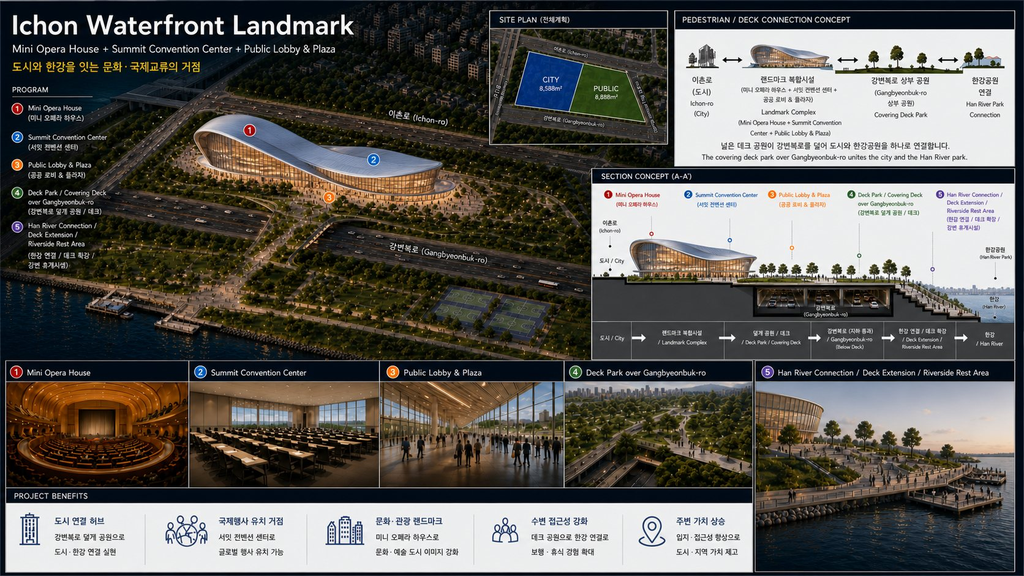

그림 6. 한강 연계 수변 공공복합공간의 장기 비전 참고 이미지

> 그림 6은 확정 조감도나 인허가 도면이 아니라, 대형 문화·회의시설과 강변북로 상부 데크까지 포함한 생성형 이미지 기반 장기 비전이다. 이미지 안의 CITY·PUBLIC 면적, 시설규모, 도로 상부구조, 한강 연결동선과 “주변 가치 상승” 등의 문구는 현재 zoning geometry 및 검증자료와 일치하지 않을 수 있으므로 정량 근거로 사용하지 않는다.

## 10.2 인허가 협의를 위한 공공성 검증표

인허가권자 설득자료에서는 “좋은 시설을 만들겠다”는 선언보다 현황의 결핍, 계획수단, 관계기관 검토사항, 측정 가능한 성과와 운영책임을 연결해야 한다. 다음 지표는 법정 심사기준이 아니라 Phase 2~3에서 대안을 비교하기 위한 후보 지표다.

```r
public_value_evaluation <- tibble::tribble(
  ~공공목표, ~계획가정, ~인허가_검토과제, ~후보_성과지표, ~근거수준,
  "연결 공공성", "부지 내부 공개보행축과 한강 방향 외부 보행망 접속거점", "경계 밖 토지·도로·교차부, 통행권원, 무장애 연속경로, 이행주체", "현황·계획 보행거리와 단절지점, 공개보행로 길이·유효폭·개방시간, 차량 충돌지점", "현장·설계 검증 필요",
  "지상 공공성", "주거·업무·공공블록을 잇는 보행 우선 지상공간", "교통·하역·소방, 야간안전, 출입구와 활성전면", "차량 비점유 지상공간, 공개보행통로, 보행·서비스차량 교차 횟수", "개념계획 가정",
  "환경 공공성", "보행축과 연결되는 녹지·그늘·휴게·물순환 공간", "토심·지하구조물, 기존수목, 투수·우수관리, 일조·바람", "지상 유효녹지·투수면적, 연속 그늘구간, 수관피복, 우수저류 성능", "현장·설계 검증 필요",
  "프로그램 공공성", "지역수요 기반의 소규모 문화·커뮤니티·공공편의 기능", "시설수요, 기존시설과 중복, 연중 운영, 소음·교통, 무장애 이용", "순수 공공이용 면적, 연간 개방일·시간, 무료·저비용 프로그램 비중, 예상 이용률", "수요·운영 검증 필요",
  "운영 공공성", "공공접근권과 장기 유지관리 책임을 계획에 포함", "토지·시설 귀속, 개방조건, 유지관리·보수 책임, 단계별 준공", "제한 없는 접근범위, 개방시간, 관리주체·예산 확정 여부", "관계기관 협의 필요"
)

kable(
  public_value_evaluation,
  format = "html",
  caption = "표 25. 인허가 협의용 공공가치 가설과 후보 성과지표",
  col.names = c(
    "공공목표", "계획 가정", "인허가 검토과제",
    "후보 성과지표", "근거수준"
  ),
  align = c("l", "l", "l", "l", "c")
) %>%
  kable_styling(
    bootstrap_options = c("striped", "hover", "condensed"),
    font_size = 12
  )
```

표 25. 인허가 협의용 공공가치 가설과 후보 성과지표

| 공공목표 | 계획 가정 | 인허가 검토과제 | 후보 성과지표 | 근거수준 |
| --- | --- | --- | --- | --- |
| 연결 공공성 | 부지 내부 공개보행축과 한강 방향 외부 보행망 접속거점 | 경계 밖 토지·도로·교차부, 통행권원, 무장애 연속경로, 이행주체 | 현황·계획 보행거리와 단절지점, 공개보행로 길이·유효폭·개방시간, 차량 충돌지점 | 현장·설계 검증 필요 |
| 지상 공공성 | 주거·업무·공공블록을 잇는 보행 우선 지상공간 | 교통·하역·소방, 야간안전, 출입구와 활성전면 | 차량 비점유 지상공간, 공개보행통로, 보행·서비스차량 교차 횟수 | 개념계획 가정 |
| 환경 공공성 | 보행축과 연결되는 녹지·그늘·휴게·물순환 공간 | 토심·지하구조물, 기존수목, 투수·우수관리, 일조·바람 | 지상 유효녹지·투수면적, 연속 그늘구간, 수관피복, 우수저류 성능 | 현장·설계 검증 필요 |
| 프로그램 공공성 | 지역수요 기반의 소규모 문화·커뮤니티·공공편의 기능 | 시설수요, 기존시설과 중복, 연중 운영, 소음·교통, 무장애 이용 | 순수 공공이용 면적, 연간 개방일·시간, 무료·저비용 프로그램 비중, 예상 이용률 | 수요·운영 검증 필요 |
| 운영 공공성 | 공공접근권과 장기 유지관리 책임을 계획에 포함 | 토지·시설 귀속, 개방조건, 유지관리·보수 책임, 단계별 준공 | 제한 없는 접근범위, 개방시간, 관리주체·예산 확정 여부 | 관계기관 협의 필요 |

Public Contribution polygon 전체가 공공기여로 인정된다고 가정하지 않는다. 시설별 **필요성·개발과의 관련성·법정 최소기준 대비 추가성·비거주자의 접근성·토지와 재원의 실행성·운영의 지속성·개발규모와의 비례성**을 검토하고, 귀속·개방·관리방식이 합의된 범위만 후속 단계에서 공공기여로 산정해야 한다.

## 10.3 통합개발 전체 기대효과

다음 효과는 구체계획, 공공기여 협의와 사업 실현을 전제로 한 **가능성**이다.

- 필지와 용도가 비효율적으로 분절된 토지이용을 통합적으로 조정할 가능성
- 노후 공동주택과 주변 생활환경을 함께 정비할 가능성
- 차량·주차 공간을 재배치하고 지상 보행·녹지환경을 개선할 가능성
- 부지 내 공개보행축과 한강·노들섬 방향 외부 보행망의 접속 가능성을 검토하고, 실제 접근성 개선 여부를 사업경계 밖 동선·권원·교차부와 관계기관 협의 후 평가할 가능성
- 기존 비주거 소유주·세입자의 재입점 선택지와 임시이전·영업대책을 마련하면서 분산된 업무·근린생활 기능을 재배치할 가능성
- 저층 활성가로, 공동 하역·주차와 공개보행통로를 통해 생활서비스와 보행환경을 함께 개선할 가능성
- 용산국제업무지구를 포함한 용산권 업무공급과의 보완·중복 여부를 평가해 적정 업무·상업 규모를 조정할 가능성

각 효과는 보행동선, 교통영향, 기반시설 수용력, 공공시설 수요, 한강변 경관과 사업경계를 별도로 검증해야 하며 현 단계에서 실현이 보장되지 않는다.

# 11 추진 Action Plan

```r
action_plan <- tibble::tribble(
  ~단계, ~핵심과업, ~현재단계의_산출물,
  "Phase 1", "토지주 및 인근 소유주 연구모임 구성", "주거 희망평형 조사, 비주거 소유주·세입자·업종·전유면적·대지권 현황, 보행·공공시설 기준선",
  "Phase 2", "도시계획·건축·정비사업 전문가 feasibility 검토", "O-1·O-2 배정대안 재산정, 업무·상업 수요와 공실·고용·교통 분석, 외부 연결구간 기술·권원 검토",
  "Phase 3", "용산구 및 서울시 관련부서 사전협의", "용도배분·저층 활성가로·공공기여 인정범위, 사업경계와 관계기관 협의가 필요한 외부사업 구분",
  "Phase 4", "개발구상 및 사업성 보완", "주거 평형배정, 상가 재입점·업무전환, 임시이전·영업대책, 기반시설·운영관리·사업구조 비교",
  "Phase 5", "토지등소유자 및 주민 공식 의견수렴", "주거·비주거 소유주의 종후자산 선택과 세입자·주민 수요를 반영한 후속 추진 여부"
)

kable(
  action_plan,
  format = "html",
  caption = "표 26. 통합개발 검토를 위한 단계별 Action Plan",
  col.names = c("단계", "핵심과업", "현재 단계의 산출물"),
  align = c("c", "l", "l")
) %>%
  kable_styling(bootstrap_options = c("striped", "hover", "condensed"))
```

표 26. 통합개발 검토를 위한 단계별 Action Plan

| 단계 | 핵심과업 | 현재 단계의 산출물 |
| --- | --- | --- |
| Phase 1 | 토지주 및 인근 소유주 연구모임 구성 | 주거 희망평형 조사, 비주거 소유주·세입자·업종·전유면적·대지권 현황, 보행·공공시설 기준선 |
| Phase 2 | 도시계획·건축·정비사업 전문가 feasibility 검토 | O-1·O-2 배정대안 재산정, 업무·상업 수요와 공실·고용·교통 분석, 외부 연결구간 기술·권원 검토 |
| Phase 3 | 용산구 및 서울시 관련부서 사전협의 | 용도배분·저층 활성가로·공공기여 인정범위, 사업경계와 관계기관 협의가 필요한 외부사업 구분 |
| Phase 4 | 개발구상 및 사업성 보완 | 주거 평형배정, 상가 재입점·업무전환, 임시이전·영업대책, 기반시설·운영관리·사업구조 비교 |
| Phase 5 | 토지등소유자 및 주민 공식 의견수렴 | 주거·비주거 소유주의 종후자산 선택과 세입자·주민 수요를 반영한 후속 추진 여부 |

현재는 Phase 1에 앞선 연구자료 정리 단계다. 조합설립, 정비구역 지정, 특별계획구역 지정 또는 사업시행이 확정된 상태가 아니며, 다음 단계로 넘어갈지는 각 단계의 검토 결과와 소유자·관계기관 의견에 따라 판단해야 한다.

# 12 데이터 출처 및 한계

- **건축물·토지 현황**: 서울시 열린데이터 건축물대장 표제부와 저장된 정리자료. 공부상 정보와 현황이 다를 수 있으며 원천데이터는 수정하지 않았다.
- **실거래가**: 기존에 저장된 국토교통부 실거래가 CSV. 한가람 59.5~60.2㎡ 월 중간값과 동월 대상단지 거래를 비교했으며, 거래 희소성과 물건 특성 차이를 통제하지 못한다.
- **O-1 가격 스냅샷**: 2026.8.16 네이버부동산의 주택형별 최근 3개월 평균 실거래를 우선하고, 없으면 현재 확인매물 최저 호가를 사용했다. 동일형 자료가 없을 때에는 인접 확인형 단가환산, 최근 3개월 밖 최종 거래 또는 2026.5.1 보관 호가를 명시적으로 사용했다. 810가구 중 A 최근 3개월 실거래 90가구, B 동일형 현재 호가 121가구, C 인접형 현재 호가 환산 463가구, D 과거·보관자료 131가구, E 가격 미확인 임시값 5가구다. 네이버 화면 표시 평균을 구성한 개별 거래건수·목록은 보존하지 못했다. 호가는 체결가가 아니고 층·향·수리·대지권·매물 중복을 통제하지 못하며, 인접형 선형환산은 면적차가 클수록 신뢰도가 낮다. 재현용 입력은 `data/naver_price_snapshot_20260816.csv`에 보존했다.
- **공간자료**: 별도 polygon zoning 좌표와 건축물 대표점. 면적은 EPSG:5179에서 `sf::st_area()`로 계산했다. 원본 polygon에는 기하 오류와 요청면적 불일치가 있어 핵심 블록을 목표 계획면적에 맞게 보정했으며, 보정 geometry는 지적측량·소유권 경계·확정 공공기여 경계가 아니다.
- **정책자료**: 국토교통부 2026.8.13 주택 신속공급 방안. 연구용역, 법안·시행령 개정 추진과 시행 중 조치가 섞여 있으며 이촌동 초입구역에 대한 직접 적용을 의미하지 않는다.
- **벤치마크**: 서울시 정비사업 정보몽땅의 상봉10재정비촉진구역 사업개요. 다른 입지와 제도의 사례이므로 개발규모의 직접 근거가 아니다.
- **시뮬레이션**: 공공기여율, 용적률, 주거배분비율과 세대당 평균 공급면적을 조합한 민감도 계산이다. 건축·교통·경관·환경·사업성·권리관계·분담금·분양성 검토를 대체하지 않는다.
- **가구당 배정 예시**: O-1은 변경 전 문서의 용적률 380%·1,220세대 평형 재고를 다시 사용하되, 현재 공부상 810세대의 가격 proxy와 한가람·코오롱·강촌 가치곡선 사이 전체 가치차 합을 최소화했다. 전용률 75%는 신축 공급면적 환산 가정일 뿐 현재주택 배정기준이 아니다. 가치 1순위와 최종평형이 다른 449가구와 같은 가치 proxy 내 계산용 순번은 개인별 우선권을 뜻하지 않는다. 부대찌개건물 5가구는 현 면적과 가격을 모두 확인하지 못해 면적합계와 기초가치에 별도 placeholder가 포함된다. 실제 종전자산평가·분양신청·관리처분계획상 배정표가 아니다.
- **업무·상업 O-2 예시**: 10,298㎡ 개념블록, 용적률 450%, 생활지원 35%p, 전용률 55%, 오피스텔 360실은 변경 전 구상을 현재 geometry에 맞춰 재계산한 입력값이다. 법정 상업지역 면적, 허용용도·용적률·높이 또는 공급계획이 아니며 업무 중심안 등 다른 용도대안과 비교해야 한다.
- **비주거·부속상가 재진입 예시**: 공부상 상가호수 164호와 건축물대장 대지면적을 사용하되, 혼합건물은 상가·주택 호수비례 대지 proxy, 대지면적 누락 건물은 20㎡ 임시 proxy, 후보 건물 최소 1실 규칙을 적용했다. 대지권·전유면적·소유자수·감정평가·영업가치·세입자 보상을 반영하지 않으므로 법적 권리배정표가 아니다.
- **업무·상업 참고 이미지**: 그림 5의 450%·35층·15층·비주거 35%p 표기는 역사적 O-2 가정이다. 현재 geometry나 확정 건축계획과 일치하는 정량 근거가 아니며 저층 활성가로와 상부 복합용도라는 공간 원칙만 참고한다.
- **수변 장기 비전 이미지**: 대형 문화·회의시설, 도로 상부 데크와 한강 연결을 표현한 생성형 이미지다. 이미지 속 면적·시설·효과 문구는 현재 geometry와 검증자료의 정량 근거가 아니며, 구조·교통·방재·수요·운영·외부기관 협의 전에는 기본계획으로 해석하지 않는다.

본 문서는 통합적인 토지이용 재편의 **검토 가능성**을 구조화한 예비자료다. 모든 수치는 별도 법률검토, 측량, 기본설계, 관계기관 협의와 토지등소유자 의견수렴을 거쳐 재검증해야 한다.

[^1]: 서울시 열린데이터(https://data.seoul.go.kr/)의 공공데이터 건축물대장 표제부를 대상 분석